# The Origins of Inequality, Revisited

The Luck Baseline, Two-Segment Distributions, and a Phase Transition You Can Calculate

*First published: 2026-10-26 | Last updated: 2026-10-29 21:35 EDT*

# Abstract

Rousseau split the sources of inequality into natural and artificial. This essay actually runs his thought experiment and finds a third source—luck. It then measures, one by one, how much the other mechanisms push inequality up or down, and closes by showing why the Gini coefficient alone is not enough.

- Chapter 1. Rousseau’s question, and the one cell the model can supply.
- Chapter 2. A fair island: everyone starts equal and plays by the same rules; how is wealth distributed after many years? First, two questions for the reader to guess.
- Chapter 3. The answer to the first question: where this shape comes from, and what remains when you swap out the parts.
- Chapter 4. The answer to the second question: how this baseline is calculated, and what it means in reality.
- Chapter 5. Pushed to the limit: with fluctuation added to returns, how bad can inequality get.
- Chapter 6. Other sources: ability, credit, inheritance, growth, taxes—which way each pushes inequality, and how far.
- Chapter 7. One number is not enough: the same degree of inequality can be mobile or fixed.
- Chapter 8. Conclusion: back to Rousseau, and a ledger with three columns.

*This essay was split off from “Fairness and Efficiency: The Same Temperature”: that one asks whether to sacrifice fairness for efficiency, this one asks where inequality comes from. Every figure and table is computed at knit time, and each result is registered with its provenance where it is calculated (the list is at the end). Longer derivations mostly sit in collapsible details; skipping them does not stop you from reading on.*

# 1 Starting from Rousseau’s Question

In 1754 the Academy of Dijon in France announced a prize essay competition on the question: “What is the origin of inequality among men, and is it authorized by natural law?” Rousseau submitted a manuscript four times the required length and lost—four years earlier he had taken first prize from the same academy with his *Discourse on the Sciences and Arts*. The losing manuscript was published in 1755 as the *Discourse on the Origin and Basis of Inequality Among Men*.

His answer comes in two steps.

Step one: split “inequality” in two.

- Natural inequality: age, strength, health, natural talent.
- Political (or moral) inequality: wealth, status, power, privilege—they “depend on convention” and are artificial.

Rousseau’s judgment: natural inequality is small and barely matters in the state of nature (with no accumulation, who is a little stronger hardly counts); the vast gaps we see come almost entirely from the second kind.

Step two: give the mechanism chain of artificial inequality. Metallurgy and agriculture → division of labor → private property → mutual dependence → comparison (he distinguishes *amour de soi*, self-preservation, from *amour-propre*, self-esteem/vanity, which arises only in society and is the engine of inequality) → gaps harden → law and government → despotism. The sharpest step is this: the establishment of law turned established usurpation into a permanent right. The sentence that opens the second part is the most famous in the book—the first person to fence in a plot of land, say “this is mine,” and find people simple-minded enough to believe him was the true founder of civil society.

(A common misreading, corrected in passing: Rousseau never used the phrase “noble savage,” and he did not advocate going back to the forest.)

One point is often overlooked but matters most here: Rousseau said explicitly that he was not writing history. He wanted to “set the facts aside” and reason from human nature to a possible path. In today’s terms, the *Discourse on Inequality* is a thought experiment, a model—only in his hands the model would not run.

Today it runs. And once it runs, an answer emerges that he could not have seen.

## 1.1 A Third Source, Two Centuries Later: Luck

Rousseau divided inequality into “natural” and “artificial,” and that binary hides a default premise: every share of inequality must have a cause—either a difference in endowment or a human arrangement.

Run his thought experiment for real, and a third thing appears:

> No difference in talent, no private property, no encloser, the rules identical for everyone in every detail, every transaction a fair coin toss—and the outcome still settles into a quite unequal distribution.

This inequality is neither natural nor artificial. It is the work of luck: who gains and who loses in each transaction is pure chance, and chance by itself settles into gaps.

Intuition balks here: luck runs both ways, so over the long run shouldn’t it cancel out? Only the mean cancels—the total is conserved, and everyone’s expected wealth is the average from beginning to end, not a penny more or less. But inequality measures not the mean but dispersion, and dispersion does not cancel. It churns wider and wider until it hits the one wall: wealth has a lower bound but no upper bound.

The wall is not at zero, and this is worth saying clearly up front so that it is not read later as a false claim. Plenty of people have negative net worth in reality—mortgages, student loans, credit cards; the rich owe the bank more. But how much you can borrow is limited: lending requires collateral or income, and bankruptcy can wipe a debt clean, so the downward end is stopped not far from zero, while the upward end has no ceiling. It is this asymmetry, not the specific location of zero, that really drags the distribution’s tail to the right. §6.1.2 will put credit into the model, let wealth really go negative, and see what happens once this wall loosens.

With this wall in place, what remains is combinatorial counting: among all possible divisions, the state “poor” has far more realizations than the state “rich” (§3.2 will count those divisions out for you one by one). Wherever the random churning lands, the probability is proportional to how many ways that bin can be realized—so it must settle on a right-skewed distribution, and once settled it does not come back.

So this inequality needs no one to do anything wrong, and it needs no cause.

This does not overturn Rousseau; it adds a **luck baseline** to his account.

He said natural inequality is small—modern data support this. What needs adding is the next step, the bookkeeping. Rousseau’s two steps run like this: cross out the natural share, put everything left under “artificial”; then chase down the artificial column to private property, to law nailing established fact into right. Each step is fine, but this is a ledger with only two cells—it leaves no place for “the part with no cause.”

The luck baseline adds exactly that cell, and it sits between the first step and the second: the artificial column must first subtract the sediment of pure luck, and only what remains is left for mechanisms to explain. Below the baseline, redistribution is at work; above it, positive feedback or heterogeneity in the rules is amplifying—and “the rules differ for different people” is precisely Rousseau’s encloser as he appears in the model. He is indeed in this column, but the column is not all his.

How large is this baseline, concretely? The next chapter will first ask you to guess, then reveal it.

# 2 An Island Cut Off from the World: Ten Thousand Coins, Many Years Later

A wealthy pirate happened to pass by an island cut off from the world.

The island was fertile, and a thousand islanders lived on it. There was no money and no hierarchy of any kind—no chief, no priest, no landlord; people stood entirely equal to one another. On a whim the pirate had a chest of gold coins carried down from his ship: ten for each islander, ten thousand in all. He told them the coins could be exchanged freely, then set sail and left.

Many years later he came back. The island was still that island:

- Still cut off from the world—not one coin had flowed in, and not one had flowed out;
- Still absolutely fair in procedure—no hierarchy had grown, there was no interest, no prices, no one was favored, and the rules applied to every islander word for word;
- The islanders did not die—no birth, aging, sickness, or death, and so no inheritance: no one passed coins to children; spouses neither pooled their purses nor gave to each other. Many years later, the ones holding coins were still the original thousand.
- Even the penniless kept trading—an islander with no coins at all would be paired again the next round. He simply had nothing to give that round, but a coin might arrive at any moment. On this island, going broke was not elimination, only temporary.
- To the islanders the coins were still just something pretty; who exchanged with whom, and how much, was pure whim.

The only thing that had changed was the distribution of the coins.

These lines are not rhetoric; they are the entire set of premises of the model:

| What the story says | The premise in the model | In mathematics |
| --- | --- | --- |
| Still cut off from the world | The total is conserved | Σ w = M, equal every round |
| Still absolutely fair in procedure | The rules are homogeneous and unbiased | for every pair (i, j): P(i gives j) = P(j gives i) = ½, regardless of who the two are or how much each holds |
| No credit on the island | There is a wall at 0 | w ≥ 0, for every person, every round |
| Even the penniless kept trading | That wall reflects | someone with w = 0 only receives this round and never pays, and P(0 → 1) > 0—0 is not an absorbing state |
| Islanders never die and pass nothing on | The coin-holders are always the original N | the participant set is fixed and N is constant; apart from exchange, nothing changes w |

The last premise looks like a shortcut, but it removes the entire family of inheritance and marriage mechanisms outright—not setting them to neutral but making them not exist at all. What it saves is a pile of assumptions that would otherwise have to be filled in (who pairs with whom, whether spouses pool their purses, who inherits, how much); what it buys is a harder conclusion: nothing seen from here on can be attributed to marriage, inheritance, or population structure. It also means the span “many years” needs no explanation—the same people have simply been exchanging coins all along. That is also why the later figure that follows the same islander for thirty thousand rounds is, literally, the same person.

In reality, of course, it is not like this, and loosening this premise is a family of knobs that can turn either way: partible inheritance equalizes, primogeniture concentrates, and assortative marriage (like marrying like) amplifies. This essay removes the whole family for now and puts it back in to be measured in §6.2.

The two middle items describe two things about the same wall, and both are needed: the wall exists (no credit, wealth cannot go negative), and the wall bounces (going broke is not elimination). Remember it in one sentence: 0 is a wall, not a pit.

Both matter, and missing either one yields a different model: taking the wall down (allowing borrowing, letting wealth go negative) is one thing, and Chapter 6 will let the data speak; turning the wall into a pit (bankruptcy means elimination) is another, which in mathematics is the gambler’s ruin problem—§4.3 will meet a close relative of it. Neither is in this chapter’s setup: on this island the wall is there, and it bounces.

One last definitional note that runs through the whole essay. The quantity this model tracks is how many coins each islander holds—a stock, that is, wealth. So every Gini coefficient in this essay, unless it explicitly says “income,” is a wealth Gini, not an income Gini. Mixing the two produces conclusions that are simply wrong. How far apart they are, and why, comes later in this chapter; actually computing it waits until §4.2.

In code the rule is a single sentence: each round, pair the thousand islanders at random two by two, and inside each pair pick one person at random to hand the other 1 coin.

## 2.1 Two Questions First

Answer them yourself before reading on. Almost everyone gets both wrong, and where they go wrong is the entire content of this essay.

Question one: after many years, tabulate the coins held by each of the 1000 islanders into a distribution. Which of the shapes below is it closest to? (Note that it counts per head, and people holding 0 coins are included.)

- A. A normal distribution with mean still 10 coins—the most common holding is still around 10, just more spread out than at the start.
- B. A lognormal distribution with mean still 10 coins—the most populated bin is below 10, with a tail dragging out to the right.
- C. An exponential distribution with mean still 10 coins—the most populated bin is the poorest, and after that each additional coin cuts the count by the same fixed proportion.
- D. A power-law distribution with mean still 10 coins—the most populated bin is again the poorest, but the tail is much heavier, and a very few people take most of the coins.

Question two: the Gini coefficient of the island’s coin stock is closest to which? (0 = perfectly equal, 1 = one person holds everything)

- A. ≈ 0—the same as at the start, almost no differentiation
- B. ≈ 0.25
- C. ≈ 0.5
- D. ≈ 0.75

**Think it over before you click: the answers, and the mechanism behind each of the four options**

The answer to question one is C: the exponential distribution.

$p(x) \propto e^{-x/\mu}$, mean $\mu = 10$. (Strictly speaking, coins are indivisible, so the exact answer is its discrete version, the geometric distribution $p_n\propto q^{\,n}$ with $q = 10/11$; but ten coins per person is already fine enough that the shape is an exponential—discreteness shows only in the second decimal place of the Gini coefficient.)

In plain language: the most populated bin is having nothing at all, and after that each extra coin cuts the count by about 9%. An island that is absolutely procedurally fair, cut off from the world, and does not even have prices grew, all by itself, a strikingly unequal distribution of wealth.

The four options are not thrown together at random; each is the correct answer under some real mechanism—just not this one:

- A (normal): this is the intuition that “random = fluctuating around the mean.” It holds for independent random errors—each person’s deviation is independent and unrelated to the others, so they pile into a bell shape around the mean. But transfers on this island are conserving: one person gains a coin and someone else necessarily loses one, so the deviations are hard-wired together; add that wealth has a lower bound and no upper bound, and the distribution can only drag a tail to the right. Conservation + a lower bound with no upper bound = exponential, not normal.
- B (lognormal): if wealth came from independent multiplicative growth—rising and falling by a percentage each period, unrelated across people, with neither conservation nor a floor—then $\ln W$ would be a random walk, and the central limit theorem gives a lognormal. This island’s total is conserved, so it is not that.
- C (exponential): correct. Each of the three premises does one job, and none can be dropped: conservation pins the mean (if someone gains, someone loses; the distribution cannot drift as a whole); 0 as a wall lets wealth unfold only to the right—a lower bound and no upper bound, so the distribution must be right-skewed; unbiasedness means there is no spring pulling deviators back to the middle (that would give a normal distribution), only a slight, identical drift toward 0—it comes from people with nothing being unable to pay (§3.1). Put the three together, and the only possibility left is the distribution that assumes nothing beyond a given mean and non-negativity—the exponential distribution. The intuition is shorter: there are far more ways to hold little money than to hold a lot (Chapter 3 will count that sentence out). And “none can be dropped” is literal—remove any one and the answer changes: remove conservation (there is growth) and the answer depends on how the increment is split (Chapter 6); remove the wall at 0 (there is credit) and a stationary state may not exist at all (§6.1.2); remove unbiasedness (the rules differ across people) and the exponential tail turns into a power-law tail at once—which is exactly option D.
- D (power law): if islanders’ saving habits differed from person to person, or coins could earn interest at a random rate while a floor existed (wages, transfers), this would be the answer. Both will be added to the model and tried later.

The answer to question two is also C: a Gini coefficient of about 0.52. The exact value is $11/21$; the remainder comes from coins being indivisible—Chapter 3 fixes the shape, Chapter 4 computes this number.

The answers are up there, but putting an answer on the page is not the same as seeing it happen.

The figure below is what the island looks like when run, and it answers a more important question at the same time: is this inequality “different people,” or “the same person at different times”?

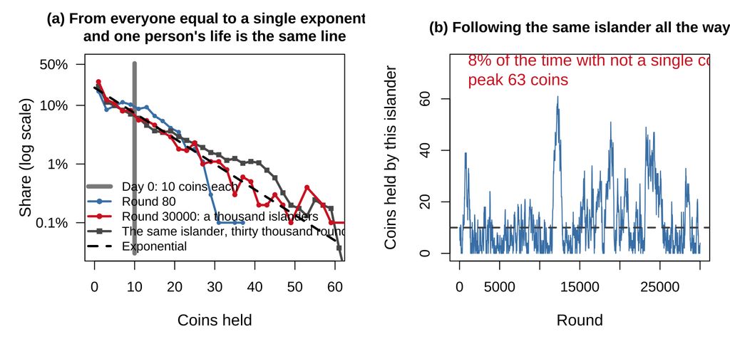

```r
## Island model: 1000 islanders each holding 10 coins; each round everyone is randomly paired two by two, and one member of each pair gives the other 1 coin
coin_game <- function(N = ISL_N, coins = ISL_C0, rounds = ISL_ROUNDS,
                      snaps = c(15, 80, ISL_ROUNDS), track = 1, seed = 4){
  set.seed(seed)
  w <- rep(coins, N); half <- N/2
  traj <- integer(rounds + 1); traj[1] <- w[track]; out <- list(`0` = w)
  for (r in 1:rounds){
    idx <- sample.int(N); i <- idx[1:half]; j <- idx[(half + 1):N]
    pay <- w[i] > 0                       # those with no coins do not pay this round
    w[i] <- w[i] - pay; w[j] <- w[j] + pay
    traj[r + 1] <- w[track]
    if (r %in% snaps) out[[as.character(r)]] <- w
  }
  list(snaps = out, traj = traj, w = w)
}
G <- coin_game()
ACC <- "#D62728"
brk <- seq(0, 400, by = 2)
dens <- function(v){ h <- hist(pmin(v, 400), breaks = brk, plot = FALSE)
                     list(x = h$mids, y = h$counts/sum(h$counts)) }

par(mfrow = c(1, 2), mar = c(4.6, 5.0, 3.2, 1.2), cex.lab = 1.12, cex.main = 1.05)

## (a) how egalitarianism collapses—and overlay "one person's life" while we are at it (ergodicity)
plot(NA, xlim = c(0, 60), ylim = c(3e-4, 0.55), log = "y", yaxt = "n",
     xlab = "Coins held", ylab = "Share (log scale)",
     main = "(a) From everyone equal to a single exponential\nand one person's life is the same line")
axis(2, at = c(0.5, 0.1, 0.01, 1e-3), labels = c("50%", "10%", "1%", "0.1%"), las = 1)
segments(10, 3e-4, 10, 0.52, lwd = 5, col = "gray55")                    # Day 0
d80 <- dens(G$snaps[["80"]]); ok <- d80$y > 0
lines(d80$x[ok], d80$y[ok], type = "o", pch = 16, cex = .7, lwd = 2.4, col = "steelblue")
dt <- dens(G$traj[301:length(G$traj)])            # time histogram for the same islander, dropping the first 300 warm-up rounds
lines(dt$x[dt$y > 0], dt$y[dt$y > 0], type = "o", pch = 15, cex = .8, lwd = 2.6, col = "gray35")
dp <- dens(G$w)                                    # cross-section at the final moment
lines(dp$x[dp$y > 0], dp$y[dp$y > 0], type = "o", pch = 16, cex = .8, lwd = 2.6, col = ACC)
curve(2*dexp(x, 1/10), add = TRUE, lty = 2, lwd = 2.6, col = "black")
legend("bottomleft",
       c("Day 0: 10 coins each", "Round 80", "Round 30000: a thousand islanders",
         "The same islander, thirty thousand rounds", "Exponential"),
       col = c("gray55", "steelblue", ACC, "gray35", "black"),
       lwd = c(5, 2.4, 2.6, 2.6, 2.6), lty = c(1, 1, 1, 1, 2),
       pch = c(NA, 16, 16, 15, NA), bty = "n", cex = 0.88)

## (b) one person's whole life
ii <- seq(1, length(G$traj), by = 20)
plot(ii, G$traj[ii], type = "l", col = "steelblue", lwd = 1.1,
     ylim = c(0, max(G$traj)*1.18),
     xlab = "Round", ylab = "Coins held by this islander",
     main = "(b) Following the same islander all the way")
abline(h = 10, lty = 2, lwd = 2, col = "gray30")
text(0, max(G$traj)*1.10,
     sprintf("%.0f%% of the time with not a single coin\npeak %d coins", 100*mean(G$traj == 0), max(G$traj)),
     col = ACC, cex = 1.15, pos = 4)
```

Left panel: absolute equality collapses within a few dozen rounds, and it collapses into a straight line. By round 80 the distribution is already visibly right-skewed and beginning to hug 0; at equilibrium it is a straight line on semi-log axes—an exponential distribution, and the black dashed line in the figure is exactly that. The most populated bin is the poorest one, 9% of the islanders have not a coin left, and the Gini = 0.523. A fourth line is overlaid on the same figure: histogram the wealth of any one islander over thirty thousand rounds (dark gray squares), and it falls on the same curve as the cross-section of a thousand islanders at the last moment (red). That is ergodicity—time average = ensemble average.

Right panel: so this is not “some people are born good at making money.” The line follows the same islander from beginning to end. He went broke (not a coin left for 8% of the time), and he was rich (peak 63 coins, 6 times the mean). The only difference between him and anyone else is the order in which luck arrived. The two panels together say one thing: that exponential curve is no “class structure”; it is the same person at different moments, laid flat and spread out. (This property is where the essay returns at the end: it means “inequality” here refers to the rises and falls of one person, not the fixed positions of different people. In real societies the two are mixed together, and the Gini cannot tell them apart.)

This machine is not an invention of economics. Physics has had an identical one for a long time, and it is the same equation: the Boltzmann–Gibbs law. Huge numbers of particles collide endlessly and exchange energy; the collisions favor no particle, the total energy is conserved, and energy cannot be negative—so in the steady state the probability of the system being in a state with energy $E$ is proportional to $e^{-E/T}$ (Boltzmann 1877). The cleanest physical example is the isothermal atmosphere: gravity treats every molecule alike and does not vary with height, and the ground blocks the molecules, so air density decays exponentially with height. Replace “energy” with “coins” and “particles” with “islanders,” and conservation, unbiasedness, and a lower bound all hold without exception; not one word of the formula changes. The place occupied by temperature in a gas is taken here by coins per capita. This is exactly the paper in which Drăgulescu and Yakovenko (2000) treated money as energy (Drăgulescu and Yakovenko 2000); §2.3 will give its background.

One last definitional note left over from the opening. The exponential distribution above gives this island’s wealth Gini; its income Gini is another matter, and not a fixed number at all—it depends on “how many rounds count as a year.” Where the two differ: §2.2 first sorts out the definitions, and §4.2 computes the numbers.

## 2.2 Three Measures, Three Numbers

From here to the end of this chapter, the facts and models on display belong to other people—first the shape of the real world, then where this machine comes from. What this essay does own is the decomposition, the comparison, and the trade-offs it makes with them, and those places will be flagged as they come.

We are about to put this island and real countries side by side. Before that, separate three things. Public discussion mixes them up nearly every day, and once they are mixed, every comparison collapses:

1. Different measures. The income Gini measures “how much you earn in a year”; the wealth Gini measures “how much you have put aside”—two different quantities. This island is the cleanest example: the same people, the same model, and the two measures give two completely different numbers. The income number is not even fixed: it changes with how many rounds count as a year. Shorten the window to a single transaction and it comes out comparable to the wealth Gini; stretch the window out and the law of large numbers flattens it (§4.2 will lay this out and compute it). The inequality of wealth here is not caused by income inequality at all. In the real world income Ginis mostly sit at 0.25–0.6 and wealth Ginis are generally above 0.7, which is the same thing. The trouble is that most people’s first association with “Gini coefficient” is income—media coverage, international comparisons, and policy debate almost always use the income measure, so “inequality” in public discussion is anchored by default to a number that is systematically too low. 0.4 sounds like a policy parameter that can be negotiated down; 0.85 is something else entirely. So when you see those two words, the first question to ask is: income, or wealth?
2. The same “wealth,” with the boundary still to be drawn. The wealth Gini is a much softer number than the income Gini: income is backed by annual tax filings and sample surveys, while wealth has to be valued item by item—real estate, unlisted equity, pension entitlements. The biggest boundary is pensions. Discount them and add them in (the literature calls this augmented wealth), and Switzerland’s wealth Gini falls from 0.75 to 0.55 (Kuhn 2020). Same country, same people, same year, and the two numbers differ by 0.20; the whole difference comes from the definition.
3. Different causes. Even when the numbers line up, it does not follow that it is the same society: the same Gini can come from “condensation at the top” or from “a large mass of zero or negative net worth at the bottom.” Chapter 5 will open this up with Sweden.

**Details on point 2: which pensions count in net wealth and which do not (skippable)**

The numbers above measure household net wealth (financial assets + real assets − liabilities), and the test is whether you can control it now and turn it into cash:

- Counted: account balances in your name that you can dispose of yourself—US 401(k)s, IRAs, and personal savings and investments of every kind. These are financial assets, to the last cent.
- Not counted: rights to future payments—**public pay-as-you-go** pensions such as US Social Security, Sweden’s inkomstpension, and Switzerland’s OASI, along with **occupational pensions** in most countries. They have no market price, cannot be sold, and cannot be passed on to children, so on the balance sheet they are zero, even though for an ordinary household they are often the largest single thing it counts on in a lifetime.

Note Switzerland’s second pillar: it is fully funded and has individual accounts, and it still does not count in net wealth—because it cannot be freely disposed of before retirement. So the criterion is not “funded or pay-as-you-go” but “can you touch it now.” The two percentages here are easy to read as splitting 0.20 into two parts, but the paper reports separate counterfactuals: add the statutory pension alone to net wealth, and the Gini falls from 0.75 to 0.57 (down 23%); add the occupational pension alone, and it falls to 0.65 (down 13%); add both (augmented wealth), and it is 0.55, a total drop of 26% (Kuhn 2020). The three comparisons are independent; 23% and 13% are not added together, and they do not add up to 26%. (These drops are computed from unrounded values in the paper; recomputing from the rounded Ginis above comes out about a percentage point off—so the two are registered separately and not derived from each other.)

One last thing, which also closes out the three layers above: this is not a mathematical toy. Measured on US tax and census data, the segment of the individual income distribution that holds the vast majority of the population really is exponential, and its Lorenz curve matches the data with no fitted parameters at all; and the Gini coefficient of an exponential is always $1/2$, so this empirical result puts the individual-income Gini at 0.5 (Drăgulescu and Yakovenko 2001a).

That curve is closed-form, so it can be redrawn on the spot—the left-hand panel below is exactly that:

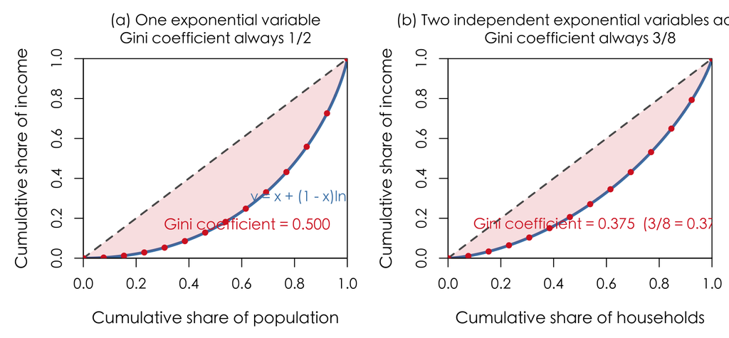

```r
## Reproducing the two Lorenz curves of Drăgulescu–Yakovenko (2001).
## Both are analytic, with no fitted parameters; the red dots are sampled from the corresponding distribution, to show that data land on the line.
ACC2 <- "#D62728"; BLU2 <- "steelblue"
lor_gini <- function(x, y) 1 - 2*sum((y[-1] + y[-length(y)])/2 * diff(x))   # trapezoid rule for the area

par(mfrow = c(1, 2), mar = c(4.6, 4.8, 3.4, 1.0), cex.lab = 1.12,
    cex.main = 1.04, family = "cjk")
nS <- 20000; pS <- (1:nS)/nS; iS <- round(seq(1, nS, length.out = 14))

## (a) Individual income: the solid line of Fig. 3 in that paper
xa <- seq(0, 1, length.out = 400); ya <- xa + (1 - xa)*log(1 - xa)
ya[1] <- 0; ya[length(ya)] <- 1
plot(xa, ya, type = "l", lwd = 3.2, col = BLU2, xlim = c(0, 1), ylim = c(0, 1),
     xaxs = "i", yaxs = "i", xlab = "Cumulative share of population", ylab = "Cumulative share of income",
     main = "(a) One exponential variable
Gini coefficient always 1/2")
polygon(c(xa, rev(xa)), c(xa, rev(ya)), col = adjustcolor(ACC2, .14), border = NA)
lines(c(0, 1), c(0, 1), lty = 2, lwd = 2, col = "gray35")
set.seed(1); u1 <- sort(rexp(nS)); L1 <- cumsum(u1)/sum(u1)
points(pS[iS], L1[iS], pch = 16, cex = 0.95, col = ACC2)
text(0.60, 0.30, "y = x + (1 - x)ln(1 - x)", col = BLU2, cex = 1.0, pos = 4)
text(0.62, 0.17, sprintf("Gini coefficient = %.3f", lor_gini(xa, ya)), col = ACC2, cex = 1.05)

## (b) Two-earner households: the solid line of Fig. 5 in that paper (parametric)
rr <- seq(0, 30, length.out = 2000)
xb <- 1 - (1 + rr)*exp(-rr); yb <- xb - rr^2*exp(-rr)/2
plot(xb, yb, type = "l", lwd = 3.2, col = BLU2, xlim = c(0, 1), ylim = c(0, 1),
     xaxs = "i", yaxs = "i", xlab = "Cumulative share of households", ylab = "Cumulative share of income",
     main = "(b) Two independent exponential variables added
Gini coefficient always 3/8")
polygon(c(xb, rev(xb)), c(xb, rev(yb)), col = adjustcolor(ACC2, .14), border = NA)
lines(c(0, 1), c(0, 1), lty = 2, lwd = 2, col = "gray35")
set.seed(2); u2 <- sort(rexp(nS) + rexp(nS)); L2 <- cumsum(u2)/sum(u2)
points(pS[iS], L2[iS], pch = 16, cex = 0.95, col = ACC2)
text(0.58, 0.17, sprintf("Gini coefficient = %.3f  (3/8 = %.3f)",
     lor_gini(xb, yb), 3/8), col = ACC2, cex = 1.02)
```

```r
stopifnot(abs(lor_gini(xa, ya) - 0.5) < 0.002, abs(lor_gini(xb, yb) - 3/8) < 0.002)
```

The right panel deserves a note of its own, because later in this essay we will run into the same number independently. The same paper also did two-earner households: each person’s income is exponential and independent of the other’s, and once added the Lorenz curve becomes the one in panel (b), with a Gini coefficient always $3/8 = 0.375$; the Census household data for 1947–1994 fall on that line (Drăgulescu and Yakovenko 2001a).

And §6.2, when it measures inheritance rules, will compute that the wealth Gini in the “couple pools, children split equally” case is also exactly $3/8$. That is no coincidence—both sides are the same mathematics: add two independent exponential variables (or take their mean; the Gini is scale-invariant, so the two are the same). There it is “two spouses pool their property, two children each take half”; here it is “two people in one household earn.” The settings are completely different, but the distribution that comes out of the addition is the same one.

This also gives the simulation an external check. The code in §6.2 carries an assertion: the Gini computed for the partible-inheritance case must land on $3/8$, or it stops with an error. Originally it was only there to catch a coding mistake—and now the same $3/8$ also holds on US household income data for 1947–1994. So the assertion is checking two things at once: whether the code computes correctly, and whether this model’s way of aggregating really matches reality.

But notice immediately that the measure has changed again here—it measures **individual income**, not the **household disposable income** usually reported in the news, and not wealth. So the same United States, three measures, three numbers:

Household disposable income Gini ≈ 0.4 | Individual income Gini ≈ 0.5 | Wealth Gini ≈ 0.83

All three numbers are correct, and the differences are not error—they are definition. That is why this essay uses a single measure throughout—wealth—and says so every time.

With the measure unified, the comparison now stands. Real-world wealth Ginis are generally above 0.7—the UK and France are about 0.70, Canada and Finland about 0.72, Norway 0.77, the US 0.83, and Sweden 0.87 (UBS 2023).

0.52 is lower than all of these—but how it is low is the point. This island has no differences in ability, no favoritism, no credit, no growth, no concentrated inheritance; the rules are identical for a thousand people down to the letter. Everything in reality that is thought to manufacture inequality is absent here, and it still arrives at 0.52. So this is not “fairly mild”; it is the baseline—the real world’s 0.70s and 0.83s are added on top of this line by other mechanisms. The rest of this essay performs that addition.

Three measures laid out, and the island’s place in the real world is fixed. What remains is another set of questions: who built this machine, what others have done with it, and why this essay still uses the Gini as its ruler—the next three sections.

## 2.3 Where This Machine Comes From, and What Economists Think

It is often treated as an example of “physicists overstepping,” but in fact economics, sociology, and physics each wrote it down independently, and the earliest version predates the physicists by nearly half a century.

The early sign in economics (1953). In the *Economic Journal*, Champernowne gave the first model that explained the income distribution as the **stationary state of a stochastic process**: income performs a bounded random walk on a logarithmic scale, and the stationary state is automatically Pareto (Champernowne 1953). What he set out to argue is exactly one of this essay’s claims—the shape of the distribution can be decided by the random dynamics itself, and need not come from the distribution of individual ability.

The independent discovery in sociology (1986). Angle proposed the “inequality process”: a purely random, pairwise surplus-transfer process whose stationary state falls on the Gamma family, with the shape parameter varying with the society’s level of technology (Angle 1986). This predates the physicists’ version by more than a decade, and he explicitly argued it as a theory of social stratification.

The physics version (from 2000). Drăgulescu and Yakovenko treated money as analogous to the energy conserved in atomic collisions: in a transaction money changes hands while the total stays fixed, just as in a collision energy is transferred while the total stays fixed, so money follows a Boltzmann–Gibbs distribution, and the “temperature” is money per capita (Drăgulescu and Yakovenko 2000)—that is the source of the physics analogy at the end of §2.1; Boltzmann–Gibbs is only the physics name for the exponential distribution $P(m)\propto e^{-m/\langle m\rangle}$ (Chapter 3 derives it three times); adding a saving rate gives Gamma (Chakraborti and Chakrabarti 2000); letting the saving rate differ across people turns the tail into a power law (Chatterjee et al. 2004); multiplicative random returns produce “wealth condensation” (Bouchaud and Mézard 2000). For a full review see (Yakovenko and Rosser 2009).

The economists’ objections must be recorded as they stand, and the essay’s answer recorded along with them. Gallegati, Keen, Lux, and Ormerod’s “Worrying Trends in Econophysics” lists four, two of which land directly here (Gallegati et al. 2006): first, ignorance of work economics had already done—Champernowne is the example; second, the premise that “money is strictly conserved” is too strong, since a real economy has credit and production, and money is not a conserved quantity. Both are right. But see where they land: they land on “is this an economic model at all?” This essay uses it only as a mechanism generator—turn off every cause you can think of and see how much inequality is left. For a baseline, having few assumptions is an advantage. As for the two premises themselves, Chapter 6 takes conservation apart and tests it, §6.1.2 also takes apart and tests three credit regimes, and even “0 is a wall” gets relaxed.

The “needs no cause” explanation has a precedent in statistics. Galton found that children of very tall parents are, on average, not as tall as their parents; this needs no force pulling people toward the middle—it follows necessarily as long as the correlation between the two generations is less than 1 (Galton 1886). Secrist later saw the same phenomenon in firm profits and concluded from it that competition would drive all firms toward mediocrity (Secrist 1933); Hotelling, in a book review, pointed out that this misreads regression to the mean: group firms by one year’s performance and each group naturally drifts toward the middle afterward, which does not show that the gaps between firms are shrinking (Hotelling 1933). This essay’s machine is the same kind of explanation; the difference is that it is about the shape of a cross-section, and the shape is decided jointly by conservation, a lower bound, and the exchange rule—change the rule and you change the shape (§3.4).

One sentence to pin down this model’s place: its value is not in predicting the economy but in separating out “which part of inequality needs no cause.” It is a baseline, not a theory.

A word on the road next door. Mainstream economics today explains it with random growth models: heterogeneous and persistent differences in returns to capital produce a skewed wealth distribution (a methods review (Gabaix 2009), evidence from the full Norwegian tax panel (Fagereng et al. 2020), and the better-known claim that the return on capital exceeds the growth rate over the long run (Piketty 2014)). It is the same thing as this essay’s later section on “increments shared in proportion to wealth, but with random returns,” in two languages.

## 2.4 Has Anyone Done This Before?

People have systematically reviewed “the origins of inequality,” along at least three independent lines, each starting from a discipline:

- On the economic-theory side: Benhabib and Bisin’s review sorts by mechanism, giving microfoundations one by one for every theory that can produce skewness and fat tails (random returns, inheritance, the life cycle, …), then mapping each to the evidence (Benhabib and Bisin 2018).
- On the historical-empirical side: Scheidel works the other way, sorting out what actually pushed inequality down, and concludes it was the four horsemen—mass mobilization war, revolution, state collapse, plague; the central claim is hard: only violent shocks have significantly pushed inequality down (Scheidel 2017).
- On the statistical-physics side: the branch described above. For a field review see (Yakovenko and Rosser 2009), for a monograph (Chakrabarti et al. 2013), and for a fresh survey of twenty-five years of models (Greenberg and Gao 2024).

These are all catalogues—Benhabib–Bisin sorts by mechanism and gives microfoundations one by one, Scheidel counts up the historical record, Greenberg–Gao arranges by model type. What catalogues share is this: each mechanism is studied in its own model, with different assumptions and different units, so magnitudes are not comparable; you cannot say “which is worse, ability differences or returns to capital.”

(Chakrabarti et al. 2013) is the monograph closest to this essay. It divides chapters by mechanism—goods, networks, debt, and taxes each get a section—and that arrangement alone comes closer to what this essay wants to do than most reviews. And it does apply the Gini to mechanisms: the chapter on exchange rules closes by comparing several rules by Gini; Figure 6.4 in Chapter 6 goes further and plots the Kuznets inverted-U of the Gini against the propensity to save—exactly “one ruler measuring one mechanism.”

But that is two mechanisms, not a single scale running through the book. The chapters that carry the mechanisms report results entirely by distribution shape and power-law tail exponent; the Gini mostly stays in Chapter 2, on data, doing definitions, Lorenz geometry, and cross-country comparisons. The two authors’ contemporaneous review (Chatterjee and Chakrabarti 2007) is more thorough still: throughout, models are compared only by shape and tail exponent, and the Gini never appears as a measure.

One quotation belongs here—the “needs no cause” line is not this essay’s invention; it opens that same review:

> *“Locally, of course, one can always find many ‘obvious reasons’ to explain the inequality of wealth or income; yet once one considers the globally robust structure of the income and wealth distributions across societies, these ‘reasons’ look very weak.”* (Chatterjee and Chakrabarti 2007)

This essay unpacks that sentence and measures it: how much does the baseline come to, and how much does each “cause” come to on its own. Chapter 6 puts all these mechanisms into one exchange model and reports each one with the same ruler.

## 2.5 Then Why the Gini?

To be fair, this must be said first: otherwise the “no common ruler” line above is taking an unfair advantage—reporting by shape and tail exponent carries more information than reporting by Gini. The Gini is a scalar functional of the Lorenz curve, many-to-one—different distributions can give the same Gini (Chapter 4 sets this out with two worlds, and Translating a Gini into a Distribution: A Conversion Table adds a table of “one Gini, four shapes”); whereas “which distribution family, what tail exponent” is nearly the distribution itself. That is not a coarser report; it is precisely a finer one.

So why does this essay fall back to a single number? Because the question is not “what does this mechanism turn the distribution into” but “which of these mechanisms is worse.” Shape cannot answer the second question: a uniform saving rate turns the exponential into a Gamma, heterogeneous saving turns it into a power law, a tax pushes it back down—three things living in three different parameter spaces, with no common scale and no way to rank them. To rank, you must project onto one axis, and projection always loses information. This is an explicit trade, not an improvement. The Gini is chosen because it has one advantage in that trade that other scalars lack: the baseline is analytic—the Gini of any exponential distribution is exactly $1/2$, independent of scale (computed in §4.1)—so “how many Gini points is a mechanism worth” is a displacement measured from an exactly known point, with no fitted parameter in it. (That advantage is not unique to the Gini, to be honest: the top 1% share and the log-variance of an exponential distribution are also closed-form, $p(1-\ln p)$ and $\pi^2/6$ respectively, and neither needs estimation. So the real reason for the Gini is not that it is mathematically cleaner, but that it is the most widely read, and it measures exactly the “overall dispersion” this essay cares about.)

The cost is paid, in two places. First, Chapter 7: one number is not enough, so a second axis is added. Second, wherever the tail matters, $\alpha$ is still reported—Chapter 5 simply solves the fixed point’s tail exponent analytically, and where that curve crosses 2 and 1 gives the two boundaries, with no detour through the Gini.

So the gap in the literature is not “they forgot to compute the Gini”; it is that no one had a reason to project every mechanism onto the same axis—because no one was ranking mechanisms. A catalogue needs no common scale; a ranking does.

And the framework itself is not new, and should not be called new. “Take the maximum-entropy solution as the benchmark and measure how far a mechanism pushes the distribution” is standard practice in this field—a recent kinetic model is explicitly written in that framework, its title saying “deviation from the maximum-entropy benchmark,” measuring how flat-rate exchange and liquidity constraints push the distribution away from the baseline (Liuh 2025). Such work usually handles only one or two mechanisms per paper. This essay did not invent the framework; it spreads it out all at once: one baseline, one engine, twenty-odd factors ranked on one axis (the master figure in §6.5). The benefit is that these numbers really can be compared; the cost must be stated too—they are all numbers from toy models, not estimates of reality.

Finally, one contrast left open, to revisit after Chapter 6: from the historical record Scheidel concludes that “peaceful redistribution has never significantly pushed inequality down”; this essay will reach a more troublesome version from the model: even the direction of redistribution is not given—it depends on whom the tax base covers and where the spending goes (§6.3.4). Two completely independent routes; see whether they point at the same thing.

Two sections remain in this chapter, and they are the most mathematical. We have been saying “the body is exponential, the top is a power law” without having laid the two segments out and looked at them; below we first draw each on the paper it belongs on, then answer a very concrete question: where does the seam between the two segments fall in money.

## 2.6 The Body Is Exponential, the Top Is a Power Law

Now back to option D of Question One, because that is what most people picture when they hear “wealth distribution.” Pareto saw the power law in wealth data more than a century ago, and the phrase “how much the richest 1% take” rests on it too. And this essay will spend two full chapters arguing that the basic distribution of wealth is exponential.

Both are right, because the real wealth and income distribution is two segments spliced together:

- The body (the great majority): exponential. This segment is decided by conservation + no bias + no debt, and it is what this essay derives.
- The top (the richest few percent): a power-law tail. This segment is decided by multiplicative growth plus a floor (the Kesten process of the $W_{t+1}=A_tW_t+B_t$ kind), and it is exactly the stretch Pareto saw in wealth data.

And this is not a theoretical possibility: both segments have been separated out from measurements, and what was measured was wealth. Drăgulescu and Yakovenko did such a split using the 1996 national distribution of personal net worth that the UK Inland Revenue reconstructed from inheritance-tax filings (Drăgulescu and Yakovenko 2001b):

- Below £100,000: exponential, with scale parameter $W_{\text{UK}} = 59.6$ thousand pounds. Note that this is the scale, not the mean net worth of this segment—the body is truncated at £100,000, so the conditional mean is well below the scale—the discussion of the seam later in this section works it out;
- Above £100,000: a power law, with tail exponent $\alpha = 1.9$.

With these two parameters the splice point falls at the 81st percentile: the bottom 81% of net worth belongs to the exponential segment, the top 19% to the power-law segment.

The two segments need two different kinds of paper to be visible: the body is a straight line on **semi-log** axes (slope $-1/W$), and the tail is a straight line only on **log-log** axes (slope $-\alpha$). Below we redraw both laws with the two parameters above, one paper on each side:

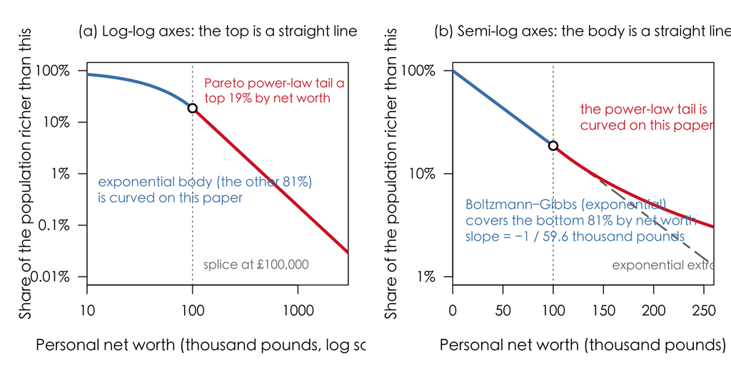

```r
## Redraw the two-segment 1996 UK net-worth fit reported by Drăgulescu–Yakovenko (2001):
## below £100,000, N(w) = exp(-w/W), W = 59.6 thousand pounds; above, N(w) = N(100)·(w/100)^(-alpha), alpha = 1.9.
## What this draws is the two **fitted laws**, not the paper's data points—the parameters come from the paper, the curves are generated from the analytic formulas.
ACC <- "#D62728"; BLU <- "steelblue"; GRY <- "gray45"
TW <- 59.6; WC <- 100; AL <- 1.9
NC <- exp(-WC/TW)                                  # cumulative population share at the splice point
## These three parameters are cited several times in the text, so register them in place—before, each place kept its own hand-copied version
reg("uk_scale", TW, "source", "§2.6 two_regimes",
    "D-Y 2001b: scale parameter of the UK lower exponential segment (thousand pounds) | 1996 | personal net worth")
reg("uk_cut",   WC, "source", "§2.6 two_regimes", "Same as above: the splice point of the two-segment fit (thousand pounds)")
reg("uk_alpha", AL, "source", "§2.6 two_regimes", "Same as above: tail exponent of the upper power law")
reg("uk_pU",    100*NC, "derived", "§2.6 two_regimes", "population percentage above the splice point = exp(-WC/TW)")
reg("uk_pctile",100*(1-NC), "derived", "§2.6 two_regimes", "which percentile the splice point falls at")
PL <- 100*(1 - NC); PH <- 100*NC                   # population share on each side of the splice point
Nw <- function(w) ifelse(w <= WC, exp(-w/TW), NC*(w/WC)^(-AL))
yat <- 10^(0:-4); ylb <- c("100%", "10%", "1%", "0.1%", "0.01%")

par(mfrow = c(1, 2), mar = c(4.6, 5.0, 3.6, 1.0), cex.lab = 1.08, cex.main = 1.0,
    family = "cjk")

## (a) Log-log: the high-net-worth segment is a straight line
wl <- exp(seq(log(10), log(3000), length.out = 1500))
plot(wl, Nw(wl), type = "n", log = "xy", ylim = c(1e-4, 1), xaxs = "i",
     xaxt = "n", yaxt = "n", xlab = "Personal net worth (thousand pounds, log scale)",
     ylab = "Share of the population richer than this", main = "(a) Log-log axes: the top is a straight line")
axis(1, at = c(10, 100, 1000), labels = c("10", "100", "1000"))
axis(2, at = yat, labels = ylb, las = 1)
lines(wl[wl >= WC], NC*(wl[wl >= WC]/WC)^(-AL), lwd = 3.4, col = ACC)
lines(wl[wl <= WC], exp(-wl[wl <= WC]/TW),      lwd = 3.4, col = BLU)
abline(v = WC, lty = 3, col = GRY)
points(WC, NC, pch = 21, bg = "white", col = "black", cex = 1.3, lwd = 2)
text(107, 0.34, sprintf("Pareto power-law tail α = 1.9\ntop %.0f%% by net worth", PH),
     col = ACC, pos = 4, cex = 0.86)
text(10.5, 0.004, sprintf("exponential body (the other %.0f%%)\nis curved on this paper", PL),
     col = BLU, pos = 4, cex = 0.92)
text(105, 1.6e-4, "splice at £100,000", col = GRY, pos = 4, cex = 0.86)

## (b) Semi-log: the low-net-worth segment is a straight line
ws <- seq(0, 260, length.out = 800)
plot(ws, exp(-ws/TW), type = "n", log = "y", ylim = c(1e-2, 1), xaxs = "i", yaxt = "n",
     xlab = "Personal net worth (thousand pounds)", ylab = "Share of the population richer than this",
     main = "(b) Semi-log axes: the body is a straight line")
axis(2, at = 10^(0:-2), labels = c("100%", "10%", "1%"), las = 1)
lines(ws, exp(-ws/TW), lty = 2, lwd = 2, col = GRY)          # exponential extrapolation, for reference
lines(ws[ws >= WC], Nw(ws[ws >= WC]),   lwd = 3.4, col = ACC)
lines(ws[ws <= WC], exp(-ws[ws <= WC]/TW), lwd = 3.4, col = BLU)
abline(v = WC, lty = 3, col = GRY)
points(WC, NC, pch = 21, bg = "white", col = "black", cex = 1.3, lwd = 2)
text(4, 0.030, sprintf("Boltzmann–Gibbs (exponential)\ncovers the bottom %.0f%% by net worth\nslope = −1 / 59.6 thousand pounds", PL),
     col = BLU, pos = 4, cex = 0.92)
text(118, 0.32, "the power-law tail is\ncurved on this paper", col = ACC, pos = 4, cex = 0.92)
text(150, 0.0125, "exponential extrapolation", col = GRY, pos = 4, cex = 0.86)
```

```r
## Self-check: the splice is continuous, and far out the power law must overtake the exponential extrapolation (the two laws are nearly tangent near the splice, so check beyond 200)
stopifnot(abs(Nw(WC) - exp(-WC/TW)) < 1e-12,
          all(Nw(seq(200, 3000, by = 1)) > exp(-seq(200, 3000, by = 1)/TW)))
```

This figure draws the two fitted laws themselves, not the paper’s data points—the original overlays the Inland Revenue’s measured points directly on the two lines. Only one thing matters: the same curve, on two kinds of paper, has a straight stretch on each.

One easily misunderstood point, while we are here: the splice point does not sit at a fixed place in the population. On the UK wealth data it falls at percentile 81, while on the US income figure below it does not arrive until around percentile 96. Ranked by wealth, the power-law segment starts much earlier—that is information in itself: in the same society, the “few” you see through wealth are several times broader than the “few” you see through income. So “body / tail” in this essay always refers to two mechanisms, not to a fixed percentage.

And a note jotted down in that same paper happens to be the main thread of this essay. The Gini coefficient of a pure exponential is always 0.50; the actual wealth Gini reported by the UK tax authority was 0.64 in 1984 and 0.68 in 1996 (Drăgulescu and Yakovenko 2001b). The dozen or so Gini points in between come mainly from the power-law tail at the top—that is exactly how the paper explains why the measured Lorenz curve deviates systematically from the pure exponential line. The rest of this essay does that: first make the 0.50 clear, then go find each of the additions one by one.

Now that both segments have parameters, this Gini can be taken apart—and what comes out is more interesting than the total.

**What Two-Segment Splicing Is Called in Statistics (Skippable)**

This “each minds its own segment” construction has a name: the **spliced distribution**, and its two-segment special case is the **composite distribution**—the version actuarial science studies most is the composite lognormal–Pareto, used to fit a large number of small claims together with a few enormous ones (Cooray and Ananda 2005; Scollnik 2007). In extreme-value theory the same construction is called **peaks-over-threshold**: a body distribution below the threshold, a generalized Pareto above it.

While we are at it, let us nail down a formulation that is easy to confuse: splicing is not “adding two distributions.” Adding is **mixing**, where each component spans the whole range and the two are weighted together; splicing gives each its own segment, with no overlap. The exact decomposition below depends precisely on that non-overlap—with a mixture, the identity would pick up a residual term.

The two segments do not overlap when ranked by wealth: everything below the splice point belongs to one, everything above to the other. In that case the Gini has an exact decomposition, with no residual—

$$G \;=\; p_L s_L G_L \;+\; p_U s_U G_U
\;+\; (p_L - s_L)$$

The first two terms are within-group: how unequal each segment is on its own. The third is between-group: how much more the top takes.

$p$ is the population share, $s$ the wealth share, and the subscripts $L$ and $U$ mark the body segment and the top segment. Note that the weights on the two within-group terms are $p \cdot s$, not the population share—a point whose importance will show up in a moment.

**Why the Cut Point Can Move with the Question (Skippable)**

The cut point is a choice, and this identity holds for any cut point. It is placed at £100,000 here because this section is arguing precisely that “two segments = two mechanisms,” and that is where the mechanism shifts gear. A different question should get a different cut point: §4.1 will give another natural one—the point that maximizes the between-group term, which falls at the percentile where wealth equals its mean and carries no fitted parameter. Same identity; the cut point encodes what you are asking.

```r
## Decompose the Gini of the two fitted laws above exactly. The two segments do not overlap when ranked by wealth, so the decomposition has no residual.
## The tail is pure Pareto, whose within-group Gini has the closed form 1/(2α−1); the body is exponential truncated at wc, integrated numerically.
sL_ <- (TW*(1 - NC*(1 + WC/TW)))                       # wealth held by the body (unnormalized)
sU_ <- AL*NC*WC/(AL - 1)                               # wealth held by the tail (converges only for α>1)
mu_ <- sL_ + sU_; sL <- sL_/mu_; sU <- sU_/mu_         # wealth share of each segment
pL <- 1 - NC; pU <- NC                                 # population share of each segment

gini_trunc_exp <- function(TT, hi, n = 2e5){           # Gini of the truncated exponential, by numerical integration
  x <- seq(0, hi, length.out = n); f <- dexp(x, 1/TT); f <- f/sum(f)
  cw <- cumsum(f); cx <- cumsum(f*x)/sum(f*x)
  1 - sum((cx[-1] + cx[-n])*diff(cw))
}
GL <- gini_trunc_exp(TW, WC); GU <- 1/(2*AL - 1)
Gwin <- pL*sL*GL + pU*sU*GU; Gbtw <- pL - sL; Gtot <- Gwin + Gbtw

## Check: draw from the spliced distribution directly and compute the Gini; it must match the decomposition
set.seed(7); u <- runif(4e5)
xs <- ifelse(u < pL, -TW*log(1 - u), WC*((1 - u)/NC)^(-1/AL))
stopifnot(abs(gini(xs) - Gtot) < 0.005)
## Conditional mean of the body segment: exponential truncated at WC, E[W|W<WC] = TW - WC/(exp(WC/TW)-1).
## The scale parameter TW equals the mean only when **untruncated**—the note on definitions in the text rests on this number.
uk_body_mean <- TW - WC/(exp(WC/TW) - 1)
stopifnot(uk_body_mean < TW)                     # truncation must push the conditional mean below the scale
reg("uk_body_mean", uk_body_mean, "analytic", "§2.6 gini_decomp",
    "conditional mean of the body (exponential truncated at £100k), in thousands of pounds; not the same quantity as the scale parameter 59.6")
reg("uk_decomp_between", Gbtw, "analytic", "§2.6 gini_decomp", "between-group term = top share minus population share")
reg("uk_decomp_within",  Gwin, "analytic", "§2.6 gini_decomp", "sum of the two within-group terms")
```

| Component | Population share p | Wealth share s | Within-segment Gini G | Contribution to total Gini, p·s·G |
| --- | --- | --- | --- | --- |
| Body (exponential segment, L) | 81.3% | 43.0% | 0.416 | 0.146 |
| Top (power-law segment, U) | 18.7% | 57.0% | 0.357 | 0.038 |
| Within-segment total | — | — | — | 0.184 |
| Between: extra taken by the top | — | — | — | 0.383 |
| Total | 100% | 100% | — | 0.567 |

The first two rows of the table are the six quantities in the formula: $p_L,p_U$ sit in the population-share column, $s_L,s_U$ in the wealth-share column, and $G_L,G_U$ in the within-segment Gini column; the last column is the part that actually enters the total Gini after the three are multiplied. “Within-segment total” is the sum of the last column of the first two rows; the “between” row is just $p_L-s_L$, the body row’s population share minus its wealth share (81.3% − 43.0%).

Of the three numbers, only the last matters. How unequal the tail is internally ($G_U = 0.36$) barely counts—its weight is only $p_U s_U = 0.11$, so it contributes just 0.04 once multiplied. The two within-segment terms add up to 0.18, while the between-group term alone is 0.38, accounting for 68% of the total.

In plain words: “how unequal the top is” does not matter; “how much the top takes” does. And the between-group term is literally that number—$p_L - s_L = s_U - p_U$, the share of wealth the tail takes beyond its share of heads: 57% minus 19%. One number, with no parameters to estimate, and interpretable.

(A note on definitions: this is the Gini of the two fitted laws, 0.57; the tax authority reports 0.68 for the raw data. They are not the same quantity—one is the integral of two ideal curves, the other a raw statistic with coverage gaps. Do not read the 0.11 difference as “some mechanism.”)

What the real data look like, you can see in the original figure. Below is the same procedure applied to US individual income—thirty-five years, 1983–2018, all tax records (Ludwig and Yakovenko 2022):

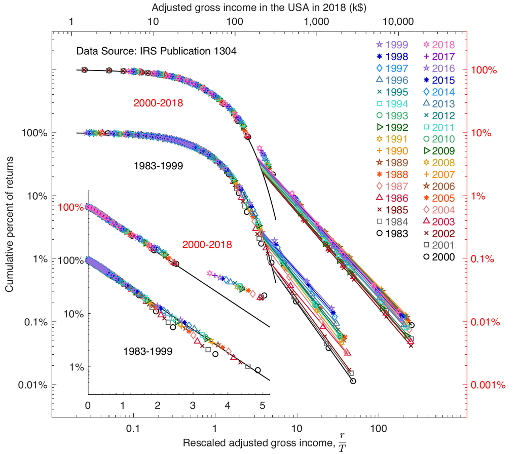

Cumulative distribution of US individual income, 1983–2018; data source IRS Publication 1304. The large panel is log-log (the power-law tail is a straight line here), the inset is semi-log (the exponential body is a straight line here); each year’s data are rescaled by that year’s scale parameter and overlaid. Image source: [Yakovenko (2023)](https://arxiv.org/abs/2307.02470), left column of Figure 2, [CC BY 4.0](https://creativecommons.org/licenses/by/4.0/); the figure originally appeared in [Ludwig and Yakovenko (2022)](https://doi.org/10.1098/rsta.2021.0162).

Note that this switches to an income measure—why it cannot be used to corroborate this essay’s wealth baseline is the subject of §4.4. But the shape is unambiguous: thirty-five years of points, each rescaled by its own year’s parameter, lie on the same curve; the semi-log line in the inset is the exponential body (about 96% of people in 2018), and the log-log line in the large panel is the power-law tail (about 4%). From this Yakovenko drew a hard conclusion: the data contain only two classes, and the middle class does not exist as a third segment—he also notes that the literature has never agreed on a definition of “middle class,” and everyone who writes about it brings their own (Yakovenko 2023).

Two entries in its empirical record have already appeared above—UK net worth in 1996 (Drăgulescu and Yakovenko 2001b) and US individual income 1983–2018 (Drăgulescu and Yakovenko 2001a; Ludwig and Yakovenko 2022), both with an exponential body. Here is a third, and the one that makes the case most clearly: the shape has since been pushed to 67 countries. Tao et al. redid it on a common footing and found that the exponential body is not an Anglo-American coincidence but a shape shared across countries—normalize each country’s income by its own scale parameter and, one country per line, every line is straight on a semi-log plot (Tao et al. 2019):

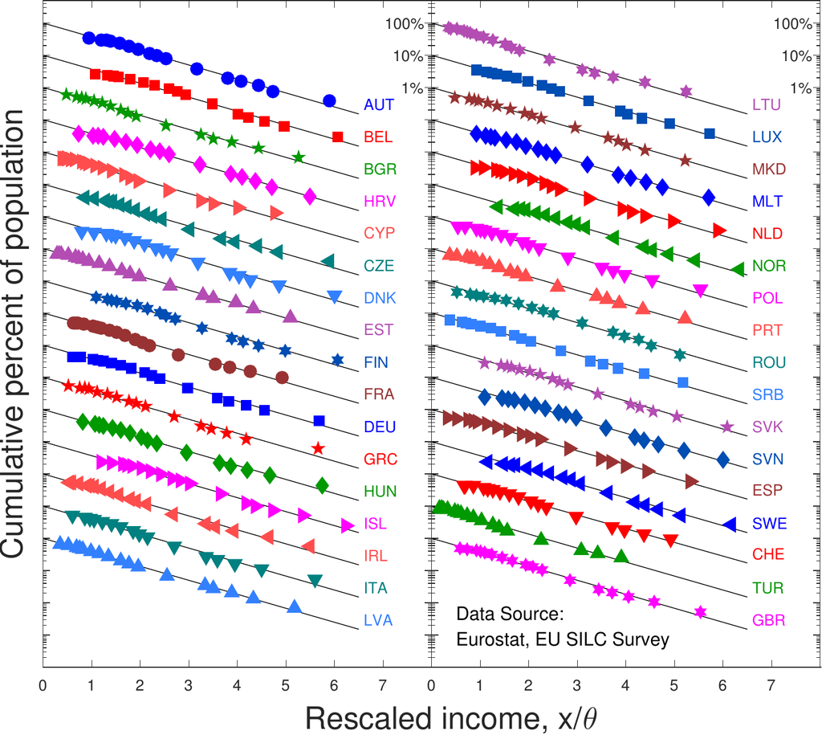

Cumulative income distributions for the EU and neighboring countries in 2014; data source Eurostat EU-SILC survey. Vertical axis logarithmic, horizontal axis linear; incomes are normalized by each country’s own scale parameter and the country curves are offset vertically for display; each is a straight line, i.e. an exponential distribution. Image source: [Yakovenko (2023)](https://arxiv.org/abs/2307.02470), left column of Figure 1, [CC BY 4.0](https://creativecommons.org/licenses/by/4.0/); the figure originally appeared in [Tao et al. (2019)](https://doi.org/10.1007/s11403-017-0211-6).

This figure deserves a pause, because it overturns a common reading: countries differ widely in income levels, tax systems, union density, and welfare institutions, yet the body segment has the same functional shape everywhere, exponential.

But the same shape does not mean the same degree of inequality—that step cannot be skipped. What Tao et al. actually fit is a **shifted exponential**: one location parameter more than the pure exponential, readable as an income floor. With that extra parameter, the Gini of this segment is no longer identically $1/2$ but varies with “how far the floor sits above the scale”—the paper itself discusses this ratio as something policy can turn, and on that basis recommends a moderate increase in unemployment benefits (Tao et al. 2019). So the correct statement is: institutional differences change these two parameters, not the functional shape of the segment.

**The Density and Gini of the Shifted Exponential, and What the Semi-Log Slope Actually Measures (Skippable)**

The density is $f(x)=\theta^{-1}e^{-(x-\mu)/\theta}\ (x\ge\mu)$: besides the scale $\theta$ there is a location parameter $\mu$. The slope of the straight line on a semi-log plot is $-1/\theta$, the negative reciprocal of the scale; only when $\mu=0$ does it equal the negative reciprocal of the mean (in general the mean is $\mu+\theta$). Its Gini is

$$G \;=\;
\frac{1}{2\,(1+\mu/\theta)}$$

Only $\mu=0$ returns $1/2$.

The clean corollary below holds only for the pure exponential ($\mu=0$), and it deserves a paragraph of its own because this essay’s baseline is exactly that special case: the Gini of a pure exponential is independent of scale and always $1/2$ (§4.1 will compute it). So under the $\mu=0$ approximation, cross-country differences in measured income Gini fall entirely on the top segment. Silva and Yakovenko wrote this relation as a formula and checked it against US tax data—$G=(1+f)/2$, where $f$ is the share of total income flowing into the Pareto tail (Silva and Yakovenko 2005). At $f=0$ the Gini is exactly 0.5.

$f$ actually has two definitions; the difference is small but they are not identical. In every later reference to this formula, $f$ means $f_L$.

**How the Two $f$ Differ, and Why We Take $f_L$ (Skippable)**

Use the wrong one and the Gini is off by 0.06. The paper says the two definitions broadly agree but are not identical; Ludwig and Yakovenko later gave them separate notation (Ludwig and Yakovenko 2022): $f_r$ is the actual income share above the splice point, $f_L$ the extra share relative to extrapolating the exponential segment to infinity. Their equation 3.7 uses $f_L$.

For the US in 2018, for example, $f_r=0.3378$ gives $G=0.6689$, $f_L=0.2172$ gives $G=0.6086$, while the measured value that year is $0.6018$—only $f_L$ matches.

But the formula has one mismatch, and the direction of the mismatch is worth recording. It fits the IRS data of the 1990s well, yet misses the 1980s—in those years the measured US individual income Gini was below 0.5. The original authors say so themselves: “$G$ was below $1/2$ in the 1980s, and our formula cannot capture that” (Silva and Yakovenko 2005; Chakrabarti et al. 2013). And $G=(1+f)/2$ is $\ge 0.5$ by construction, whatever value $f$ takes. So 0.5 is not a floor in the measured sense: the body of a real distribution can be more equal than the exponential, and then the whole curve drops below the baseline. That this essay treats 0.5 as a baseline rather than a lower bound is partly for this empirical reason.

Which tax regime those years fell under is worth noting in passing—but note only the timing, not causation. In the same year-by-year parameters, the years with a measured Gini below 0.5 are exactly 1983–1986, with the first crossing in 1987 (0.497 → 0.516); and the top US marginal tax rate came down in several steps right around then.

**The US Top Marginal Tax Rate in Those Years, Year by Year (Skippable)**

1965–1980 it was 70%, in 1981 69.125%, in 1982 down to 50%, in 1987 38.5%, and in 1988 28% (Wilson 2002).

One more point that is easily missed: from 1972 to 1981 earned income was subject to a separate 50% cap, so that 70% fell mainly on unearned income.

This essay reports only the timing coincidence here, not causation. How much of that jump was a real change in distribution and how much was reporting behavior following the tax rate is laid out in §6.1.3—and there it will be clear that the reading “high tax rates held inequality down” does not survive the arithmetic above.

This formula is in fact a limit of the exact decomposition above: it assumes the top is only a small handful. It works on US income but not on UK wealth—another case of “two measures cannot corroborate each other.”

**Why $G=(1+f)/2$ Is the Limit of the Exact Decomposition, and How Far It Misses on Wealth (Skippable)**

Above we split the Gini into “within + between.” As the top’s population share $p_U\to 0$, the between term tends to $f$ and the within term to $\tfrac12(1-f)$; together they are exactly $(1+f)/2$. So the formula assumes the top is a small handful.

On US income data the top is about 4%, so the approximation holds; on UK wealth data the top is 18.7%, and plugging in $f=$ 57% gives 0.78, while the exact decomposition gives 0.57—higher by 0.22.

(The same authors also translated this argument from statistical physics into the language of economics—rederiving it with Arrow–Debreu general equilibrium plus a Rawlsian free-competition fairness condition (Tao et al. 2019).)

## 2.7 Where the Seam Falls in Money

Go back to the two-segment US income figure from the last section—its structure has appeared once before in physics, in exactly the same form. Blackbody radiation at the end of the 19th century looked the same way: the long-wavelength end was fitted beautifully by the Rayleigh–Jeans law, the short-wavelength end by Wien’s law, and each law was exact on its own half and collapsed completely once it crossed to the other half—one body of data, needing two sheets of paper and two laws to describe. That figure has the same structure: each segment is straight on its own, the vertical axis spans four orders of magnitude, and you have to change paper to see the other segment.

And the analogy can go one step further: physics eventually stitched the two segments into a single law (Planck), and someone here has done the same thing—Ludwig and Yakovenko write “additive and multiplicative processes running at the same time” as one Fokker–Planck equation, whose steady-state solution degenerates to an exponential at the low end and a power law at the high end, with a natural transition in between (Ludwig and Yakovenko 2022).

But the analogy has to bend here, and that bend is the half that matters. Planck’s unification is two limits of one mechanism: one and the same radiation field, long waves and short waves alike, and once it is written as a single law the “two laws” no longer exist. Not here. The low and high ends come from two processes of different character running at the same time: the additive part is wages (work more this month, and income is a sum added), the multiplicative part is capital (the principal gains 3%, and income is multiplied by a factor). So the interpolating formula does not dissolve the two classes; it does the opposite—it explains why there are exactly two segments, and where the seam should fall: at the point where the two contributions are equal. Yakovenko simply follows the physics naming, calling the lower class thermal and the upper class superthermal.

**What that interpolating formula looks like, why it is not a Gamma, and why Chapter 5 does not take that route (you can skip this)**

It uses only three parameters—the mean income of the lower segment $T$, the tail exponent $\alpha$ (set by the ratio of drift to diffusion on the multiplicative side; §5.3 will use this point), and the splice point between the two segments $r_0$:

$$P(r)\;\propto\;\frac{e^{-(r_0/T)\arctan(r/r_0)}}{\bigl[1+(r/r_0)^2\bigr]^{(1+\alpha)/2}}$$

And this formula was written down back in 1895 by Karl Pearson—the Pearson Type IV distribution, published in the same journal (Pearson 1895).

Why not the more familiar Gamma? Because the Gamma’s tail is still exponential: on log-log paper it keeps steepening, it curves, while the stretch of data above is straight. The more damaging reason is in Chapter 5.

One more note, so the wires do not cross later. Chapter 5 does not take this equation. It removes the additive part entirely, keeps only multiplicative returns plus merge-and-split, and asks whether a power-law tail can grow on its own—it can, and the tail exponent can be solved analytically. The relation between the two routes is spelled out in the table in §4.3: Kesten’s “add a floor term” is a sufficient mechanism for growing a power-law tail, not a necessary one.

So where does this seam fall in money? There is an exact number, but first we have to say which kind of money. The next two lines do not measure the same quantity: the US line measures income (adjusted gross income on the IRS tax-return basis), the UK line measures wealth (net worth). Mixing them yields a completely wrong conclusion, and that is exactly the accounting discipline this chapter set out at its opening.

For US income, in 2018 the seam falls at 185,202 dollars. That number is not read off a figure—Ludwig and Yakovenko published their year-by-year fitted parameters alongside the paper, and the table below gives the 1983 and 2018 rows (Ludwig and Yakovenko 2022):

| Quantity (nominal dollars that year) | 1983 | 2018 |
| --- | --- | --- |
| Median income | 15,046 | 40,712 |
| Mean income of the lower segment T | 20,593 | 57,453 |
| Overall mean income | 20,661 | 78,027 |
| Two-segment splice point r* | 103,673 | 185,202 |
| Splice ÷ T | 5.03× | 3.22× |
| Splice ÷ median income | 6.89× | 4.55× |
| Upper-segment population share | 0.68% | 4.08% |

A few readings you can place directly. In 2018 the line sits around 18.5 × 10,000 dollars—someone with an annual income of 100,000 dollars is at percentile 82, still firmly inside the exponential segment, nearly a factor of two short of the seam; to cross it you would have to earn 4.5 times median income. In 1983 the line was 103,673 dollars, 6.9 times that year’s median income.

The threshold has come down in relative terms over these forty years—the splice point fell from 5.03 times the lower-segment mean to 3.22 times, with a steep drop around 1986 that coincided with the Reagan administration’s Tax Reform Act of 1986 (Ludwig and Yakovenko 2022). But this is not “the upper class letting people in.” As the threshold fell, the upper-segment population share rose from 0.68% to 4.08%—the exponential segment is shrinking and the power-law segment is expanding. No one climbed up; the territory of that law expanded.

The table also carries a more direct statement, in those two middle rows. In 1983, overall mean income (20,661 dollars) and the lower-segment mean $T$ (20,593 dollars) were nearly equal—the whole distribution was essentially one exponential, and a single “average income” stood for most people. By 2018 the two had split into 78,027 and 57,453 dollars, while the median was only 40,712. “Average wage” looks less and less like most people’s income, and the whole gap lives in that power-law tail.

A note on the measure. The IRS unit of observation is a tax return, not a person; in 2018 about a third were joint returns filed by married couples, so “individual income” is an approximation—the paper says so explicitly (Ludwig and Yakovenko 2022).

For UK wealth, in 1996 the seam falls at 10 × £10,000—the scale parameter of that year’s lower exponential segment was 5.96 × £10,000 (the conditional mean is only 36.6 thousand pounds, because the body is truncated at 10 × £10,000), so the splice point is 1.68 times the scale, at percentile 81 (Drăgulescu and Yakovenko 2001b). Measured on a different basis, the seam sits far away: the income seam is not reached until percentile 96, while the wealth seam arrives by percentile 81.

**How the multiples and percentiles convert, and one cross-validation (you can skip this)**

Because the lower segment is exponential, the two join directly: at a splice point $k$ times out, a fraction $e^{-k}$ of people remain above it. For the US in 2018 $k=3.22$, which gives 3.98%, while the paper’s independently counted upper-segment population share is 4.08%—one from fitted parameters, one from counting heads, landing in the same place.

So back to the question itself: this is not the boundary between “the middle class and the bourgeoisie.” In the US income figure from the last section, the middle class does not exist as a third segment—it is entirely submerged in the exponential segment. The real boundary is the boundary between additive and multiplicative, that is, between “income mainly from labor” and “income mainly from capital.”

Here a popular metaphor suddenly becomes exact. Robert Kiyosaki’s *Rich Dad Poor Dad* rests its whole book on one sentence: the poor dad works for money, the rich dad makes money work for him. In the equation above that sentence is not a figure of speech; it is literally those two terms: working for money is the additive term, making money work is the multiplicative term. And the metaphor is most exact precisely in saying “two dads” rather than “one ladder”—the common picture is rich and poor standing at different heights on the same ladder, while the data describe two systems of equations: relative inequality in the lower segment barely moves for thirty-six years and is always exponential, the upper segment follows another law, and every historical movement of the Gini coefficient comes from the upper segment’s share (the $G=(1+f)/2$ of §2.6) (Ludwig and Yakovenko 2022).

But the half this book has no standing to claim must be stated too. The data support “there are two dynamics”; they do not support “everyone can cut from one to the other”—in 2018 the multiplicative side held only 4.1% of the people. What this essay claims is only that structural judgment; no investment advice is included. And if you really turned the multiplicative-return knob until everyone had it, what would happen? That is exactly Chapter 5’s question, and the answer is not that everyone gets rich.

Then “how do I get from this segment to that one”? This essay cannot answer it. To answer it you would have to fit the model with the step that turns wages into capital, and that part is exactly what Chapter 5 deliberately refuses. What is missing, and what shape the answer would take, is folded away below.

**“How to cross over”: what is missing is a channel of accumulation, and which number the criterion actually hinges on (you can skip this)**

First separate two quantities that are easy to confuse. The $r^*$ reported above is where the two fitted segments cross; the Fokker–Planck equation has another, $r_0=\sqrt{B_0/b}$, the point where additive and multiplicative contributions to the fluctuations are equal (diffusion coefficient $B(r)=B_0+br^2$). The paper lists the two separately (Ludwig and Yakovenko 2022): in 2018, $r^*$ is 185,202 dollars and $r_0$ is 167,094 dollars, a difference of about 11%. The mechanism criterion below refers to $r_0$, not $r^*$. So the criterion is not “capital income exceeds wage income” but that the rises and falls of your income are decided mainly by asset prices and no longer by wages—a much higher threshold than the former.

What is really missing is a channel of accumulation. The two-segment structure above is a **cross-sectional** decomposition: it says who is on which side at this moment, and not a word about who will move; the model in Chapter 5 is **homogeneous**—everyone has the same $\sigma$, “being in the tail” is purely current luck, and there is nothing in it that you can do. To ask “how to cross” you must fit the model with the step that turns wages into capital, that is, a multiplicative recursion with an exogenous floor such as $K_{t+1}=A_tK_t+sw$. And that exogenous term is exactly what Chapter 5 deliberately refuses—what it wants to prove there is that “a power-law tail can grow without adding anything,” whereas what we ask here is precisely how that added term pushes people across. The same part, wanted for opposite reasons in the two chapters.

What shape the answer would take, though, can be said in advance. The properties of this kind of recursion settle it: when the expected log return is negative a stationary distribution exists, crossing over is possible and falling back is too—it is a recurring event, not a one-way door, and all you can compute is “the probability of being on the other side in the stationary state” and “how long one stays there on average”; when the expected log return is positive everyone crosses eventually, but that is exactly the regime in which Chapter 5 proves the population level starts to collapse. So this question will not have an answer of the form “do X and you arrive.”

As for actually installing it, that would bring in two parameters with no calibration basis—a saving rate and a volatility of returns—while this essay stands on a zero-fitted-parameter baseline; and “crossing probability” is in essence a quantity of opportunity, which belongs on the fairness side. So this step is left to the companion essay, *Fairness and Efficiency: The Same Temperature*: it already has positional stickiness as an axis, the control experiments with “persistent labels,” and it has already argued on the spot that the missing piece requires fitting wages into the model first.

So the question “what distribution is the wealth distribution” depends on which segment you are looking at, and each segment is governed by its own set of mechanisms. This essay walks both: first, two chapters establish why the body segment is exponential; then Chapter 5 opens the door to the other segment—add fluctuating multiplicative returns to the model, that is, bring “multiplicative” in, and the exponential tail turns into a power-law tail at once; and that chapter does not stop at a shape, it solves directly for the exponent of this tail, $\alpha_2(\sigma)$. (There is an earlier rehearsal: §3.4 makes the propensity to save differ across people, and the same exchange model grows a power-law tail too.)

But here is a question that ought to be asked, and it is the most important one for the whole model. This island has no wages—no production, no one earns, coins merely change hands. Yet in the real world the great majority of the body segment live on wages. How can a model without wages get the wealth shape of a world with wages right?

The answer lies in the constraints of the maximum-entropy step, and it is much broader than “conservation.” §3.3 writes out three constraints: the distribution normalizes, the mean is pinned, and wealth cannot be negative. “Total conservation” is not one of them—conservation is only one way of pinning the mean, the one this island uses.

In reality it is pinned by a different device: the long-run balance of income and expenditure. A person’s wealth is the **cumulative residual** of “income minus spending” over time. However high the wage, as long as spending broadly offsets it over the long run, this residual has no systematic drift; and the residual is bounded below (the asymmetry of §1.1). So the three maximum-entropy constraints are all in place: the mean is pinned, there is a lower bound, and nothing more is assumed—the only remaining possibility is exponential. The absolute size of wages sets the scale (the per-capita wealth of that segment), not the shape: a society with high wages and high spending and one with low wages and low spending can have exactly the same shape in the body segment.

**One qualification: what pins the mean is not “no drift” but income and expenditure balancing at the level of the population (you can skip this)**

“No drift” by itself cannot pin the mean. What pins it is the balance of income and expenditure at the population level: if an individual’s wealth had only zero drift plus a wall, its dispersion would grow forever and would not settle into any distribution. On the island the machine relies on total conservation; in reality it is total income offsetting total expenditure—both pin the mean at the level of the group.

Pinning the mean, written as an equation, is $\int_0^\infty x\,p(x)\,\mathrm{d}x=\mu$; §3.3 will set out all three constraints together and solve them.

So “the body is exponential” is, empirically, equivalent to a statement about saving: for that 96% of the population, cumulative saving is a small residual with no “compounding on wealth” component. Conversely, once the residual becomes a proportional increase on wealth, the shape switches at once to lognormal or power law—that is the top, the multiplicative term just described. So the two-segment structure is not two worlds but two sides of one sentence: whether the residual compounds.

This also gives the claim above a testable form, and the evidence is already in the earlier figure. The body of the US income distribution has hugged the exponential for thirty-five years—that fact is itself the observation that “for the great majority, the accumulation of wealth has no compounding component,” and there is no need to go and look up saving rates separately.

But this answer covers only the wealth side, and that must be said clearly. The model cannot deliver “annual income”: “income” on the island is just coins that others pass over, and its Gini is a function of the accounting window (§4.2 measures it; §7.2 lists this as one of the essay’s model boundaries). Only one output can be matched directly against data: the shape of the wealth distribution.

One reading reminder: the next time you meet “the wealth distribution is an X distribution,” first ask whether it means the body or the tail. Without that distinction, two people who are both right will still end up arguing.

# 3 Question One: Why an Exponential Distribution?

There are three independent routes to answering this question, and we start with the shortest: three lines of detailed balance (no entropy, no calculus), counting microstates (exact for a finite population), and maximum entropy (the most abstract, but general enough that swapping the constraints yields the normal and the power law). All three give the same answer—which is itself evidence of how solid the conclusion is.

First, pin down the relation between the two names, so we do not keep jumping back and forth later: coins are indivisible, so the exact answer is the geometric distribution $p_n=(1-q)q^{\,n}$; grind the coins finer and take the continuous limit, and it becomes the exponential distribution $p(x)=\frac1\mu e^{-x/\mu}$. The first two routes give the geometric distribution directly; the third (maximum entropy) works on the continuous version and gives the exponential. Discrete and continuous versions of the same thing, differing only in how fine the coins are—how many Gini points that fineness is worth gets computed exactly in the collapsible at the end of Chapter 4.

With the three routes done, we take the model apart: swap a part and see whether it holds. And when the last part comes out, a power-law tail drops out—the final section of this chapter explains why it must be a power law, using the same three machines and changing only the coordinates.

## 3.1 Three Lines Are Enough: Detailed Balance

Watch the number of coins $n$ in one islander’s hand; it performs a one-dimensional random walk on $0,1,2,\dots$. The premise that the rules are homogeneous delivers the key sentence directly: the rates of stepping up and stepping down do not depend on how many coins he already holds.

- In every round he is matched into some pair, and the probability that he is the payer is $1/2$ ⟹ down rate $=\tfrac12$;
- To receive a coin, the other party must be the payer and must not be empty-handed ⟹ up rate $=\tfrac12(1-p_0)$, where $p_0$ is the share of islanders with nothing.

In the stationary state the net flow between adjacent states must be zero (**detailed balance**):

$$p_n\cdot\tfrac12(1-p_0) \;=\;
p_{n+1}\cdot\tfrac12
\qquad\Longrightarrow\qquad
\frac{p_{n+1}}{p_n} \;=\; 1-p_0 \;\equiv\; q$$

The ratio does not depend on $n$. That sentence is the whole answer: stepping up one state from any state multiplies the count by the same constant $q$.

There is a physical picture behind this ratio. The down rate exceeds the up rate by $\tfrac12 p_0$, and that excess is the same for everyone, independent of how many coins one holds—like a gravity that does not vary with height, pressing everyone toward 0, where the wall at 0 stops them. Gravity plus the ground gives exactly the exponential decay of air density with altitude ([isothermal atmosphere](https://nyuhuyang.github.io/notes/exp_normal_boltzmann_zh.html#%E7%89%A9%E7%90%86%E5%AE%9E%E4%BE%8B%E7%AD%89%E6%B8%A9%E5%A4%A7%E6%B0%94%E4%B8%8E%E6%94%BE%E5%B0%84%E6%80%A7%E8%A1%B0%E5%8F%98)). A spring is different: its pull is proportional to the distance from equilibrium, and it gives the normal distribution. There is no spring on the island, only this gravity that is the same for everyone.

Unroll it all the way and the geometric distribution falls out:

$$p_n \;=\; q\,p_{n-1} \;=\; q^2 p_{n-2}
\;=\;\dots\;=\; q^{\,n}p_0,
\qquad \sum_{n\ge0}p_n = 1 \;\Longrightarrow\; p_0 = 1-q
\qquad\Longrightarrow\qquad p_n=(1-q)\,q^{\,n}$$

And the geometric distribution is the discrete version of the exponential: rewrite $q^{\,n}$ as $e^{\,n\ln q}$ and you can see it at a glance—the count decays by a fixed ratio with each coin, which is precisely what the word “exponential” means, not a property of some other distribution.

To write it in continuous form $p(x)$, just let the face value of one coin be $\delta$ and per-capita wealth be $\mu$. From the mean $\sum_n n\,p_n=q/(1-q)=\mu/\delta$ we get $q=\mu/(\mu+\delta)$, so as the coins are ground finer

$$\ln q \;=\;
-\ln\!\Bigl(1+\frac{\delta}{\mu}\Bigr)\;\xrightarrow[\ \delta\to0\
]{}\;-\frac{\delta}{\mu},
\qquad\text{hence}\qquad
p_n \;\propto\; e^{\,n\ln q} \;\longrightarrow\; e^{-x/\mu}$$

where $x=n\delta$ is this person’s wealth. After normalization this is $p(x)=\frac1\mu e^{-x/\mu}$—the answer to Question One, the exponential distribution.

Back to the island: $q$ is fixed by coins per capita; $q/(1-q)=c=10$ gives $q=10/11$. That is, for each extra coin the count falls by 9.1%—the wording of option C in §2.1 now has a source.

The three lines also drop out a neat self-consistency: $q = 1-p_0$, and the geometric distribution itself satisfies $p_0 = 1-q$—the geometric ratio is exactly “the share of those who are not bankrupt.” In the simulation the bankrupt make up 9.2%, against a theoretical value of $1/11=$ 9.1%.

Try taking the floor out. The only informative quantity in that ratio is $p_0$, but be careful about its role here. $p_0$ is the share of those with nothing; it appears in the up rate because on this machine “having no money” and “being unable to pay” are exactly the same thing. If the island had credit and wealth could be recorded as negative, the two would part ways—the probability of a failed payment goes to zero (people with nothing still exist, they just no longer block a trade), and the up and down rates both equal $\tfrac12$.

Stationarity then requires

$$\pi_j \;=\; \tfrac12\pi_{j-1} +
\tfrac12\pi_{j+1}$$

That is, $\pi_j$ along $\dots,-2,-1,0,1,2,\dots$ is an **affine sequence**. Among affine sequences, the only one that is both nonnegative and summable is identically zero—there is no stationary state. Each person’s wealth is then initial holdings plus his net wins (no trade is voided because the other party is empty-handed), an unconstrained $\pm1$ random walk: dispersion grows like $\sqrt{n}$ and never converges.

```r
## The control with the floor removed: same machine, same seed (seed = 4); the only change is dropping "no money, no payment".
## Both sides are single realizations, comparable item by item—we do not set an asymptotic expectation against a single realization.
NR <- length(G$traj) - 1; NP <- length(G$w); c0 <- G$snaps[["0"]][1]
qg <- c0/(c0 + 1)                                  # geometric ratio q = 10/11

## (a) With the wall: closed form for the geometric standard deviation, sqrt(q)/(1-q)
wall_sd <- sqrt(qg)/(1 - qg)
stopifnot(abs(wall_sd - sd(G$w)) < 0.5)            # the closed form must match the measurement

## (b) No wall: run the real model. Everyone always pays or receives ±1; wealth = c0 + net wins, and can go negative
nowall <- function(N = NP, coins = c0, rounds = NR, seed = 4){
  set.seed(seed); w <- rep(coins, N); half <- N/2
  for (r in 1:rounds){ idx <- sample.int(N); i <- idx[1:half]; j <- idx[(half + 1):N]
    w[i] <- w[i] - 1L; w[j] <- w[j] + 1L }
  w }
wn <- nowall()
stopifnot(sum(wn) == NP*c0)                        # the total is conserved as before; only the lower bound changed
stopifnot(abs(sd(wn)/sqrt(NR) - 1) < 0.2)          # dispersion should sit near the analytic value sqrt(n)

## (c) How often the wall is hit: reflection principle, a symmetric walk from c0 first reaching 0
hit <- function(n, d = c0){ k <- (n - d)/2
  2*pbinom(ceiling(k) - 1, n, 0.5) + if ((n - d) %% 2 == 0) dbinom(k, n, 0.5) else 0 }
nowall_hit_med <- which(sapply(1:2000, hit) >= 0.5)[1]

## Self-check: the reflection principle must match direct simulation (5000 no-wall paths of 400 steps)
set.seed(11)
mn <- apply(matrix(sample(c(-1L, 1L), 5000*400, TRUE), 5000, 400), 1,
            function(s) min(cumsum(s)))
stopifnot(abs(mean(mn <= -c0) - hit(400)) < 0.02)

## The three settings are already registered in §2.2 island_params; this only checks that the model ran on that set
stopifnot(NR == REG$island_rounds$v, NP == REG$island_N$v, c0 == REG$island_c0$v)
reg("wall_sd",        wall_sd,         "analytic", "§3.1 no_wall", "With the wall: closed-form standard deviation of the geometric, q=10/11")
reg("wall_max",       max(G$w),        "point",    "§3.1 no_wall", "With the wall, seed=4 single realization: the richest islander")
reg("nowall_sd_th",   sqrt(NR),        "analytic", "§3.1 no_wall", "No wall: analytic dispersion, sqrt(rounds)")
reg("nowall_sd",      sd(wn),          "point",    "§3.1 no_wall", "No wall, seed=4 single realization: the standard deviation")
reg("nowall_max",     max(wn),         "point",    "§3.1 no_wall", "No wall, seed=4 single realization: the richest islander")
reg("nowall_min",     min(wn),         "point",    "§3.1 no_wall", "No wall, seed=4 single realization: the deepest debt")
reg("nowall_debt",    100*mean(wn < 0),"point",    "§3.1 no_wall", "No wall: percentage of islanders who end negative")
reg("nowall_ratio",   max(wn)/max(G$w),"derived",  "§3.1 no_wall", "No-wall richest / wall richest, same seed")
reg("nowall_hit_med", nowall_hit_med,  "analytic", "§3.1 no_wall", "No wall: median rounds to first hit 0 starting from c0")
reg("nowall_hit_all", 100*hit(NR),     "analytic", "§3.1 no_wall", "No wall: percentage who hit zero at least once over the full run")
```

How far apart they are is clear from one run of the same machine on the same seed—the only change is taking the wall out:

- With the wall (this essay’s model): the standard deviation of wealth is 10.5 coins (the geometric closed form); after 30000 rounds the richest holds 71 coins, and no one ends negative.
- No wall: the standard deviation is 181 coins (the analytic value $\sqrt{n}=$ 173, still growing), the richest holds 640 coins, the deepest debtor owes 550 coins, and 48% of islanders end negative.

On the same seed and the same random pairings, the richest differs by a factor of 9, and the entire difference between the two rule sets is the single clause “whether you can pay when you have no money.”

And the wall is hit far more often than intuition suggests. Starting from 10 coins, the reflection principle gives the time of first touching 0: the median is only 220 rounds; over the full run, 95% of islanders hit zero at least once. Zero is not a boundary condition that takes effect now and then at the edge of the model; it is a force this machine applies every round—the shape of the distribution is exactly what it presses out, again and again.

The cost of this route: it replaces “whether the other party can pay” with an island-wide average share (a mean-field approximation), and it works only for this one specific exchange rule—change the exchange and you have to redo the derivation. The exact answer for a finite population comes from counting microstates, in §3.2; the two agree when the population is large.

## 3.2 Count Them: There Are More Ways to Be Poor Than Rich

The three lines of the previous section gave the answer, at the cost of a mean-field approximation. This section takes a completely different route, exact for a finite population: count directly. It also shows something in passing—no dynamics are needed at all: you do not have to wait many years; scatter the coins at random and the answer is already there.

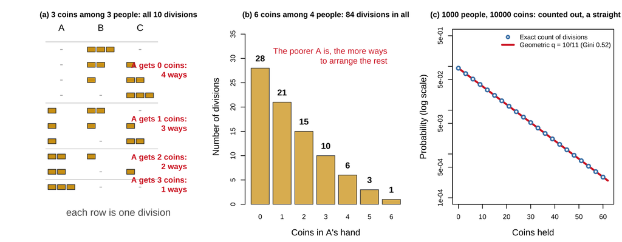

```r
GOLD <- "#D4A017"; ACC <- "#D62728"
par(mfrow = c(1, 3), mar = c(4.6, 4.6, 3.6, 1.0), cex.lab = 1.3, cex.main = 1.12)

## (a) 3 coins among 3 people: draw all 10 divisions one by one
comp <- as.matrix(expand.grid(A = 0:3, B = 0:3, C = 0:3)); comp <- comp[rowSums(comp) == 3, ]
comp <- comp[order(comp[, "A"], -comp[, "B"]), ]
R <- nrow(comp)
plot(NA, xlim = c(0.55, 4.35), ylim = c(0.3, R + 0.9), axes = FALSE,
     xlab = "", ylab = "", main = "(a) 3 coins among 3 people: all 10 divisions")
axis(3, at = 1:3, labels = c("A", "B", "C"), tick = FALSE, line = -1.4, cex.axis = 1.35)
for (r in 1:R){
  y <- R - r + 1
  for (j in 1:3){
    cnt <- comp[r, j]
    if (cnt == 0) text(j, y, "-", col = "gray70", cex = 1.5)
    else rect(j - 0.34 + (0:(cnt-1))*0.24, y - 0.16, j - 0.34 + (0:(cnt-1))*0.24 + 0.20, y + 0.16,
              col = GOLD, border = "gray25")
  }
}
grp <- table(factor(comp[, "A"], levels = 0:3))
ytop <- R
for (n in 0:3){
  k <- grp[as.character(n)]
  segments(0.6, ytop + 0.5, 3.45, ytop + 0.5, col = "gray80")
  text(4.3, ytop - k/2 + 0.5, sprintf("A gets %d coins:\n%d ways", n, k),
       col = ACC, cex = 1.15, font = 2, pos = 2)
  ytop <- ytop - k
}
mtext("each row is one division", side = 1, line = 0.6, cex = 0.95, col = "gray35")

## (b) 6 coins among 4 people: the number of divisions falls all the way
ways <- choose(6 - (0:6) + 2, 2)
bp <- barplot(ways, names.arg = 0:6, col = adjustcolor(GOLD, .75), border = "gray30",
              ylim = c(0, 36), xlab = "Coins in A's hand", ylab = "Number of divisions",
              main = sprintf("(b) 6 coins among 4 people: %d divisions in all", sum(ways)))
text(bp, ways + 2, ways, font = 2, cex = 1.25)
text(bp[7], 30, "The poorer A is, the more ways\nto arrange the rest",
     col = ACC, cex = 1.2, pos = 2)

## (c) With enough people it becomes a straight line
Nn <- 1000; Mm <- 10000; nn <- 0:60
exact <- exp(lchoose(Mm - nn + Nn - 2, Nn - 2) - lchoose(Mm + Nn - 1, Nn - 1))
plot(NA, xlim = c(0, 62), ylim = c(1e-4, .5), log = "y",
     xlab = "Coins held", ylab = "Probability (log scale)",
     main = "(c) 1000 people, 10000 coins: counted out, a straight line")
curve((1/11)*(10/11)^x, add = TRUE, col = ACC, lwd = 3)
points(nn[seq(1, 61, 3)], exact[seq(1, 61, 3)], pch = 21, bg = "white",
       col = "steelblue", lwd = 2.2, cex = 1.15)
legend("topright", c("Exact count of divisions", "Geometric q = 10/11 (Gini 0.52)"),
       col = c("steelblue", ACC), pch = c(21, NA), pt.bg = "white",
       lwd = c(2.2, 3), lty = c(NA, 1), bty = "n", cex = 0.95)
```

Panel (a) is the smallest version you can count by hand: 3 coins among 3 people, 10 divisions in all, every one drawn there—A taking no coin accounts for 4 of them, and A taking all 3 for only 1. There are more ways to be poor than rich, and that is the whole reason. Panel (b) switches to 6 coins among 4 people, the same shape enlarged: 28, 21, 15, 10, 6, 3, 1.

Dividing 6 (mutually indistinguishable) coins among 4 people gives $\binom{9}{3} = 84$ divisions in all. Make the 84 equally likely—the strongest version of “completely fair,” favoring no outcome. Count how many of them leave A with exactly $n$ coins:

```r
N <- 4; M <- 6
comp <- expand.grid(rep(list(0:M), N)); comp <- comp[rowSums(comp) == M, ]
tab  <- table(factor(comp[[1]], levels = 0:M))       # number of divisions in which A holds n coins
rbind(`n coins held by A` = 0:M, `number of divisions` = as.integer(tab),
      `share`        = round(as.numeric(tab)/nrow(comp), 3))
```

```
##                       [,1]  [,2]   [,3]   [,4]  [,5]  [,6]  [,7]
## n coins held by A    0.000  1.00  2.000  3.000 4.000 5.000 6.000
## number of divisions 28.000 21.00 15.000 10.000 6.000 3.000 1.000
## share                0.333  0.25  0.179  0.119 0.071 0.036 0.012
```

```r
## With enough people it is exactly the geometric distribution: 1000 islanders divide 10000 coins
N <- 1000; M <- 10000
rbind(`exact count`   = round(sapply(0:6, function(n)
        exp(lchoose(M-n+N-2, N-2) - lchoose(M+N-1, N-1))), 4),
      `geometric q=10/11` = round((1/11) * (10/11)^(0:6), 4))
```

```
##                     [,1]   [,2]   [,3]   [,4]   [,5]   [,6]   [,7]
## exact count       0.0908 0.0826 0.0751 0.0683 0.0621 0.0564 0.0513
## geometric q=10/11 0.0909 0.0826 0.0751 0.0683 0.0621 0.0564 0.0513
```

The number of divisions is 28, 21, 15, 10, 6, 3, 1, falling all the way. The reason takes one sentence: the less A takes, the more ways the remaining money can be divided among the other three (with A taking $n$ coins, the other three divide $6-n$ coins in $\binom{6-n+2}{2}$ ways—exactly this string of numbers).

So “poor” is not the result of being beaten by anyone; it is the state with the most ways of being realized. Inequality here is a combinatorial-counting fact, with nothing to do with ability, effort, or competition.

This also settles the question Chapter 1 left open—why luck does not cancel between plus and minus. The mean does cancel: everyone’s expected wealth stays at 1.5 coins. But the shape of the distribution is not decided by the mean; it is decided by that string 28, 21, 15, 10, 6, 3, 1—stirring visits every division, and the probability of landing in a bin is proportional to how many divisions that bin has, so the count itself is the shape of the wealth distribution. Luck is not noise swinging around an equal share; it runs into the wall that says “cannot be negative,” and over the long run it settles into a baseline.

This count does not hold for coins alone. At the opening of *Anna Karenina*, Tolstoy wrote: “Happy families are all alike; every unhappy family is unhappy in its own way.” The line is usually taken as literary rhetoric, but it is the same count with coins swapped for lives.

Think about what “wealthy” requires: the choices at a chain of key junctures all have to be right—where you are born, what education you get, which industry you enter, when you buy property, whether your marriage holds, whether you avoid one big risk, whether your health fails… These conditions must hold at the same time; it is an intersection. “Not wealthy” needs only any one of them to fail—it is a union.

The intersection is narrow and the union is wide, exactly the same reasoning as counting coins above: with $k$ roughly independent key junctures, each passed with probability $p$, the chance of passing them all is $p^k$, shrinking fast as the number of junctures grows; while the number of ways of failing at least one grows fast with $k$. Few recipes for success, many for failure. “A taking 0 coins has 28 divisions, taking 6 has only 1” in the figure above says exactly this—except that there the junctures are where the coins go, and here they are the forks in a life.

(Jared Diamond later borrowed the principle to explain something else: why the world has so few large domesticated animals—a species has to satisfy six conditions at once: diet, growth rate, reproductive habits, temperament, stress response, and social structure, none dispensable (Diamond 1997). Hence the name “Anna Karenina principle.”)

With enough people this converges to an exact exponential law. When $N$ people divide $M$ coins and every division is equally likely,

$$P(n) \;=\;
\frac{\dbinom{M-n+N-2}{N-2}}{\dbinom{M+N-1}{N-1}}
\;\xrightarrow[\;N,\,M\,\to\,\infty\;]{}\; (1-q)\,q^{\,n},
\qquad q=\frac{c}{c+1},\quad c=\frac{M}{N}$$

That is the **geometric distribution**—the discrete version of the exponential. The second block of code above verifies exactly this step: 1000 islanders divide 10000 coins, and the exact count gives precisely the geometric distribution with $q=10/11$, consistent with the island simulation.

There is a technical question here that ought to be asked: why should every division be equally probable? That assumption is the whole basis of the counting above—replace it and the answer changes at once. And it does not follow from “all coins look the same”: the coins are of course indistinguishable, but that by itself does not give equal probability. What gives equal probability is the symmetry of the rule—this exchange rule favors no one and tracks no coin’s origin, so the only distinction it can make between states is “how many coins each person holds,” and equal weight can therefore fall only on divisions.

Section 3.1 took a completely different route (detailed balance, looking only at equal in and out flows) and reached the same answer. Two independent routes agreeing is the real reason this assumption stands.

What we have been counting has a name. That number—“how many concrete divisions realize a given configuration of counts”—is the **number of microstates** $W$; take its logarithm and divide by the number of people, and what you get is precisely entropy:

$$\frac{1}{N}\ln W \;=\; -\sum_i p_i \ln
p_i \;=\; H[p]$$

The derivation uses only Stirling’s expansion of the factorial and is pure algebra, so it does not affect this section’s conclusion—hence it sits in a collapsible you can skip. What matters is the identity itself: entropy is not defined by anyone; it is counted out; “maximum entropy” and “the most ways of being realized” are the same sentence. The whole of the next section (maximum entropy) rests on this identity.

**Three Lines of Stirling: Turning “the Number of Divisions” into “Entropy” (Skippable)**

Group the $N$ people by “how many coins each holds”: group $i$ has $N_i$ people and $p_i = N_i/N$. How many concrete person–coin assignments realize this configuration of counts? The multinomial coefficient $W = N!/\prod_i N_i!$. Take the logarithm and use $\ln N! \approx N\ln N - N$:

$$\begin{aligned}
\ln W &= \ln N! - \sum_i \ln N_i! \\[2pt]
&\approx \bigl(N\ln N - N\bigr) - \sum_i \bigl(N_i\ln N_i -
N_i\bigr)
&& \text{Stirling} \\[2pt]
&= N\ln N - \sum_i N_i\ln N_i
&& \textstyle\sum_i N_i = N\text{the two } -N \text{ terms
cancel} \\[2pt]
&= -\sum_i N_i\ln\frac{N_i}{N} \;=\; -N\sum_i p_i\ln p_i
&& \textstyle N\ln N = \sum_i N_i\ln N
\end{aligned}$$

Divide both sides by $N$ and we get $\frac1N\ln W = H[p]$ ∎

Because $W$ is exponential in $N$, a tiny difference in $H$ means a difference of several orders of magnitude in $W$—this is exactly where “the maximum-entropy state is overwhelmingly more likely” comes from. (The earlier essay has a fuller version with numerical checks: [Counting Argument: Entropy = the Log of the Number of Arrangements](https://nyuhuyang.github.io/notes/exp_normal_boltzmann_zh.html#%E8%AE%A1%E6%95%B0%E8%AE%BA%E8%AF%81%E7%86%B5-%E6%8E%92%E5%88%97%E6%95%B0%E7%9A%84%E5%AF%B9%E6%95%B0).)

While we are at it, let us explain the glaring number in the island simulation: the Gini at the end of the run is 0.523, not 0.500. It is not a failure to converge; the coins are not fine enough. The Gini of the geometric distribution has a closed form (derived in the collapsible at the end of Chapter 4),

$$G_{\text{geometric}} \;=\; \frac{1}{1+q}
\;=\; \frac{c+1}{2c+1}$$

With 10 coins per person, $c=10$, and $G = 11/21 = 0.524$. The smaller the coins and the larger $c$, the closer $G\to 1/2$. The value 0.5 is the limit once the coins are ground to dust.

## 3.3 The General Route: Maximum Entropy

The maximum-entropy principle ignores dynamics and looks only at what you know—so change the constraints and you change the distribution: the same machine can produce a normal, a power law, a Boltzmann. The price is abstraction; the reward is generality, and it hands you the quantity called temperature outright—as the end of this section will show, the island’s per-capita coins, $\mu$, play exactly that role.

Step 1: ask what entitles us to assume anything. About this island we know only three things: the total number of coins is fixed, no one can hold a negative amount, and the rule is the same for everyone. Beyond that, nothing. To assert at this point that “the distribution is normal” or “is a power law” is to smuggle in information we do not have.

One principle governs exactly this—the maximum-entropy principle ([Jaynes](https://nyuhuyang.github.io/notes/exp_normal_boltzmann_zh.html#jaynes%E6%9C%80%E5%A4%A7%E7%86%B5-%E6%9C%80%E8%AF%9A%E5%AE%9E%E7%9A%84%E6%8E%A8%E6%96%AD)): among all distributions that satisfy the known constraints, choose the one with the largest entropy, because it is the one that assumes least beyond what is known. Any other distribution amounts to quietly assuming something extra.

We use two results directly here, without re-deriving them (the earlier essay gives the full proofs):

- The form of entropy: $H[p] = -\sum_i p_i\ln p_i$ (continuous version $-\int p\ln p\,dx$). It measures how “spread out” a distribution is, that is, how much uncertainty it carries ([The Definition of Information Entropy](https://nyuhuyang.github.io/notes/exp_normal_boltzmann_zh.html#%E4%BF%A1%E6%81%AF%E7%86%B5%E7%9A%84%E5%AE%9A%E4%B9%89)).
- Entropy has a second, harder identity: it equals the log of the number of microscopic realizations per person, $\frac1N\ln W = H[p]$, where $W = N!/\prod_i N_i!$ is the number of microstates counted in the previous section (which gave the Stirling derivation). Because $W$ is exponential in $N$, the maximum-entropy distribution is not merely “the most honest guess” but the one you are overwhelmingly certain to see after random stirring—deviate a little and the number of microstates collapses by several orders of magnitude.

(The previous section counted exactly this $W$: 6 coins among 4 people, 84 divisions. Take its log, divide by the number of people, and you have entropy.)

Step 2: write the three known things as constraints. Grind the coins fine and write a density $p(x)$:

1. It is a probability density: $\int_0^\infty p(x)\,dx = 1$;
2. Coins per capita are fixed: $\int_0^\infty x\,p(x)\,dx = \mu$;
3. The support is the non-negative half-line: $x\ge 0$ (this is not an equality constraint; it lives in the lower limit of integration).

Constraint 2 is the distributional form of “total is conserved”: the total number of coins is fixed and so is the number of people, so the per-capita amount is fixed automatically. These two constraints are inputs to the problem, not conclusions—they are precisely the information we actually have.

Step 3: vary, and solve for the shape. Maximize $H$ under the constraints, using Lagrange multipliers to absorb them into the objective (for the geometric picture of the multipliers see [here](https://nyuhuyang.github.io/notes/exp_normal_boltzmann_zh.html#%E6%8B%89%E6%A0%BC%E6%9C%97%E6%97%A5%E4%B9%98%E5%AD%90%E9%9B%B6%E5%9F%BA%E7%A1%80%E7%89%88)):

$$L \;=\; -\int p\ln p\,dx \;-\;
\lambda_0\Big(\int p\,dx - 1\Big) \;-\; \lambda_1\Big(\int x\,p\,dx -
\mu\Big)$$

What we are optimizing is not a number but a whole function—which $p$ makes $H$ largest—hence the calculus of variations. In practice one rule suffices: differentiate the integrand with respect to $p$ as an ordinary variable. The entropy term gives $\frac{\partial}{\partial p}(p\ln p) = \ln p + 1$ (product rule; the $+1$ comes from $p\cdot\frac1p$), so

$$\frac{\delta L}{\delta p} \;=\; -\ln
p(x) - 1 - \lambda_0 - \lambda_1 x \;=\; 0
\qquad\Longrightarrow\qquad
p(x) \;=\; \frac{1}{Z}\,e^{-\lambda_1 x},\quad Z =
e^{1+\lambda_0}$$

That is where the exponential form comes from: $\ln p$ is what differentiating entropy produces, and it has been set equal to a linear combination of the constraint functions—a linear term $x$ goes in, $e^{-\lambda_1 x}$ comes out. (Change the constraints and you change the distribution: a constraint on $x^2$ gives the normal, a constraint on $\ln x$ gives a power law—see [The General Form of a Distribution](https://nyuhuyang.github.io/notes/exp_normal_boltzmann_zh.html#%E6%8B%89%E6%A0%BC%E6%9C%97%E6%97%A5%E4%B9%98%E5%AD%90%E6%8E%A8%E5%AF%BC%E5%88%86%E5%B8%83%E7%9A%84%E4%B8%80%E8%88%AC%E5%BD%A2%E5%BC%8F).)

All that remains is to pin down the two constants. Normalization gives $Z = 1/\lambda_1$; the mean gives

$$\int_0^\infty x\,\lambda_1 e^{-\lambda_1
x}\,dx \;=\; \frac{1}{\lambda_1} \;=\; \mu
\qquad\Longrightarrow\qquad
\boxed{\;p(x) \;=\; \frac1\mu\,e^{-x/\mu}\;}$$

Step 4: it is unique. Strictly, the variation only finds a stationary point; one still has to prove that this point is the global maximum and that it is unique. Gibbs’ inequality (non-negative KL divergence) settles it in a few lines: over all distributions on $x\ge0$ with mean $\mu$, $H(p)\le 1+\ln\mu$, with equality only when $p$ is that exponential. For the full proof see A Rigorous Proof: Exponential Maximizes Entropy at Fixed Mean.

The division of labor between the two steps is worth remembering: the variation finds the candidate; Gibbs’ inequality proves it unique.

Where this lands. Nothing on the island is “selecting” the exponential distribution. It is the unique unbiased conclusion of the three statements “total is conserved + no negative holdings + nothing else known,” and at the same time the state with overwhelmingly the most microscopic realizations. Here $\mu$ plays the role of temperature: the more coins per capita, the more spread out the distribution. It is the same equation as the Boltzmann–Gibbs distribution in physics, with “energy” replaced by “coins.”

**A fourth route: verify directly that this rule’s fixed point is the exponential (skippable)**

The rule is $w_i' = eS$, $w_j' = (1-e)S$, where $S = w_i + w_j$, $e\sim U(0,1)$. Suppose the two people already follow $\mathrm{Exp}(1)$ independently; check whether they still do after one step:

1. $S = w_i + w_j \sim \mathrm{Gamma}(2,1)$
2. $U(0,1)$ is just $\mathrm{Beta}(1,1)$
3. Beta–Gamma algebra: if $S\sim\mathrm{Gamma}(a+b)$ and $B\sim\mathrm{Beta}(a,b)$ are independent, then $BS \sim \mathrm{Gamma}(a)$
4. Take $a=b=1$: $eS \sim \mathrm{Gamma}(1) = \mathrm{Exp}(1)$ ∎

The exponential distribution is the fixed point of this dynamics. The intuition takes one sentence: in equilibrium the two people’s wealth is already split in proportion $U(0,1)$ of their sum ($X/(X+Y)\sim U(0,1)$ is an old property of the exponential), so “split it randomly once more” changes nothing.

## 3.4 Swap a Part: The Continuous Version and Three Variants

Grind the coins into dust and the model becomes continuous: $N$ people each hold 1 unit of resources, pair at random, and redistribute the pair’s combined holdings in a random proportion, conserving the total. The rule is still identical for everyone. This version runs fast, and it is easy to change one part and see what happens.

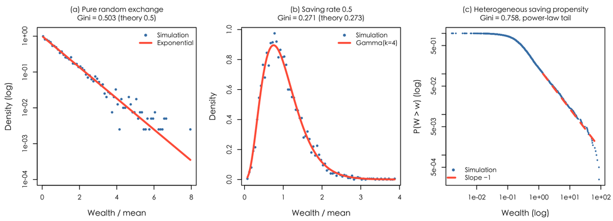

```r
set.seed(1)
KIN_N <- 4000; KIN_R <- 1200
reg("kin_N", KIN_N, "analytic", "§3.4 kinetic_exchange", "number of people in the continuous-version simulation")
reg("kin_R", KIN_R, "analytic", "§3.4 kinetic_exchange", "number of rounds in the continuous-version simulation")
## The top-wealth multiple is the closed-form H_N evaluated, not typed by hand: H_N = sum 1/k, Gumbel sd pi/sqrt(6)
kin_HN <- sum(1/seq_len(KIN_N)); kin_lnN <- log(KIN_N)
## Use exact quantiles for the top-wealth interval, not mean +- k*sd—the Gumbel is right-skewed, so a symmetric interval understates the right tail.
## The maximum M of N Exp(1) draws satisfies P(M<=x) = (1-e^{-x})^N, so the quantiles have a closed form.
kin_q <- function(p) -log(1 - p^(1/KIN_N))
reg("kin_HN",   kin_HN,      "analytic", "§3.4 kinetic_exchange", "H_N, the expected multiple of the mean held by the richest of N people")
reg("kin_lnN",  kin_lnN,     "analytic", "§3.4 kinetic_exchange", "ln N, the leading term of H_N")
reg("kin_q025", kin_q(.025), "analytic", "§3.4 kinetic_exchange", "2.5% quantile of the top-wealth multiple (closed form)")
reg("kin_q975", kin_q(.975), "analytic", "§3.4 kinetic_exchange", "97.5% quantile of the top-wealth multiple (closed form)")
stopifnot(abs(kin_HN - (kin_lnN + 0.5772156649)) < 1e-3,
          kin_q(.975) - kin_HN > kin_HN - kin_q(.025))   # right-skewed: the upper tail must be longer
kinetic <- function(N = KIN_N, rounds = KIN_R, lam = 0, lam_vec = NULL){
  w <- rep(1, N); L <- if (is.null(lam_vec)) rep(lam, N) else lam_vec; half <- N/2
  for (r in 1:rounds){
    idx <- sample.int(N); i <- idx[1:half]; j <- idx[(half+1):N]
    pooled <- (1-L[i])*w[i] + (1-L[j])*w[j]; e <- runif(half)
    w[i] <- L[i]*w[i] + e*pooled
    w[j] <- L[j]*w[j] + (1-e)*pooled
  }
  w
}
wa <- kinetic(lam = 0)          # (a) pure random exchange
wb <- kinetic(lam = 0.5)        # (b) everyone keeps half, then exchanges
set.seed(2)
wc <- kinetic(lam_vec = runif(KIN_N))   # (c) saving propensity differs across people
## Closed form for the Gamma(k=4) Gini; the caption and the registry entry below share this one variable (the formula is written once).
## k = 1 + 3λ/(1-λ), and λ=0.5 gives k=4.
g4_closed <- gamma(4.5)/(sqrt(pi)*gamma(5))

par(mfrow = c(1, 3), mar = c(4.4, 4.6, 3.4, 1), family = "cjk")
u <- wa/mean(wa); h <- hist(u[u < 8], breaks = 60, plot = FALSE)
plot(h$mids, h$density, log = "y", pch = 16, col = "steelblue", cex = 0.8, ylim = c(1e-4, 1.2),
     main = sprintf("(a) Pure random exchange\nGini = %.3f (theory 0.5)", gini(wa)),
     xlab = "Wealth / mean", ylab = "Density (log)", cex.lab = 1.2, cex.main = 1.05)
curve(exp(-x), add = TRUE, col = "tomato", lwd = 3)
legend("topright", c("Simulation", "Exponential"), pch = c(16, NA), lwd = c(NA, 3),
       col = c("steelblue", "tomato"), bty = "n", cex = 0.95)

ub <- wb/mean(wb); hb <- hist(ub, breaks = 60, plot = FALSE)
plot(hb$mids, hb$density, pch = 16, col = "steelblue", cex = 0.8,
     main = sprintf("(b) Saving rate 0.5\nGini = %.3f (theory %.3f)", gini(wb), g4_closed),
     xlab = "Wealth / mean", ylab = "Density", cex.lab = 1.2, cex.main = 1.05)
curve(dgamma(x*4, shape = 4)*4, add = TRUE, col = "tomato", lwd = 3)
legend("topright", c("Simulation", "Gamma(k=4)"), pch = c(16, NA), lwd = c(NA, 3),
       col = c("steelblue", "tomato"), bty = "n", cex = 0.95)

sc <- sort(wc, TRUE); sf <- seq_along(sc)/length(sc)
plot(sc, sf, log = "xy", pch = 16, col = "steelblue", cex = 0.55,
     main = sprintf("(c) Heterogeneous saving propensity\nGini = %.3f, power-law tail", gini(wc)),
     xlab = "Wealth (log)", ylab = "P(W > w) (log)", cex.lab = 1.2, cex.main = 1.05)
reg("save_all",  gini(wb), "point", "§3.4 kinetic_exchange", "universal saving rate 0.5; analytic value 0.2734")
## Closed form for the Gamma(k=4) Gini, registered separately from the simulated value above: the caption and the folded title cite this theoretical value.
reg("save_all_closed", g4_closed, "analytic", "§3.4 kinetic_exchange",
    "closed-form Gini of Gamma(k=4): Γ(k+½)/(√π Γ(k+1)); k=1+3λ/(1-λ) gives k=4 at λ=0.5")
reg("save_het",  gini(wc), "point", "§3.4 kinetic_exchange", "saving propensity differs across people")
xx <- 10^seq(log10(quantile(wc, .9)), log10(max(wc)), length.out = 40)
lines(xx, 0.1*(xx/quantile(wc, .9))^(-1), col = "tomato", lwd = 3, lty = 2)
legend("bottomleft", c("Simulation", "Slope −1"), pch = c(16, NA), lwd = c(NA, 3),
       lty = c(NA, 2), col = c("steelblue", "tomato"), bty = "n", cex = 0.95)
```

The left panel is the continuous limit of the island model: an exponential distribution, a straight line on semi-log axes, Gini 0.503—once the coins are ground fine, that $11/21$ lands on $1/2$. Random exchange of a conserved quantity has, as its equilibrium, the maximum-entropy distribution at fixed mean (review: [Exponential = Maximum Entropy on the Non-Negative Half-Line at Fixed Mean](https://nyuhuyang.github.io/notes/exp_normal_boltzmann_zh.html#%E6%8C%87%E6%95%B0%E5%88%86%E5%B8%83-%E6%9C%80%E5%A4%A7%E7%86%B5-%E9%9D%9E%E8%B4%9F-%E5%9D%87%E5%80%BC%E7%BA%A6%E6%9D%9F)).

The middle and right panels are two modifications. If each person first keeps half and then exchanges, the distribution becomes Gamma and the Gini falls to 0.271—saving, a habit that looks unrelated to fairness, is itself an equalizing force (Chakraborti and Chakrabarti 2000). If the saving propensity differs across people (some save more, some less; this is the only heterogeneity), the tail turns into a power law at once and the Gini shoots up to 0.758 (Chatterjee et al. 2004).

Worth pausing on: the inequality in the right panel is not because anyone is “more able”; it is purely because the rule differs across people. Once heterogeneity enters a multiplicative structure, the exponential tail becomes a power-law tail—why that happens, the next section states with a one-line identity.

The third variant is not in the row above, because it will not fit there. The first two swapped “how much each person keeps”; the third swaps “how much is put up for exchange each time”: instead of splitting the pair’s pooled sum at random, the two bet a fixed fraction of their wealth—this is the yard-sale model (Chakraborti 2002). Conservation is untouched, fairness is untouched, the homogeneity of the rule is untouched, and yet the stationary state simply disappears: the distribution keeps widening and the Gini climbs without bound toward 1. The three panels above each have a steady-state shape you can report a number for; this one does not even converge in shape, so it cannot sit beside them. It is the heaviest variant in this essay—it shows that “procedural fairness” is not a binary property at all—and §4.3 spends a whole section on it.

(The in-text version of this argument is the next section; for a longer setup see [scale-free: Drawing and Proving Multiplicative Memorylessness](https://nyuhuyang.github.io/notes/exp_normal_boltzmann_zh.html#scale-free%E6%8A%8A%E4%B9%98%E6%80%A7%E6%97%A0%E8%AE%B0%E5%BF%86%E7%94%BB%E5%87%BA%E6%9D%A5%E5%B9%B6%E8%AF%81%E6%98%8E%E5%AE%83%E5%94%AF%E4%B8%80); for why wealth is so often discussed as a power law, see [the side note in that section](https://nyuhuyang.github.io/notes/exp_normal_boltzmann_zh.html#%E6%97%81%E4%BE%8B%E8%B4%A2%E5%AF%8C%E5%88%86%E5%B8%83%E4%B8%BA%E4%BB%80%E4%B9%88%E5%B8%B8%E8%A2%AB%E8%B0%88%E5%B9%82%E5%BE%8B). The right panel here supplies exactly the mechanism that side note was missing: a power-law tail needs no difference in ability, only heterogeneity in the rule.)

**Where the 0.273 in the middle panel comes from (skippable)**

With a saving rate $\lambda$ added, the equilibrium is a Gamma distribution with shape parameter (a very good numerical approximation, Chakraborti–Chakrabarti)

$$k \;=\; 1 + \frac{3\lambda}{1-\lambda}
\qquad\Longrightarrow\qquad
\lambda = 0.5 \ \Rightarrow\ k = 4$$

corresponding to `dgamma(shape = 4)` in the code above. The Gamma Gini has a closed form:

$$G \;=\;
\frac{\Gamma\!\left(k+\tfrac12\right)}{\sqrt{\pi}\,\Gamma(k+1)}$$

Substituting $k=4$ gives $11.632/42.539 = 0.2734$; substituting $k=1$ gives $0.5$, the exponential again, as it should. $k$ is an “effective degrees of freedom”—saving turns each person’s wealth into a sum of several independent shocks, the central limit pulls it toward the mean, and inequality falls out naturally.

(Review: the Gamma is [the maximum-entropy distribution subject to both $\langle x\rangle$ and $\langle \ln x\rangle$](https://nyuhuyang.github.io/notes/exp_normal_boltzmann_zh.html#%E5%90%88%E4%BD%93%E5%90%8C%E6%97%B6%E7%BA%A6%E6%9D%9F-langle-xrangle-%E5%92%8C-langleln-xrangle-gamma). This gives saving an information-theoretic reading: saving locks down $\langle\ln x\rangle$ in addition—it suppresses fluctuations on the log scale, that is, it suppresses the bankruptcy end, and $k>1$ is the trace of that constraint.)

## 3.5 The Top Segment: Why Multiplicative Noise Gives a Power Law

The right-hand panel of the previous section already had a power-law tail, but there we dropped a single sentence—“once heterogeneity enters a multiplicative structure, the exponential tail becomes a power-law tail”—without saying why. This section fills that in, and it needs no new machine: all three routes above still apply, once we change coordinates.

First, reduce the difference to its smallest form. The exchange in the chapter so far is **additive**: each round hands over one coin, regardless of how much you hold. Once the saving propensity differs across people, each person’s wealth is multiplied each round by a coefficient of their own—what changes hands is a **proportion**. The whole difference is whether the noise travels with wealth—that one sentence says it all.

And a proportion is addition on the log scale. Hence the identity below, which is the entire content of this section:

$$\ln\frac{W}{w_{\min}}\sim\mathrm{Exp}(\alpha)
\qquad\Longleftrightarrow\qquad
P(W>x)=\Bigl(\frac{x}{w_{\min}}\Bigr)^{-\alpha},\quad x\ge
w_{\min}$$

A power law is an exponential on the log scale. The $\mathrm{Exp}(\alpha)$ on the left is exactly what §3.1 to §3.3 derived three times, except that it lives on $\ln W$ rather than $W$. So the answer to “why a power law” is “because on the log scale it is that same exponential, already proved three times.”

```r
## Verify this identity, and deliberately sample in reverse: first draw an exponential on the log scale, then exponentiate back,
## and see whether the power law emerges on its own—rather than building a power law first and then fitting it.
set.seed(21)
PL_A <- 1.9                       # same tail exponent as the UK wealth segment in §2.6
PL_MIN <- 1
pl_w  <- PL_MIN * exp(rexp(2e5, rate = PL_A))
pl_ln <- log(pl_w/PL_MIN)
## (a) on the log scale this should be exponential with mean 1/alpha
stopifnot(abs(mean(pl_ln) - 1/PL_A) < 0.01)
## (b) on the original scale it should be a power law: the slope of the log-log survival curve is -alpha
pl_x <- quantile(pl_w, seq(0.5, 0.999, length.out = 60))
pl_S <- sapply(pl_x, function(t) mean(pl_w > t))
pl_slope <- unname(coef(lm(log(pl_S) ~ log(pl_x)))[2])
stopifnot(abs(pl_slope + PL_A) < 0.05)
reg("pl_alpha",  PL_A,        "analytic", "§3.5 log_scale", "tail exponent used for the check, taken from the UK wealth segment in §2.6")
reg("pl_lnmean", mean(pl_ln), "point",    "§3.5 log_scale", "sample mean on the log scale, theoretical value 1/alpha")
reg("pl_slope",  pl_slope,    "point",    "§3.5 log_scale", "fitted slope of the log-log survival curve, theoretical value -alpha")
```

Draw 200,000 samples: the mean on the log scale is 0.5262 (theory $1/\alpha=$ 0.5263), and after mapping back to the original scale the slope of the log-log survival curve is -1.895 (theory $-\alpha=$ -1.9). Nothing was fitted; the power law was sampled.

### 3.5.1 Two Constraints, Two Segments

The power-law segment: support $x\ge x_{\min}$, replace the constraint with the log mean $\int_{x_{\min}}^\infty \ln x\,p(x)\,dx=m$. In the Lagrangian, replace $\lambda_1 x$ with $\lambda_1\ln x$:

$$L=-\int p\ln p\,dx-\lambda_0\left(\int
p\,dx-1\right)-\lambda_1\left(\int \ln x\,p\,dx-m\right)$$

Varying with respect to $p$ gives $-\ln p-1-\lambda_0-\lambda_1\ln x=0$, so $p(x)\propto x^{-\lambda_1}$. Write the tail exponent as $\alpha=\lambda_1-1$ and normalize with the lower bound:

$$p(x)=\frac{\alpha}{x_{\min}}\left(\frac{x}{x_{\min}}\right)^{-(\alpha+1)},\qquad
x\ge x_{\min}$$

The constraint pins down $\alpha$: the Pareto log mean is $m=\ln x_{\min}+1/\alpha$, so $\alpha=1/(m-\ln x_{\min})$. The larger $\alpha$ is, the closer the log mean sits to the lower bound and the lighter the tail; the smaller $\alpha$ is, the heavier the tail.

The key point is this: the arithmetic mean of a power law need not exist. For $\alpha\le1$, $\int x\,p(x)\,dx$ diverges, so “average income” cannot pin it down at all; the log mean can. The exponential segment is the opposite: it has a finite mean and lacks the power law’s scale invariance, so the arithmetic mean is the natural constraint. The two segments are not “two parameters of one distribution”; they are two maximum-entropy machines with different constraints.

In the language of income: the wage component is additive and bounded below, and long-run budget balance pins its arithmetic mean, so it is exponential; the property component is multiplicative and scale-invariant, and the multiplicative process pins its log mean, so it is a power law.

One boundary remains. Put both constraints on a single distribution supported on $x\ge0$, and the result is not this spliced distribution but a Gamma (as noted earlier: Gamma is the maximum-entropy solution under both $\langle x\rangle$ and $\langle\ln x\rangle$). The two-segment distribution solves two mechanisms separately and splices them at the seam; it is not one distribution constrained by both means. Treating the Gamma as “the unified solution for the two segments” mistakes a gear change for two parameters of one curve.

But one thing cannot be copied over, and it explains precisely why the power law can live only at the top. The machine in §3.1 requires a wall: $W\ge0$, and a reflecting one. Move to the log scale and the wall is gone—$\ln W\to-\infty$ is reachable, corresponding to $W\to0$, and $W=0$ is at infinity on the log scale, not a lattice site. The $w_{\min}$ in the identity above is that wall shoved back in by hand: without it, $\int_0^\infty x^{-(1+\alpha)}\,\mathrm dx$ diverges at the 0 end, and the power law does not exist at all.

So the two segments are not on equal footing. The power-law segment must sit on top of something else—it cannot supply its own lower bound. The UK wealth fit in §2.6 is written exactly that way: exponential below £100,000, power law above, and that 100,000 is at once the splice point and the $w_{\min}$ here.

What this section has not said is what $\alpha$ equals. It is set by the dynamics, and there is more than one way to set it: Chapter 5 will solve for $\alpha$ directly from a conserving exchange rule, adding nothing external; the Fokker–Planck route mentioned in §2.7 takes the other path, relying on an exogenous proportional restoring term. Both routes reach a power law, but not over the same interval—Chapter 5 will make that clear at the outset.

# 4 Question Two: How Is a Gini of 0.5 Calculated, and What Does It Mean?

Once the shape is settled, Question Two comes down to two things: computing the number, and saying clearly what kind of society it implies. (One reminder: every Gini in this chapter is a wealth Gini; the only exception will be explicitly labeled “income”.)

## 4.1 Calculating 0.5

The previous section fixed the shape; Question Two asks how unequal that shape is. This section computes the Gini coefficient—three steps, and only the shape of the distribution is used, nothing about where it came from.

Step 1: write the Gini a different way.

The Gini is usually defined through the Lorenz curve: twice the area between the diagonal and the Lorenz curve (the next section draws that shaded area). But equivalently there is a form far handier to compute:

$$G \;=\; \frac{E\,|X-Y|}{2\mu},\qquad X,Y
\ \text{independent and identically distributed}$$

How to read it: pick two people at random, take the expected wealth gap, divide by twice the mean. The $2\mu$ in the denominator normalizes it—in the extreme case (one person takes everything) $E|X-Y| \to 2\mu$ and $G\to 1$; under perfect equality the numerator is 0.

First, say where this object lives: $G$ is a **functional on the space of distributions**, not a property of some sample. So “the Gini of an exponential distribution” is a fixed number, with no estimation error to speak of; the simulation is only checking convergence.

Step 2: the Gini does not depend on the mean, and that is structural—you can see it without computing anything.

The exponential family has a single parameter, and it is a **scale parameter**: $X\sim\mathrm{Exp}(\mu)$ is the same as $X = \mu Z$ with $Z\sim\mathrm{Exp}(1)$. And $G$ is scale-invariant:

$$\frac{E|cX - cY|}{2c\mu} \;=\;
\frac{E|X-Y|}{2\mu}$$

So along the whole ray of exponential distributions $G$ is the same constant. All that remains is to compute it.

Step 3: compute $1/2$.

Let $X,Y$ be iid $\mathrm{Exp}(r)$; first find the distribution of $|X-Y|$. By symmetry and [memorylessness](https://nyuhuyang.github.io/notes/exp_normal_boltzmann_zh.html#%E6%80%A7%E8%B4%A8%E6%97%A0%E8%AE%B0%E5%BF%86%E6%80%A7) (recall: $P(X>s+t\mid X>s)=P(X>t)$—the exponential distribution “does not remember how long it has waited”):

$$P(|X-Y| > t) \;=\; 2\,P(X > Y+t)
\;=\; 2\,E_Y\!\left[e^{-r(Y+t)}\right] \;=\;
2e^{-rt}\underbrace{E\!\left[e^{-rY}\right]}_{=\,\frac{r}{r+r}=\frac12}
\;=\; e^{-rt}$$

That is: the absolute difference of two exponential variables is again the same exponential distribution. Hence $E|X-Y| = \mu$, and plugging back into Step 1:

$$G \;=\; \frac{\mu}{2\mu} \;=\;
\boxed{\tfrac12}$$

The $1/2$ comes from that $2$: the expected gap is exactly one mean, while the normalization uses two. The Lorenz route cross-checks the same way—for the exponential, $L(p) = p + (1-p)\ln(1-p)$, $\int_0^1 L = \tfrac12 - \tfrac14 = \tfrac14$, $G = 1 - 2\cdot\tfrac14 = \tfrac12$.

The same curve also gives a second exact constant, needed in Chapter 5. Take the **vertical gap** “diagonal minus Lorenz curve” and look at it on its own:

$$D(x) \;\equiv\; x - L(x)$$

The Gini is twice its area, $G = 2\int_0^1 D(x)\,\mathrm dx$. And it has another, equally natural reading—the peak:

$$P \;\equiv\; \max_x D(x)$$

This number has a name, the Pietra index (proposed in 1915; also called the Robin Hood index or Hoover index). Its meaning is plain: the percentage of total wealth that would have to be moved from people above mean wealth to people below it to make everyone equally rich.

For the exponential distribution both numbers can be computed exactly:

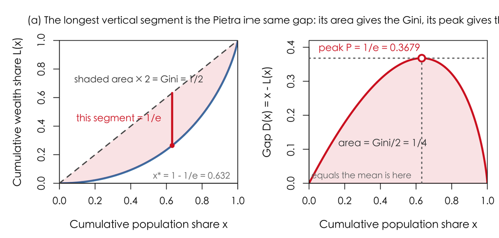

```r
## Lorenz gap of the exponential distribution: D(x) = x - L(x), L(x) = x + (1-x)ln(1-x)
## Gini = 2∫D (twice the area); Pietra = max D (the peak). Both are closed-form.
BLU <- "steelblue"; ACC <- "#D62728"; GRY <- "gray45"
Lx <- function(x){ y <- x + (1 - x)*log(1 - x); y[!is.finite(y)] <- x[!is.finite(y)]; y }
## as x -> 1, -(1-x)ln(1-x) is 0·(-Inf), which R returns as NaN; the limit is 0, so patch the endpoint. Same at x = 0.
Dx <- function(x){ y <- -(1 - x)*log(1 - x); y[!is.finite(y)] <- 0; y }
xs <- seq(1e-9, 1 - 1e-9, length.out = 2000)
xstar <- 1 - exp(-1); Pstar <- exp(-1)         # analytic: the maximum and the peak

par(mfrow = c(1, 2), mar = c(4.6, 5.0, 3.4, 1.0), cex.lab = 1.08, cex.main = 1.02,
    family = "cjk")

## (a) The longest vertical segment on the Lorenz curve
plot(xs, Lx(xs), type = "l", lwd = 3.2, col = BLU, xlim = c(0,1), ylim = c(0,1),
     xaxs = "i", yaxs = "i", xlab = "Cumulative population share x", ylab = "Cumulative wealth share L(x)",
     main = "(a) The longest vertical segment is the Pietra index")
polygon(c(xs, rev(xs)), c(xs, rev(Lx(xs))), col = adjustcolor(ACC, .12), border = NA)
lines(c(0,1), c(0,1), lty = 2, lwd = 2, col = "gray35")
segments(xstar, Lx(xstar), xstar, xstar, lwd = 3.4, col = ACC)
points(xstar, Lx(xstar), pch = 16, col = ACC, cex = 1.1)
text(0.05, 0.72, "shaded area × 2 = Gini = 1/2", col = "gray25", pos = 4, cex = 0.95)
text(xstar, (xstar + Lx(xstar))/2, "this segment = 1/e  ", col = ACC, pos = 2, cex = 0.98)
text(0.99, 0.045, sprintf("x* = 1 - 1/e = %.3f", xstar), col = GRY, pos = 2, cex = 0.9)

## (b) Draw the gap on its own
plot(xs, Dx(xs), type = "l", lwd = 3.2, col = ACC, xlim = c(0,1), ylim = c(0, 0.42),
     xaxs = "i", yaxs = "i", xlab = "Cumulative population share x", ylab = "Gap D(x) = x - L(x)",
     main = "(b) The same gap: its area gives the Gini, its peak gives the Pietra index")
polygon(c(xs, rev(xs)), c(Dx(xs), rep(0, length(xs))), col = adjustcolor(ACC, .12), border = NA)
segments(xstar, 0, xstar, Pstar, lty = 3, lwd = 2, col = GRY)
abline(h = Pstar, lty = 3, lwd = 2, col = GRY)
points(xstar, Pstar, pch = 21, bg = "white", col = ACC, lwd = 3, cex = 1.5)
text(0.02, 0.395, sprintf("peak P = 1/e = %.4f", Pstar), col = ACC, pos = 4, cex = 1.0)
text(0.13, 0.115, "area = Gini/2 = 1/4", col = "gray25", pos = 4, cex = 1.0)
text(xstar, 0.020, "the person whose wealth equals the mean is here  ", col = GRY, pos = 2, cex = 0.88)
```

```r
## Self-check: the closed forms agree, and the Lorenz slope is 1 at the maximum
stopifnot(abs(2*integrate(Dx, 0, 1)$value - 0.5) < 1e-6,   # numerical integration, not an analytic comparison
          abs(optimize(Dx, c(1e-9, 1-1e-9), maximum = TRUE)$objective - exp(-1)) < 1e-6,
          abs((Lx(xstar + 1e-6) - Lx(xstar - 1e-6))/2e-6 - 1) < 1e-4)
reg("pietra_baseline",  exp(-1), "analytic", "§4.1 lorenz_gap", "Pietra index of the exponential distribution = 1/e")
reg("pietra_cut",       xstar,   "analytic", "§4.1 lorenz_gap", "maximum of the gap = 1 - 1/e, the quantile where wealth equals the mean")
```

Where the peak falls is also closed-form: $D'(x)=0$ means $L'(x)=1$, and the slope of the Lorenz curve is “wealth at that percentile divided by the mean”, so the maximum is exactly at the person whose wealth equals the mean. For the exponential that is the $1-1/e \approx 63.2\%$ percentile, and the peak is $P = 1/e \approx 0.368$.

This delivers exactly the promise left in §2.6. There the Gini was split into “within + between”, and the between term was said to be the value of $D$ at the cut point, $D(p_L)$; the cut point, it was noted, is a choice. Now the sentence can be finished: if you do not want to choose, take the point that makes the between term as large as possible—that is $x^*$ here, and at that point the between term equals $P$ exactly. So “how much extra the top takes” has a standard answer with zero fitted parameters.

So the baseline carries two constants that need no fitting at all:

$$\underbrace{G=\tfrac12}_{\text{twice the
area of the gap}} \qquad\qquad \underbrace{P=\tfrac1e}_{\text{the peak
of the gap}}$$

These two numbers are two readings of the same curve—one compresses the whole gap into an area, the other takes only its highest point. Chapter 5 will show that the distinction is not rhetorical: what gets lost in compressing to one number is exactly the problem that chapter takes up.

To close: how unequal is it, really. On this island only about 39% of islanders sit above the mean, and that minority holds 77% of the coins; the bottom half together hold 16%. (These three numbers are computed from the island’s discrete geometric distribution; in the continuous limit they are 37%, 74%, 15%, which the next section expands on.) A Gini of 0.5 sounds mild. It is not.

## 4.2 What a Gini of 0.5 Looks Like

The previous section computed the Gini, but 0.5 is still an abstract number. Translate it into something visible: line up these 4000 people by wealth and draw a Lorenz curve.

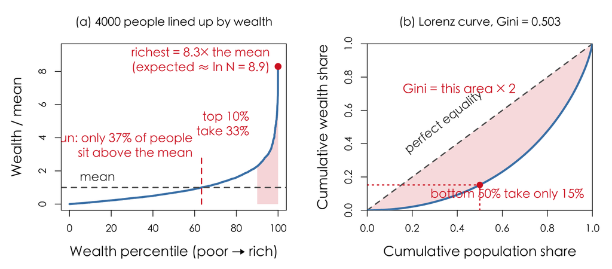

```r
ACC <- "#D62728"
u   <- sort(wa/mean(wa)); N <- length(u); pct <- (1:N)/N

par(mfrow = c(1, 2), mar = c(4.8, 5.0, 3.6, 1.6), cex.lab = 1.35, cex.main = 1.15, family = "cjk")

## (a) Line everyone up by wealth
## every annotation is computed from this run's u; the text also has discrete and continuous analytic values, which are not the same quantity
ab_mean <- mean(u > 1); top10 <- sum(tail(sort(u), round(N/10)))/sum(u)
plot(pct*100, u, type = "n", ylim = c(0, max(u)*1.12),
     xlab = "Wealth percentile (poor → rich)", ylab = "Wealth / mean",
     main = "(a) 4000 people lined up by wealth")
polygon(c(90, pct[pct >= .9]*100, 100), c(0, u[pct >= .9], 0),
        col = adjustcolor(ACC, .18), border = NA)
lines(pct*100, u, lwd = 3.2, col = "steelblue")
abline(h = 1, lty = 2, lwd = 2, col = "gray35")
segments(100*(1-ab_mean), 0, 100*(1-ab_mean), 3.0, lty = 2, lwd = 2, col = ACC)  # the vertical line's position is computed too
text(2, 1.55, "mean", col = "gray20", cex = 1.2, pos = 4)
text(62, 3.3, sprintf("this run: only %.0f%% of people\nsit above the mean", 100*ab_mean),
     col = ACC, cex = 1.2, pos = 2)
text(89, 4.6, sprintf("top 10%%\ntake %.0f%%", 100*top10), col = ACC, cex = 1.2, pos = 2)
points(100, u[N], pch = 16, cex = 1.5, col = ACC)
text(99, u[N]*1.02, sprintf("richest = %.1f× the mean\n(expected ≈ ln N = %.1f)", u[N], sum(1/(1:N))),
     col = ACC, cex = 1.2, pos = 2)

## (b) Lorenz curve: the shading is the area between the curve and the diagonal
L <- cumsum(u)/sum(u); L50 <- approx(pct, L, .5)$y
plot(NA, xlim = c(0,1), ylim = c(0,1), xaxs = "i", yaxs = "i",
     xlab = "Cumulative population share", ylab = "Cumulative wealth share",
     main = sprintf("(b) Lorenz curve, Gini = %.3f", gini(wa)))
polygon(c(pct, rev(pct)), c(pct, rev(L)), col = adjustcolor(ACC, .16), border = NA)
lines(c(0,1), c(0,1), lwd = 2, lty = 2, col = "gray35")
lines(c(0, pct), c(0, L), lwd = 3.2, col = "steelblue")
segments(.5, 0, .5, L50, lty = 3, lwd = 2, col = ACC)
segments(0, L50, .5, L50, lty = 3, lwd = 2, col = ACC)
points(.5, L50, pch = 16, cex = 1.4, col = ACC)
text(.99, .09, sprintf("bottom 50%% take only %.0f%%", L50*100), col = ACC, cex = 1.2, pos = 2)
text(.34, .53, "perfect equality", col = "gray20", cex = 1.2, srt = 38)
text(.13, .72, "Gini = this area × 2", col = ACC, cex = 1.25, pos = 4)
```

This is what that society looks like—every item below is a closed-form result for the exponential distribution, not fitted from the simulation; the figure above is just one realization of it:

- Pick two people at random: their expected wealth gap is exactly one person’s mean wealth ($E|X-Y|=\mu$, computed in the previous section). And the gap itself follows the same exponential distribution—the distance between two people looks like a third person. The Gini is just that sentence divided by $2\mu$.
- Only $e^{-1} = 36.8\%$ of people are above the mean, and that minority takes $2/e = 73.6\%$. “One-third of the people take three-quarters of the wealth” is what a Gini of 0.5 looks like day to day.
- The median is only $\ln 2 = 0.69$ times the mean. Here the mean is a systematic liar, and the size of the lie is a constant.
- The top 10% take 33%, the top 1% take 5.6%, the bottom 50% take only 15.3% ($p(1-\ln p)$). Mean wealth in the upper half is $\frac{1+\ln 2}{1-\ln 2} = 5.5$ times the lower half.
- The threshold +1 law: $E[X\mid X>q] = q+\mu$. The threshold for entering the “top 1%” is 4.6 times the mean, and the average of that group is 5.6 times—past any threshold, the people inside average one full mean more. This is memorylessness in money terms.
- To flatten it you would have to move $1/e = 36.8\%$ of all wealth (the Hoover index), and the people to move it from are exactly the 36.8% above the mean. The two 36.8% are the same $1/e$.
- Among the 4000 people, the expected richest is $H_N=$ 8.9 times the mean ($H_N=\sum_{k\le N}1/k \approx \ln N+\gamma$; $\ln N=$ 8.29, and adding Euler’s constant gives 8.9) (the richest is itself a random variable, Gumbel-like and right-skewed, with 95% of realizations falling between 7.0 and 12.0 times the mean—the upper tail is much longer than the lower, so a single realization jumping to eleven or twelve times is not anomalous). What matters is the $\ln$: however many people there are, the richest grows only logarithmically—a world with no positive feedback cannot grow a super-rich. That is why the power-law tail in the right panel above needs heterogeneity to appear at all.

So this section’s conclusion can be put in stone:

> The procedure is entirely fair (no one is favored), and the resulting Gini is still 0.5.

This is a **thermodynamic baseline of inequality**. It splits the word “fair” in two: fairness of process does not imply equality of outcome, and the maximum-entropy state carries a good deal of inequality of its own. A Gini below 0.5 means redistribution is at work; above 0.5 means positive feedback is amplifying. It is the floor of procedural fairness, not the ceiling of unfairness.

But one misreading has to be blocked at once: entropy is not fairness in the normative sense. The maximum-entropy state means only that “no one is treated specially”, which is procedural fairness—it does not answer “what distribution counts as just”. Political philosophy has plenty of other answers to that question; two of the most cited: Rawls’s difference principle says inequality is acceptable only when it also benefits the worst-off; Sen’s capabilities approach says the thing to look at is not how money is divided but what a person can actually do and become. By either standard, a maximum-entropy society with a Gini of 0.5 is nowhere near fair. Which level of inequality is acceptable is a normative question, and this model cannot answer a word of it. What this essay offers is an empirical baseline and mechanisms, not an ethical conclusion.

While we are at it, measure the thing most easily confused: this is about wealth, not income. On this island the two are very far apart—

```r
set.seed(4); Ni <- 1000; wi <- rep(10, Ni); hf <- Ni/2
wins <- c(1, 5, 20, 100, 1000)                   # how many rounds count as one "income year"
inc  <- lapply(wins, function(w) numeric(Ni)); from <- 30000 - wins
for (r in 1:30000){
  idx <- sample.int(Ni); i <- idx[1:hf]; j <- idx[(hf+1):Ni]
  pay <- wi[i] > 0; wi[i] <- wi[i] - pay; wi[j] <- wi[j] + pay
  for (k in seq_along(wins)) if (r > from[k]) inc[[k]][j] <- inc[[k]][j] + pay
}
g_inc <- sapply(inc, gini); g_w <- gini(wi)
```

| Income accounting window | Income (flow) Gini | Wealth (stock) Gini |
| --- | --- | --- |
| 1 rounds | 0.547 | 0.523 |
| 5 rounds | 0.266 | 0.523 |
| 20 rounds | 0.135 | 0.523 |
| 100 rounds | 0.063 | 0.523 |
| 1000 rounds | 0.019 | 0.523 |

The wealth Gini stays pinned at 0.52, while the income Gini slides from 0.55 all the way to 0.02. This is not noise; the two quantities have different natures. Wealth is a stock, and its distribution is a stationary property of the model, independent of how you keep the books; income is a flow, and its Gini is a function of the accounting window—the longer the window, the more the law of large numbers smooths it out, with a limit of 0. The reason is plain: in each round each person receives at most one coin, so the flow is already highly equal; wealth is the accumulation of flows over time, and random fluctuations pile up along the way and differentiate it.

This has two consequences, both important.

First (the star of this section): wealth inequality can arise with no income inequality at all. In the real world the wealth Gini (generally above 0.7) is far higher than the income Gini (mostly 0.25–0.6), usually explained as “high earners save more”; but this island shows that even with perfectly equal income and identical saving rates, wealth will differentiate anyway—all it needs is time and randomness. Income gaps are one source of wealth gaps, but not a necessary condition.

Second (used in §4.4): the model’s income prediction carries a free parameter; its wealth prediction does not. The wealth Gini 0.52 is a stationary property, with nothing adjustable in the model; but “what is the income Gini” requires first answering “how many rounds count as a year”—and this model has no calibrated time scale. So matching income to data depends first of all on that calibration assumption. Only one output can be compared directly with data: the shape of the wealth distribution.

(A note on definitions, so we do not compare the wrong numbers: this baseline is for the wealth distribution. The country Ginis quoted in the news are almost always income Ginis (mostly 0.25–0.6), while actual wealth Ginis are generally above 0.7—there the gaps come mainly from inheritance, asset returns, and leverage, positive feedbacks this model does not have. The two measures cannot be compared directly. The next section adds that “positive feedback” to the model and asks how many Gini points it is worth.)

**The correction from indivisible coins: why it is 11/21 (skippable)**

Back to the discrete version with indivisible coins. The equilibrium is the geometric distribution $P(n)=(1-q)q^{\,n}$; run the same machine again. First find the difference between two people: for $k>0$,

$$P(X-Y=k)\;=\;\sum_{n\ge
0}P(X=n+k)P(Y=n)\;=\;(1-q)^2q^{\,k}\sum_{n\ge0}q^{2n}\;=\;\frac{(1-q)^2}{1-q^2}\,q^{\,k}$$

So

$$E|X-Y| \;=\;
2\sum_{k\ge1}k\,\frac{(1-q)^2}{1-q^2}q^{\,k}
\;=\; \frac{2q}{1-q^2},
\qquad \mu=\frac{q}{1-q}$$

$$G \;=\; \frac{E|X-Y|}{2\mu} \;=\;
\frac{1-q}{1-q^2} \;=\; \boxed{\frac{1}{1+q}} \;=\;
\frac{c+1}{2c+1}$$

With $c=10$ (ten coins per person) this gives $11/21=0.524$; $c\to\infty$ gives $1/2$; $c=1$ (one coin per person) gives $2/3$—the coarser the coins, the more quantization itself manufactures inequality.

```r
set.seed(3); n <- 2e6
x <- rexp(n); y <- rexp(n)
c(`E|X-Y|/(2mu)`      = mean(abs(x - y)) / (2 * mean(x)),   # should be 0.5
  `Gamma(4) closed form`      = gamma(4.5) / (sqrt(pi) * gamma(5)), # should be 0.2734
  `Gamma(4) simulation`      = gini(rgamma(n, shape = 4)),
  `Gamma(1) closed form`      = gamma(1.5) / (sqrt(pi) * gamma(2)), # reduces to the exponential, should be 0.5
  `geometric c=10 closed form`     = 11/21,                              # island model, should be 0.5238
  `geometric c=10 simulation`     = gini(as.numeric(rgeom(n, prob = 1/11))))
```

```
##               E|X-Y|/(2mu)       Gamma(4) closed form
##                  0.4998648                  0.2734375
##        Gamma(4) simulation       Gamma(1) closed form
##                  0.2732684                  0.5000000
## geometric c=10 closed form  geometric c=10 simulation
##                  0.5238095                  0.5237975
```

## 4.3 The Same “Procedural Fairness” Can Mean a Gini of 0.5 or One Person Taking Everything

By now, “perfectly fair procedure → Gini 0.5” looks like a solid conclusion. But it hides an unstated premise: how much money each transaction moves.

This essay’s rule pools the two people’s money and splits it at random, so the amount transferred scales with the sum of their wealth. Take another rule, equally natural and closer to a real transaction: stakes in proportion—each time the two put up a fixed fraction $f$ of the poorer party’s wealth, and a fair coin decides the winner. This is the yard-sale model from the literature (Chakraborti 2002).

It still conserves the total, every bet is still a fair coin, and the rule is still identical for everyone. Watch what happens:

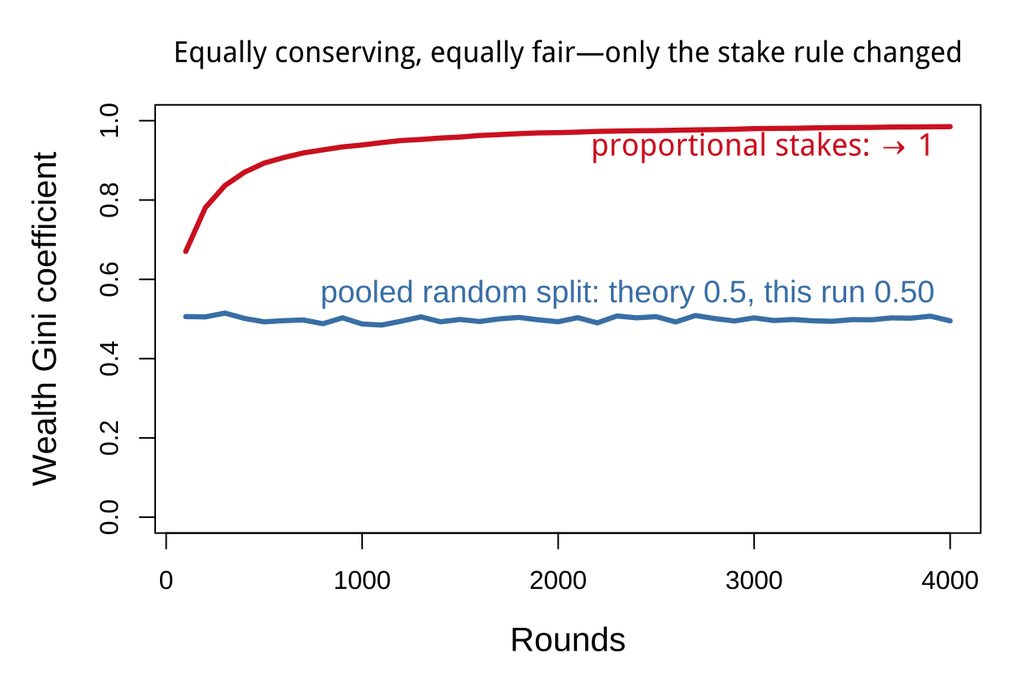

```r
N <- 2000; half <- N/2; ACC <- "#D62728"
ys <- function(f = 0.2, rounds = 4000, seed = 1){
  set.seed(seed); w <- rep(1, N); g <- numeric(0)
  for (r in 1:rounds){
    idx <- sample.int(N); i <- idx[1:half]; j <- idx[(half+1):N]
    stake <- f*pmin(w[i], w[j])                 # stake = a fixed fraction of the poorer party's wealth
    win   <- (runif(half) < 0.5)*2 - 1          # fair coin
    w[i] <- w[i] + win*stake; w[j] <- w[j] - win*stake
    if (r %% 100 == 0) g <- c(g, gini(w))
  }
  list(w = w, g = g)
}
o <- ys()
reg("yardsale", o$g[length(o$g)], "transient", "§4.3 yard_sale",
    "does not converge: it climbs without settling; this is the snapshot at round 4000")
## Control: this essay's pooled random split, equally conserving and equally fair
set.seed(1); w2 <- rep(1, N); g2 <- numeric(0)
for (r in 1:4000){
  idx <- sample.int(N); i <- idx[1:half]; j <- idx[(half+1):N]
  pooled <- w2[i] + w2[j]; e <- runif(half); w2[i] <- e*pooled; w2[j] <- (1-e)*pooled
  if (r %% 100 == 0) g2 <- c(g2, gini(w2))
}
par(mar = c(4.8, 5.0, 3.4, 1.4), cex.lab = 1.3, cex.main = 1.12)
plot(seq(100, 4000, 100), o$g, type = "l", lwd = 3.2, col = ACC, ylim = c(0, 1),
     xlab = "Rounds", ylab = "Wealth Gini coefficient", main = "Equally conserving, equally fair—only the stake rule changed")
lines(seq(100, 4000, 100), g2, lwd = 3.2, col = "steelblue")
text(4000, 0.93, "proportional stakes: → 1", col = ACC, cex = 1.2, pos = 2)
## 0.5 is the theoretical stationary baseline (analytic); the final g2 is one finite realization—show both, do not substitute one for the other
text(4000, 0.56, sprintf("pooled random split: theory 0.5, this run %.2f", g2[length(g2)]),
     col = "steelblue", cex = 1.2, pos = 2)
```

The Gini climbs to 0.985 and shows no sign of stopping: 91% of people hold less than 1% of the mean, and the top 1% hold 77%. Run it long enough and all the wealth condenses into one pair of hands. Boghosian calls this model “the inescapable casino” (Boghosian 2019).

So what does the distribution look like? That is a trick question—there is no distribution.

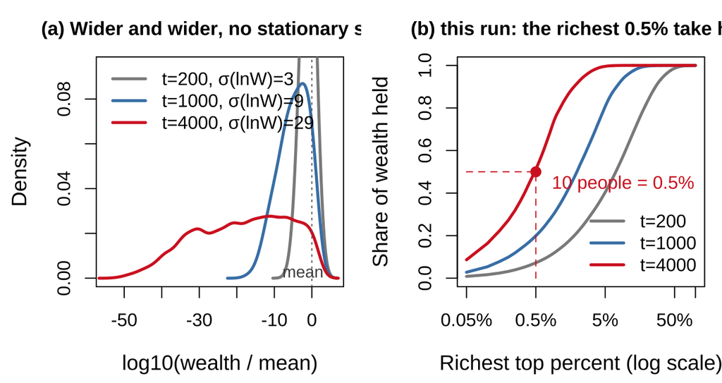

```r
## wealth distribution at three times (reuse ys() above, keeping the interim snapshots)
ys_snap <- function(f = 0.2, snaps = c(200, 1000, 4000), seed = 1){
  set.seed(seed); w <- rep(1, N); S <- list()
  for (r in 1:max(snaps)){
    idx <- sample.int(N); i <- idx[1:half]; j <- idx[(half+1):N]
    stake <- f*pmin(w[i], w[j]); win <- (runif(half) < 0.5)*2 - 1
    w[i] <- w[i] + win*stake; w[j] <- w[j] - win*stake
    if (r %in% snaps) S[[as.character(r)]] <- w
  }
  S
}
SN <- ys_snap(); snaps <- c(200, 1000, 4000)
sig <- sapply(SN, function(v) sd(log(v)))
last <- SN[[3]]; cum <- cumsum(sort(last, TRUE))/sum(last)
sci <- function(x, d = 0){ e <- floor(log10(x)); sprintf("%.*f\\times 10^{%d}", d, x/10^e, e) }
i50 <- which(cum >= 0.50)[1]; i99 <- which(cum >= 0.99)[1]

## finite-size check: grow the island from 200 to 32000 and see whether the Gini and the "half-taking few" drift with population.
## this used to be asserted in the text with no code—now it is here.
ys_n <- function(Nn, f = 0.2, rounds = 4000, seed = 1){
  set.seed(seed); w <- rep(1, Nn); h <- Nn %/% 2
  for (r in 1:rounds){
    idx <- sample.int(Nn); i <- idx[1:h]; j <- idx[(h+1):(2*h)]
    stake <- f*pmin(w[i], w[j]); win <- (runif(h) < 0.5)*2 - 1
    w[i] <- w[i] + win*stake; w[j] <- w[j] - win*stake
  }
  cu <- cumsum(sort(w, TRUE))/sum(w)
  c(gini = gini(w), half = which(cu >= 0.5)[1]/Nn)
}
FS_N <- c(200, 800, 3200, 12800, 32000)
FS   <- t(sapply(FS_N, ys_n))
reg("yardsale_fs_lo", min(FS[, "gini"]), "point", "§4.3 ys_dist", "lower bound of the Gini in the finite-size sweep")
reg("yardsale_fs_hi", max(FS[, "gini"]), "point", "§4.3 ys_dist", "upper bound of the Gini in the finite-size sweep")

par(mfrow = c(1, 2), mar = c(4.4, 4.4, 2.6, 0.8), cex.lab = 1.15, cex.main = 1.05)
COL <- c("gray55", "steelblue", ACC)

## (a) the distribution on a log scale: shifting left and widening
plot(NA, xlim = c(-55, 6), ylim = c(0, 0.095),
     xlab = "log10(wealth / mean)", ylab = "Density", main = "(a) Wider and wider, no stationary state")
for (k in seq_along(snaps))
  lines(density(log10(SN[[k]]/mean(SN[[k]])), bw = 1.6), col = COL[k], lwd = 2.6)
abline(v = 0, lty = 3, col = "gray40")
text(6, 0.002, "mean", col = "gray30", cex = 0.9, pos = 2)
legend("topleft", bty = "n", cex = 1.0, col = COL, lwd = 2.6,
       legend = sprintf("t=%d, σ(lnW)=%.0f", snaps, sig))

## (b) how much the top few percent take
plot(NA, xlim = c(0.05, 100), ylim = c(0, 1), log = "x", xaxt = "n",
     xlab = "Richest top percent (log scale)", ylab = "Share of wealth held",
     main = local({
       wl <- sort(SN[[length(SN)]], TRUE); f <- cumsum(wl)/sum(wl)
       sprintf("(b) this run: the richest %.1f%% take half", 100*which(f >= 0.5)[1]/length(wl))
     }))
axis(1, at = c(0.05, 0.5, 5, 50, 100), labels = c("0.05%", "0.5%", "5%", "50%", "100%"))
for (k in seq_along(snaps))
  lines(100*seq_len(N)/N, cumsum(sort(SN[[k]], TRUE))/sum(SN[[k]]), col = COL[k], lwd = 2.6)
segments(100*i50/N, 0, 100*i50/N, 0.5, lty = 2, col = ACC)
segments(0.05, 0.5, 100*i50/N, 0.5, lty = 2, col = ACC)
points(100*i50/N, 0.5, pch = 19, col = ACC, cex = 1.2)
text(100*i50/N, 0.44, sprintf(" %d people = %.1f%%", i50, 100*i50/N), col = ACC, cex = 1.0, pos = 4)
legend("bottomright", legend = sprintf("t=%d", snaps), col = COL, lwd = 2.6, bty = "n", cex = 1.0)
```

Strictly speaking, it has no stationary state. The left panel plots three times on a log scale: the shape always looks lognormal, but the width does not converge—$\sigma(\ln W)$ rises from 3 to 9 and then to 29, wider and wider with no sign of stopping. By $t=4000$ the poorest hold $10^{-52}$ of the mean and the richest hold $10^{2.2}$: a span of 54 orders of magnitude, with the median at $4\times 10^{-18}$ of the mean.

So the right statement is not “the stationary distribution of yard-sale is such-and-such” but: it has no stationary distribution; the only fixed point is one person holding everything, and any distribution drawn along the way is just passing through.

Why? One line settles it: win 20% then lose 20% and you are not back where you started ($1.2\times0.8=0.96$). With proportional stakes each person faces a multiplicative gamble, and its log growth rate is

$$\tfrac12\ln(1+f)+\tfrac12\ln(1-f) \;=\;
\tfrac12\ln(1-f^2) \;<\; 0$$

The expectation is fair, but every person’s time average is heading down—this is exactly the “ergodicity breaking” of Chapter 5, except that this time there is not even growth, only conservation. Money does not vanish, so it must land somewhere: apart from the one randomly produced winner, everyone else tends to zero almost surely, and conservation forces the money to pile into fewer and fewer hands. (Everyone tends to zero is a misreading—the negative log drift holds for each person, but with a finite population there is always a survivor; the fold-out in Chapter 5 gives the rigorous proof.)

This point weighs far more than “yard-sale condenses”, and deserves to be spelled out. It answers a boundary question:

> How can a procedure be fair in every single transaction and still push the outcome to one person taking everything?

The key is that “fair” does not reach as far as one imagines. It constrains a single transaction: even odds, the same rule for everyone. It does not, and cannot, constrain where those transactions go once compounded. And the three lines of arithmetic above develop exactly the middle term—what fairness guarantees is the ensemble average: at any moment every person’s expected wealth is still the mean, not a penny more or less. What is heading down is the time average: each person’s own trajectory decays almost surely. Both statements are true at once, and there is no contradiction, because the expectation is held up by a few enormous trajectories while the typical one sinks. Fairness lands on the first quantity; the life people actually live lands on the second.

Add conservation and the conclusion is locked: money does not vanish, so “almost everyone is heading down” must be settled by “someone is heading up”. Extreme inequality here is not a by-product of fairness, nor a failure at some step—it is the only settlement the conservation law permits.

> “Procedural fairness” is not a binary property, nor a moral guarantee that stands on its own. With the same “every transaction fair, the rule identical for everyone, the total unchanged”, just because fairness is placed on a different scale—a fixed amount, or a proportion of wealth—the result can be a Gini of 0.5 or one person taking everything.

> Fairness specifies how each step is taken; it does not specify where the walk ends up. The distance between the two is called time.

So the 0.5 from the island in Chapter 2 is a product of “fairness at a fixed amount”, not of “fairness” itself. For 0.5 to hold, fairness must sit on an additive scale; once the amount traded scales in proportion to wealth, the same sentence “fair” leads to the opposite outcome.

And this cannot be patched—the two rules are equally clean on procedural fairness, and neither can be pointed at and called “unfair here”. The disagreement is not about whether the rule is fair but about which scale it acts on. To get a different outcome you must set up a standard outside “fairness”, and §4.5 says on its own what that step costs.

This is the place to separate once and for all the four roads under the word “multiplicative”, because they are often lumped together and their outcomes are entirely different:

| Mechanism | Written as | Outcome | Where in this essay |
| --- | --- | --- | --- |
| multiplicative, unconstrained | W → A·W | lognormal (ln W does a random walk) | quiz option B |
| multiplicative + floor | W → A·W + B, B > 0 | power-law tail (Kesten) | a model with an exogenous floor, not used here |
| multiplicative + conservation | proportional betting between two people, total unchanged | condensation: wealth lands in very few hands | this section |
| multiplicative + pooled split | two fortunes pooled and split at random, each with independent returns | a power-law-tail fixed point with mean 1 (0 < σ < 1; other regions in Chapter 5) | returns to capital in Chapters 5 and 6 |

So the popular claim “multiplicative growth necessarily produces a power law” is wrong: purely proportional growth gives a lognormal first. To grow a Pareto tail, adding a floor term $B_t$ that pulls people back is a sufficient mechanism (Kesten), but it is not necessary—the homogeneous “pooled split” of the fourth row has no exogenous additive term and still has a power-law tail; Chapter 5 of this essay solves for its tail exponent directly. Conservation is the strangest of the four—it gives neither lognormal nor power law, but piles everything onto one person.

One practical addendum: the real economy does not condense onto one person, of course, because redistribution, wages, and bankruptcy protection—floors of various kinds—all exist at once. Add even weak redistribution back into yard-sale and the stationary state stops condensing—but the tail of that stationary state is not a power law: in Boghosian’s model with wealth advantage and redistribution, the tails on both sides of the critical point are Gaussian, and only exactly at the critical point do they degenerate to exponential (the section Another Transition: Wealth Advantage and Redistribution sets this out separately). What really turns the tail into a power law is the $\sigma$ knob of Chapters 5 and 6.

## 4.4 Then Why Is the Baseline 0.5, Not 1?

By this point a thought comes easily to mind: betting a proportion sounds like a real transaction—who does business by staking one fixed coin every time? If so, why not simply take that as the baseline and move the essay’s reference point from 0.5 to “tends to 1”?

That thought is only a small part right, and taking it apart is exactly how to say clearly how the baseline should be chosen. Four reasons, starting with the hardest.

First, the data reject it. This is not a matter of preference. What yard-sale predicts is “wealth condenses onto a very few people, and 91% of them have almost nothing”—no real society looks like that. We did not pick a convenient baseline; the data rejected the other one.

But all the data can do is reject yard-sale, not confirm 0.5. The body of the real wealth distribution is indeed exponential in shape, but the real wealth Gini is 0.83, not 0.5. So on what grounds is 0.5 still the baseline? The answer is not in the data; hold it for the fourth reason.

In between sits a result often taken as “empirical support for 0.5” that cannot be used that way. It deserves a separate accounting, but it does not affect the judgment above:

**The Empirical Result Often Cited to Back 0.5, and Why It Cannot Confirm It (Skippable)**

Drăgulescu and Yakovenko, using US tax and census data, found that the segment holding the great majority of the population is indeed exponential, with a Lorenz curve that contains no fitted parameter and a Gini coefficient of $1/2$ (Drăgulescu and Yakovenko 2001a)—but it measures individual income. The two 0.5s are numerically the same, yet they are statements about two different quantities and cannot corroborate each other. Three things must be kept apart:

1. That $1/2$ is not a second empirical result. What D-Y measured is one thing, “the distribution is exponential”; $1/2$ is its mathematical consequence—any exponential distribution, whatever its scale, has a Gini of exactly $1/2$ (§4.1 computes it). So the content of this evidence is the shape, not that number. Listing “the shape matches” and “the Gini is 0.5” as two pieces of evidence counts one thing twice.
2. D-Y’s most famous result does cross measures. Their model conserves the stock of money, while the test that “the Gini is always $1/2$” uses income flow, implicitly assuming the two are structurally similar. This step is one of the most criticized links in this literature, and Gallegati et al.’s criticism lands exactly here (Gallegati et al. 2006). This essay records it as it stands and does not defend it. One addition, though: they did test the stock side too. In the UK’s 1996 national net-worth distribution the body is likewise exponential (the figure in §2.6) (Drăgulescu and Yakovenko 2001b). But the wealth Gini computed there is 0.68, not 0.5—the power-law tail at the top lifted it. So the evidence on the stock side supports “the shape of the body” and precisely not “the Gini equals 0.5.” Which is exactly how this essay reads it: 0.5 is a baseline, not a prediction.
3. The income side of the model not only fails to confirm it; it does not match. §4.2 measured it: the island’s wealth Gini is pinned firmly at 0.52, with no adjustable term; the income Gini, by contrast, depends on “how many rounds count as a year”—1 round 0.55, 20 rounds 0.13, 100 rounds 0.06, 1000 rounds 0.02. Unless “a year” is squeezed down to just enough for one transaction, the income Gini the model produces is far below the 0.5 that D-Y measured. And the reason for the mismatch is clear enough to write down: there is no production in this model. In reality most income is wages, and wages are produced; “income” on the island is only coins passed over by someone else. A pure-exchange model should have no say about income in the first place—all it can speak to is how the stock is distributed.

Second, everyday economic activity is in fact additive. The intuition that “the stake scales with wealth” comes from investment; but the great majority of a person’s transactions are not investment, they are purchases—and prices are exogenous: being ten times richer than someone does not make you stake ten times as much on a loaf of bread. Consumption, wages, rent—the activities that make up the bulk of the everyday economy—have sizes set by external prices and do not scale with personal wealth. Proportional staking holds only on the asset side, and the asset side is the main part of wealth for only a minority.

Third, a real multiplicative gamble never runs free. The yard-sale conclusion that “everything condenses onto one person” requires no wages, no transfers, no bankruptcy protection, and a fixed proportion staked on every trade. None of these holds in reality. Put the floor back ($B_t>0$ in $W_{t+1}=A_tW_t+B_t$), and the stationary state turns at once from “condensation” into a power-law tail—which is exactly what the top of the real distribution looks like.

So taken together, the three do not offer a choice between the two; they give each one a segment to govern:

| Nature of the transaction | Who it covers | Shape it produces | Gini |
| --- | --- | --- | --- |
| Additive: the amount is set by an external price (consumption, wages, rent) | Most transactions of most people | Exponential — the body of the distribution | 0.5 |
| Multiplicative: the amount scales with your own wealth (investment, leverage, asset returns) | The main part of a few people's wealth | Power-law tail — the top of the distribution | The closer to pure multiplicative, the closer to 1 |

The real wealth distribution is exactly these two segments spliced together—and that is the final explanation of the two-segment figure in §2.6: not that two papers describe two distributions, but that two modes of transaction each rule one segment of the distribution.

The fourth reason is methodological, and the most important—it also answers the question the first reason left open.

The baseline’s job is not to be “most like reality” but to be “least assumed.” The exponential distribution is the maximum-entropy solution: given only that “the total is conserved and cannot go negative,” it is the only distribution that assumes nothing more. So 0.5 was never a prediction; it is the null hypothesis—it answers “what do you get when you know nothing else,” not “what is reality.” Rebutting it with the real 0.83 is like rebutting “the expectation of a fair coin is zero” with the takings of a real casino.

And it is precisely because it is inaccurate that it is useful. A baseline exists to be subtracted: subtract 0.5 from the real 0.83, and the remainder, 0.33, is what the mechanisms in Chapter 6 have to explain. A baseline that is “most like reality” would absorb those mechanisms into the frame of reference and make them impossible to measure again.

yard-sale fails exactly this test. It already presupposes a strong structure—the stake must be proportional to wealth. A model that presupposes a mechanism cannot serve as a baseline, because you cannot use it to measure that mechanism: with 0.5 as the baseline, “proportional staking” can be measured as an effect with a number to report; with 1 as the baseline, that effect vanishes into the frame of reference.

That is also why it appears in Chapter 4 rather than Chapter 2: it is not another setting for this island but the first mechanism to become visible after the baseline is subtracted—the whole multiplicative family in Chapter 6 is its kin.

## 4.5 Procedural and Outcome Fairness: Their Aims and Their Costs

The two terms are often used interchangeably, but they want two different things and their costs are entirely different. The numbers this essay computes can fill in the price tag on each side.

**Procedural fairness**—the rules are identical for everyone to the letter, unbiased, and auditable.

- Aim: to rule out favoritism. Its great advantage is that it does not require knowing the outcome in advance: you inspect the rules themselves and need not observe who ends up with how much. That makes it verifiable fairness.
- Cost: you must accept a nonzero base of inequality. This entire essay is that price tag—a Gini of 0.5, only 37% of people above the mean line and they take 74%, the bottom half takes 15%, the richest person holds $\ln N$ times the mean. And this is not the result of weak enforcement; it is exactly what procedural fairness looks like when taken to its limit.

**Outcome fairness**—to hold down the dispersion of the terminal distribution.

- Aim: to keep the distribution itself from being too spread out. It is observable (the Gini coefficient is its reading), but it cannot be verified from the rules—you have to keep watching the outcome.
- The cost comes as one of two options, and this essay has measured both:
  1. Continuous intervention. Tax every round, rebate per capita: the direction is right, but the cost is steep—it takes $\tau = 0.4$ to push the Gini down by any large amount (that number is computed on the spot in §6.3). Note that the $1/3$ reported there is measured after one more random exchange, not the floor of redistribution itself: at $\tau=1$ the Gini immediately after redistribution is 0, and one round of exchange pushes it back to $1/3$. More important, this is not a one-time operation but a permanent maintenance cost: stop, and it slides back to 0.5.
  2. Different rules for different people. Let the saving propensity, the rate of return, or the inheritance rule vary across people—this can push the Gini in any direction, but it destroys procedural fairness at the same time, and the direction it pushes often goes the other way: heterogeneous saving pushes the Gini from 0.5 to 0.758, heterogeneous returns push it higher—Chapter 5 will measure by how much.

Where the conflict actually lies. Procedural fairness requires homogeneous rules; outcome fairness requires adjusting to outcomes, and adjusting to outcomes means the rules differ for people in different states—taxation is the mildest form of such “different rules.” But stop there; do not turn the point into a universal theorem. Homogeneous rules can also push the Gini arbitrarily low—the $w\mapsto(1-\tau)w+\tau\bar w$ in §5.10 is identical for everyone and conserves the total, yet multiplies the Gini by exactly $1-\tau$. So the real trade-off is not on the axis of homogeneous versus heterogeneous rules but in the transfer rule itself: the pure-exchange rule in this chapter contains no restoring force, so its resting point is 0.5; to change the resting point you must change the rule, but changing the rule need not cost you homogeneity.

But the two terms together still miss one thing, and it may be the thing people care about most. Both procedural fairness and outcome fairness measure a cross-section at a single moment—whether the rules are homogeneous at this instant, how spread out the distribution is at this instant. Neither says whether the same person will still be in that position next year.

This is not nitpicking: the three lines of inheritance rules in §6.2 will measure it—the Gini and class mobility can move in opposite directions—partible inheritance pushes the Gini down and mobility up, while random-heir inheritance pushes the Gini up and class mobility up with it. So “outcome fairness” is not a sufficient term: it governs the cross-section, not whether positions change hands.

That is a third quantity, and the next section is entirely about it.

## 4.6 The Same Gini, Two Completely Different Worlds

A sentence left at the end of Chapter 1 can now be cashed: the Gini coefficient cannot tell “the rises and falls of one person’s life” from “different people fixed in different positions.” That is not rhetoric; it can be laid out directly.

Build two worlds with identical wealth distributions—both exponential with the same mean, both with a Gini of 0.5:

- World A (mobile): this essay’s island. Every round, randomly paired exchange, run for many generations.
- World B (hereditary): wealth is drawn once at birth from the same exponential distribution, no transaction ever occurs afterward, and it passes to the next generation unchanged.

```r
set.seed(7); N <- 4000; half <- N/2
## World A: pure exchange, 8 generations of 200 rounds each
wA <- rep(1, N); rhoA <- c(); prev <- NULL
for (g in 1:8){
  for (r in 1:200){
    idx <- sample.int(N); i <- idx[1:half]; j <- idx[(half+1):N]
    pooled <- wA[i] + wA[j]; e <- runif(half); wA[i] <- e*pooled; wA[j] <- (1-e)*pooled
  }
  if (!is.null(prev)) rhoA <- c(rhoA, cor(prev, wA, method = "spearman"))
  prev <- wA
}
## World B: one draw at birth, nothing moves afterward
wB <- rexp(N); rhoB <- 1                       # position never changes, so the rank correlation is identically 1
c(`A Gini` = gini(wA), `A intergenerational rank correlation` = mean(rhoA),
  `B Gini` = gini(wB), `B intergenerational rank correlation` = rhoB)
```

```
##                               A Gini A intergenerational rank correlation
##                          0.508871894                         -0.002416045
##                               B Gini B intergenerational rank correlation
##                          0.501974254                          1.000000000
```

| World | Wealth distribution | Gini coefficient | Intergenerational rank correlation | This society is |
| --- | --- | --- | --- | --- |
| A: reshuffled every generation | Exponential | 0.509 | -0.00 | Everyone takes a turn at being poor and rich |
| B: fixed for life at birth | Exponential (the same one) | 0.502 | 1.00 | Poor and rich are fixed from the day you are born |

The two worlds have the same Gini coefficient, but they are two different things. In A, the exponential curve is one person’s life spread out flat—that is what the ergodicity figure in Chapter 2 draws: follow any one person long enough, and his experience reproduces the distribution of the whole society. In B, the same curve is a birth list: whichever cell you are in, you stay in for life, and your children stay in it too.

The Gini coefficient cannot separate the two, because it reads only the cross-section. It flattens the time dimension entirely. And what people really care about is often exactly that flattened dimension—not “how big is the gap” but “will the gap land on me, and can I get out.”

So a second quantity is needed. But there is a fork here, and the rest of this section stays on it: the “second quantity” is really two, and they can come completely unhooked.

### 4.6.1 The Second Quantity Is Really Two

Unfold the dimension that got flattened, and it turns out to hold two different things:

- **Intergenerational class mobility**: whether the parents’ position predicts the child’s. World B is its extreme—the rank correlation between father’s and son’s position is always 1, and mobility is zero.
- **Intragenerational class mobility**: whether the same person, some time later in life, is still in the same position. World A is its extreme—positions change every day.

What matters is that the two can move independently. High intergenerational mobility does not guarantee that a person rises and falls within a lifetime: it may instead be that every generation draws lots afresh, and each person, once drawn, stays put for life. The reverse holds too. So a society can be both hereditary and turbulent—positions never change hands, and yet daily life stays insecure. This is not a theoretical possibility: the JPMorgan Chase Institute, using millions of anonymized accounts, measured that households at the median income see their monthly income move by about 36%, a rate that has held steady for years, while low-income households see larger and more frequent drops (Farrell et al. 2019).

Economics has five tools for measuring this dimension, but nearly all of them sit on the intergenerational side:

| Measure | Dimension | What it measures | Main problem |
| --- | --- | --- | --- |
| Rank–rank slope | Intergenerational | regression slope of the child's percentile rank on the parent's percentile rank | depends on how the reference group is drawn; sees only ranks, not overall growth |
| Intergenerational elasticity (IGE) | Intergenerational | elasticity β of ln(child income) on ln(parent income) | requires a logarithm, so anyone with zero income must be dropped—and those are exactly the people who most need counting |
| Transition matrix | Intergenerational | P(child in top quintile \| parent in bottom quintile) | the bins are arbitrary; one cell on its own throws away the rest of the matrix |
| Absolute mobility | Intergenerational | share of children whose income exceeds their parents' | mixes growth with distribution; it has to be decomposed before use |
| Income volatility | Intragenerational | permanent/transitory components in the variance of one person's income over several years | needs individual-level panel data, the heaviest sample requirement |

Four to one. Of the four intergenerational measures, cross-society comparisons should use the rank–rank slope—it takes no logarithm, so people with zero or negative income still count (Chetty et al. 2014); intergenerational elasticity is best not used alone, since the number moves as soon as the truncation rule does. Only the last measure points within a generation: Gottschalk and Moffitt split the variance of individual income into a permanent component (long-run position) and a transitory component (year-to-year swings) (Gottschalk and Moffitt 2009).

With this vocabulary, the two worlds that opened this section can be put cleanly: the cross-sectional variance is the same, while the permanent/transitory mix is exactly reversed—World B is all permanent component, World A all transitory.

A cross-country fact bears witness that the two must be read together. Put each country’s Gini coefficient on the horizontal axis and its intergenerational elasticity on the vertical axis, and the points line up along a clearly rising line: the more unequal a country, the lower its intergenerational mobility. The observation comes from Corak (Corak 2013), and Krueger later named it the “Great Gatsby curve”:

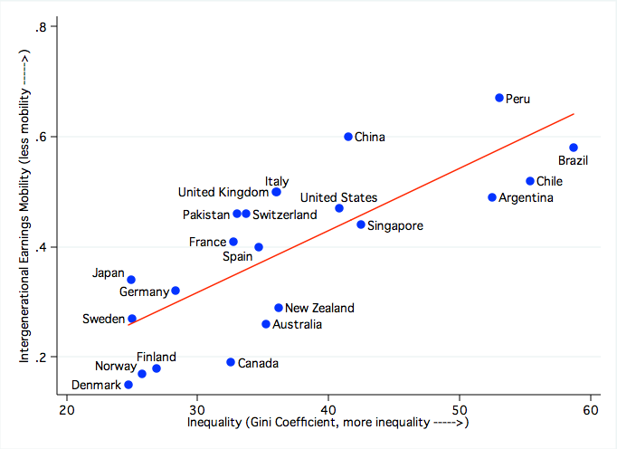

The Great Gatsby curve (22 countries). The horizontal axis is income inequality; the vertical axis is the intergenerational income elasticity. Image source: [Miles Corak](https://milescorak.com/2017/06/26/the-great-gatsby-curve-and-the-world-bank/), copyright remains with the original author.

Note that it measures the intergenerational branch—so it can say precisely nothing about the intragenerational branch. As for whether this essay’s model lines up with the curve, we will settle accounts once §6.2 has measured the inheritance rule.

This essay’s accounting for the two quantities, in one pass. The intergenerational branch is done (the three lines of inheritance rule in §6.2); the intragenerational branch is done too (the rank-rank correlation of §7.1). Only the permanent/transitory decomposition of income is missing—and by the analysis above, that is exactly the one that would best match this section’s two worlds. The reason is not that it is troublesome, but that this model has no standing to do it: the island has no production, so it cannot supply an income stream with a determinate time scale. §7.2 sets out that boundary.

### 4.6.2 So Is More Mobility Always Better?

Everything so far has been at the level of fact. But the real question is the next one: is high class mobility a good thing?

The most intuitive answer is “of course.” But something that does not belong has been smuggled into that “of course.”

Over the past few decades, incomes around the world have generally risen. So the word “movement” has come to mean upward by default: children doing better than their parents, this generation stronger than the last. But that is absolute mobility—it measures whether “life is getting better,” and the reason it can be broadly positive is growth, not the reshuffling of ranks. In the United States that number fell from about 90% for the 1940 birth cohort to about 50% for the 1980s cohort (Chetty et al. 2017), and what fell was mostly growth and distribution, not who traded places with whom.

Class mobility is not that; it is zero-sum. Rank is a permutation: if someone goes up, someone must come down, no more and no fewer. The rank changes in a society sum to exactly zero—not an empirical regularity, but a definition. So “high mobility” never means “everyone is moving up”; it means only “more people are moving up and more are moving down.”

Is up symmetric with down, then? Strictly symmetric in rank, asymmetric at every other point:

- Asymmetric in wealth terms. The distribution is right-skewed, and the top decile is much wider than the bottom decile. For the same one-decile step, what you gain at the top is far more than what you lose at the bottom.
- Nor is stickiness symmetric, and it depends on the mechanism. §7.1 will break this $\rho$ down by decile: the same mobility reading can mean “equally stuck at both ends” or “the top locked shut while the bottom still changes hands.”
- Asymmetric in this essay’s model too. 0 is a wall: there is a floor below, no ceiling above.
- Asymmetric in how it feels, most of all. The pain of falling is generally greater than the pleasure of an equally large climb.

So “mobility is high” does not say the same thing to a person already at the top and a person at the bottom. That is also why it cannot be treated as a score in which bigger is better.

Back to the two branches. For the intergenerational branch, “more mobility is better” largely holds: if a position can be predicted from the parents, the predictive power comes from transmitted wealth rather than from the person—the children of the poor should have a chance to rise, and those who hold high positions on birth alone should fall. There is little dispute on this branch.

But carry the same sentence over to the intragenerational branch and it fails at once. A person whose position never stops changing within a lifetime may be lucky (he has a chance to turn things around) or unlucky (nothing he does counts, and position is decided by noise alone). Conversely, a position that does not move for decades is not necessarily bad: if a person really is more capable, his staying at the top is no problem.

So “is mobility high?” is not a usable question on its own. It says only whether positions change hands, not what positions actually track. And good or bad hangs on that second question: if positions track ability, their persistence is defensible; if they track luck, their persistence merely freezes noise in place.

And for that word “defensible,” the smoothest defense is “the capable deserve more”—that road does not work. It has to face a hard objection head-on: ability is itself the result of a draw—genes, family, era, which industry you happened to bet on. That being so, why should wealth that came by luck be called “undeserved,” while wealth that came by ability is taken as its just reward? Both are initial conditions no one chose.

This objection is fatal to “desert,” and it is precisely why this essay takes another road. That road goes around “desert” and asks one thing only: in whose hands do resources produce more?

A word on where this question comes from, so it does not read as this essay’s own invention.

First, “ability given does not guarantee success” can be computed. Pluchino and coauthors built a model: talent follows a normal distribution $N(0.6,\,0.1)$, capital evolves multiplicatively, and lucky and unlucky events are scattered in at random. The result is Gaussian talent with power-law success—across ten thousand runs, the mean talent of the most successful person is 0.667—above the population mean 0.6, but only 0.67 population standard deviations above it, far too little to explain the most successful as the most talented. What the original emphasizes is exactly this rightward shift: talent really is enriched among the winners, only shallowly. There are numbers at the other end too: among people with talent above 0.7, only one-third end up above their initial capital (Pluchino et al. 2018). Talent is a necessary but not sufficient condition for success. One definitional point must be stated: they have exogenous lucky events and multiplicative capital, while this essay has conserving exchange—not the same model; but both point at the same thing: even with ability given, success does not follow ability.

Second, the objection that “ability is drawn by lot” has a fifty-year tradition of treatment in economics. The equality-of-opportunity literature divides what determines outcomes into circumstance (not the individual’s responsibility) and effort (the individual’s responsibility), and the difficulty is exactly that the two cannot be separated in the data. Roemer’s move is worth pointing out: rather than trying to tell effort from endowment, he defines effort by “a person’s rank within his own type”—on the grounds that “the shape of the distribution within a type is itself a circumstance” (Roemer and Trannoy 2015). That is the same move as this essay’s use of rank correlation to measure mobility: do not ask about a person’s absolute level, only about where he ranks among his own group.

Once the question is put this way, whether ability is drawn by lot stops being a problem at all. Whether a person’s ability is innate, cultivated, or purely a matter of luck has no bearing on output—ability that came from a draw still produces. So the distinction between luck and ability matters not for desert:

> People instinctively recoil from “virtue out of keeping with position”—more precisely, talent out of keeping with position. Under that intuition sits a factual judgment: ability is a signal about output, luck is not; if position were generated by luck alone, and resources still stayed there, overall output would be depressed. The judgment that looks most like morality has in fact been speaking for efficiency all along.

So this essay does not discuss desert, only one measurable thing: whether position carries information.

The weight of this road must be stated once and for all. The sentence above—“ability is a signal about output, luck is not”—is a conceptual premise that comes with the question: it defines what “ability” means on this road, and it is not a finding of this essay, since the island has no production and cannot measure anyone’s output. The sentence “overall output would be depressed” is likewise a premise, not a conclusion—it says why the road is worth taking, not a number this essay computed. And actually measuring “how much information about ability a rank carries” would need a joint statistic of wealth and ability, which this essay also does not compute (§7.2 explains why). So this section does one thing only: put forward the criterion, and explain why it is easier to discuss than “desert.” As for “why a configuration with more information produces more output,” that needs a production model that can compute output directly; it is the main subject of the companion essay, *Fairness and Efficiency: The Same Temperature*.

One more thing worth spelling out, which this essay proved long ago but never made explicit: on the island of Chapters 2 through 4, everyone’s ability is exactly the same—and the Gini is still 0.5. That is not rhetoric but an identity: rank cannot carry information about something the model never included. (Pluchino and coauthors ran into the same kind of phenomenon from the other direction: talent is Gaussian, wealth is a power law, and the most talented almost never reach the summit (Pluchino et al. 2018). That is another stylized model and does not validate this essay’s setup.)

Following the thread of “information,” the directions of the two quantities stop being parallel: they are two applications of one criterion—but they point opposite ways. They have to be written as conditional propositions, because the assumptions they rest on are not conclusions of this model:

- Intergenerational: *if* (i) the child’s ability is independent of the parent’s ability, *and* (ii) the parent’s position affects the child’s position only through transmitted wealth (the model contains no other channel of origin—education, health, networks, community), *then* a low rank-rank correlation means that position is less determined by origin.
- Intragenerational: *if* (i) a person’s ability is roughly fixed over the period examined, *and* (ii) the comparison concerns mean-preserving exogenous risk, with lifetime resources and opportunity sets fixed and individuals risk-averse, *then* a low transitory component means that position is less determined by random shocks.

None of these four “ifs” is proved by the model; they are assumptions added from outside. Drop any one and the direction can reverse—if origin also worked through education, for instance, then “low rank-rank correlation” would no longer be equivalent to “position less determined by origin.”

The three quantities therefore each have their own reading:

| Quantity | What it measures | When it is preferable |
| --- | --- | --- |
| Intergenerational rank-rank correlation | how much the parent's position predicts the child's position | under the two intergenerational assumptions above, a low value means position is less determined by origin |
| Intragenerational transitory component (this essay does not decompose it, only draws an analogy on wealth ranks—see §7.2) | the part of a person's year-to-year income that rises and falls at random | under the two intragenerational assumptions above, a low value means position is less determined by random shocks |
| Intragenerational permanent component | the persistent part of a person's income | neither good nor bad in itself—it says only that positional differences are persistent, not where the persistence comes from |

The third row needs special care: its goodness or badness does not follow from the first two. To say that “the value of the permanent component depends on the intergenerational measure” is an unwarranted implication—the two measure different things on different generational structures. This essay does not claim such a dependence.

To close. What this section has answered from beginning to end is under what conditions one thing is preferable, not why it is better. The first this essay can supply; the second must wait for a production model.

# 5 How Bad Can It Get? Calculating the Phase Transition

The baseline holds: the procedure is perfectly fair, and the Gini coefficient of the outcome is 0.5. And §4.3 has already given the other end: every transaction still fair, only the stake changed to a proportional one, and wealth condenses all the way into a single pair of hands.

So the question “how bad can it get” seems to have an answer already—the worst case is 1. But that answer is degenerate. Yard-sale has no steady state and no knob to turn: it has one endpoint and no road. You cannot ask “how far must it be pushed before something breaks”, because it has exactly one behavior from beginning to end, and the only difference is how long you run it.

What really needs asking is something else: is there a whole family of steady states? Is there a parameter that can be turned continuously? And where does the behavior suddenly change character? The island of Chapters 2 through 4 can supply none of this—zero-sum additive exchange has one fixed equilibrium, the exponential distribution, and whether it is ten thousand coins per head or a hundred, the shape is that one curve. With no adjustable parameter there is no “how far”, and certainly no phase transition.

So this chapter swaps in a different model and fits it with a knob: coins earn interest, and the rate is random. Expected return is the same for everyone; only what actually arrives fluctuates—the size of that fluctuation is the knob, written $\sigma$ throughout this chapter. Everything other than the knob is carried over from the continuous “pool and split” variant of Chapter 3—two people meet, pool their wealth, and split it at random; not the Chapter 2 island’s “one coin per transaction”. The two are different exchange kernels, and the distinction will matter again when we compare with yard-sale.

## 5.1 The Answer, Up Front

Here are the results this chapter computes; the sections that follow take them apart one by one.

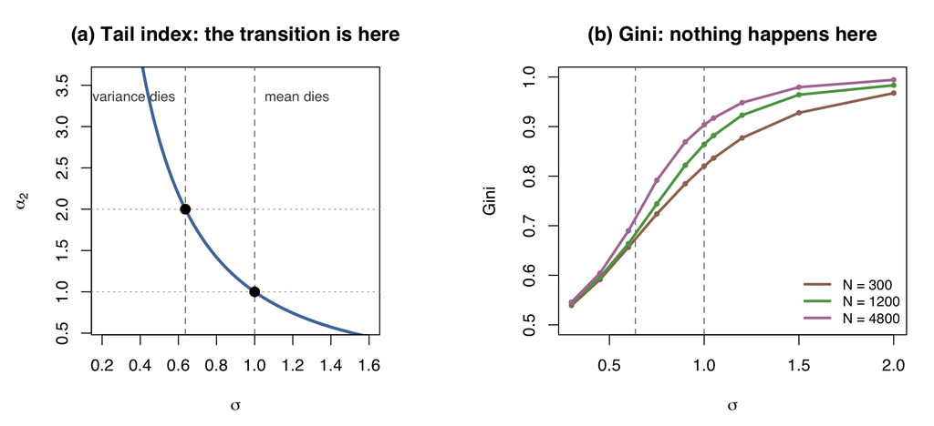

```r
## Left panel: the analytic tail-index curve.
## Right panel: the Gini on the same σ axis—three population sizes, to show why it cannot serve as the criterion.
.af_blue <- "#4E79A7"; .af_acc <- "#D62728"
par(mfrow = c(1,2), mar = c(4.6,4.6,3.4,4.4), family = "sans")
.af_sg <- seq(0.2, 1.6, length.out = 300)
.af_al <- vapply(.af_sg, alpha2, numeric(1))
plot(.af_sg, .af_al, type = "l", lwd = 3, col = .af_blue, ylim = c(0.6, 3.6),
     xlab = expression(sigma), ylab = expression(alpha[2]),
     main = "(a) Tail index: the transition is here")
abline(v = c(sigma_c_var, sigma_c_mean), lty = 2, col = "gray45")
abline(h = c(2, 1), lty = 3, col = "gray70")
points(c(sigma_c_var, sigma_c_mean), c(2, 1), pch = 19, cex = 1.3)
text(sigma_c_var, 3.35, "variance dies", col = "gray30", cex = 0.85, pos = 2)
text(sigma_c_mean, 3.35, "mean dies", col = "gray30", cex = 0.85, pos = 4)
## A right-hand axis showing "how much the top 1% holds", converted with the pure-Pareto p^(1-1/α), used to hang here. Removed:
## that formula requires the whole distribution to be Pareto, and here only the tail is; plugging it in mechanically at α<1 gives
## shares above 100% (215% at σ=1.1), which shows its domain has already ended. The intuitive reading now comes from the simulated values.

par(mar = c(4.6,4.6,3.4,1.4))
.af_N <- c(300, 1200, 4800); .af_col <- c("#9C755F", "#59A14F", "#B07AA1")
plot(NA, xlim = range(sigs), ylim = c(0.5, 1), xlab = expression(sigma), ylab = "Gini",
     main = "(b) Gini: nothing happens here")
abline(v = c(sigma_c_var, sigma_c_mean), lty = 2, col = "gray45")
## Run once and keep both readings: the Gini for the right panel, the top 1% share for the plain-language reading in the text.
.af_stat <- lapply(.af_N, function(N)
  sapply(sigs, function(sg) rowMeans(sapply(1:6, function(sd) one(sg, sd, N = N)))))
.af_G <- lapply(.af_stat, function(M) unname(M["gini", ]))
for (k in seq_along(.af_N)) {
  lines(sigs, .af_G[[k]], col = .af_col[k], lwd = 2.6)
  points(sigs, .af_G[[k]], col = .af_col[k], pch = 19, cex = 0.6)
}
legend("bottomright", sprintf("N = %d", .af_N), col = .af_col, lwd = 2.6, bty = "n", cex = 0.85)
```

```r
## The Gini at the critical setting drifts with population; the subcritical setting drifts too—so drift is not a signal of a phase transition.
.af_ic <- which(sigs == sigma_c_mean); .af_i9 <- which(sigs == 0.9)
for (k in seq_along(.af_N)) {
  reg(paste0("G_at_crit_N", k), .af_G[[k]][.af_ic], "mean", "§5.1 answer_fig",
      sprintf("Gini at sigma=1, N=%d", .af_N[k]))
  reg(paste0("G_at_sub_N", k), .af_G[[k]][.af_i9], "mean", "§5.1 answer_fig",
      sprintf("Gini at sigma=0.9, N=%d", .af_N[k]))
  reg(paste0("G_N", k), .af_N[k], "derived", "§5.1 answer_fig", "population setting of the Gini panel")
}
for (nm in c("09","10","12")) {
  .af_i <- which(abs(sigs - as.numeric(paste0(substr(nm,1,1), ".", substr(nm,2,2)))) < 1e-9)
  reg(paste0("top1_s", nm), .af_stat[[3]]["top1", .af_i], "mean", "§5.1 answer_fig",
      sprintf("top 1%% share at sigma=%.1f, N=4800, 6 seeds", sigs[.af_i]))
}
## The Gini rises monotonically in σ and has no readable kink. It saturates toward 1, so the linear correlation is not close to 1—
## what needs checking is monotonicity, via rank correlation; with 6 seeds, small reversals between adjacent settings are allowed.
stopifnot(.af_G[[3]][length(sigs)] - .af_G[[3]][1] > 0.3,
          cor(sigs, .af_G[[3]], method = "spearman") > 0.98,
          all(diff(.af_G[[3]]) > -0.01))
```

The control parameter is $\sigma$, not the Gini. The curve in the left panel is the fixed point’s tail index $\alpha_2(\sigma)$—the heavier the tail, the smaller it is. Once $\alpha_2$ falls below 2 there is no variance; below 1, no mean.

For a plain-language reading, use the simulated “how much the top 1% holds”: at $\sigma=0.9/1.0/1.2$ it is 49% / 57% / 70%.

**Detail: why this share cannot be converted from the tail index (skippable)**

Note that this cannot be converted from $\alpha_2$: the power-law formula $p^{1-1/\alpha}$ requires the whole distribution to be Pareto, and here only the tail is—plugged in mechanically at $\alpha_2<1$ it even returns a “share” above 100%. $\alpha_2$ governs the weight of the tail, not the share of any segment of the population.

The quantity that really jumps is “can the mean survive the limit”. For $\sigma<1$ it can: the iteration converges to a distribution with mean 1, and wealth has a typical scale. For $\sigma\ge1$ it cannot: the wealth of a randomly picked person concentrates toward zero, while the average stays at 1—held up by an ever rarer, ever larger few. This “can / cannot” is the order parameter of this chapter, and it drops from 1 to 0 at $\sigma=1$. (The ice-water analogy: $\sigma$ is the temperature, and this quantity is the solid fraction.)

And so the locations of the four limits come out of the calculation:

- The first, the description of collapse. In two steps: $\alpha_2$ falls below 2, variance no longer exists, at $\sigma=0.63676$; then below 1, and the mean no longer exists either, at $\sigma=1$. The two boundaries are one curve crossing two integers, not two theories.
- The second, individual sinking. The typical individual goes to zero while the ensemble mean does not move—exactly the order parameter above dropping to 0. At $\sigma=1$.
- The third, collective exit. The population fraction needed to hold a fixed share of wealth goes to zero. The same location, $\sigma=1$.
- The fourth, exchange freezing. It does not exist in this model. Wealth is continuous and every pair transacts unconditionally, so there is no such thing as “cannot pay”. It belongs to another axis (the scarcity of coins), which is set out separately below.

(Which band of the Gini do these four fall in? There is a signpost table at the end of this section.)

So the four are not four events in sequence: the first half of the first arrives earlier ($\sigma\approx0.64$), then the second half of the first, the second, and the third all sit at $\sigma=1$—one and the same condition triggers them together; the fourth is not on this axis at all.

As for the Gini, the right panel is its entire answer: nothing happens. At both vertical lines the curve passes through smoothly, with no kink and no jump. Worse, the three curves separate from one another—at the same $\sigma$ the Gini drifts with population size (at $\sigma=1$, 0.82 / 0.86 / 0.90, for N = 300 / 1200 / 4800). And the subcritical $\sigma=0.9$ drifts as well (0.78 / 0.82 / 0.87), so the drift cannot be read as “approaching condensation”—it is present on both sides.

> These Gini readings, from finite populations over finite time, cannot locate the critical point, and they give no universal “critical Gini”.

Is there a quantity that is both intuitive and actually carries the fingerprint of the transition? There is one that comes close: how many people hold half the wealth.

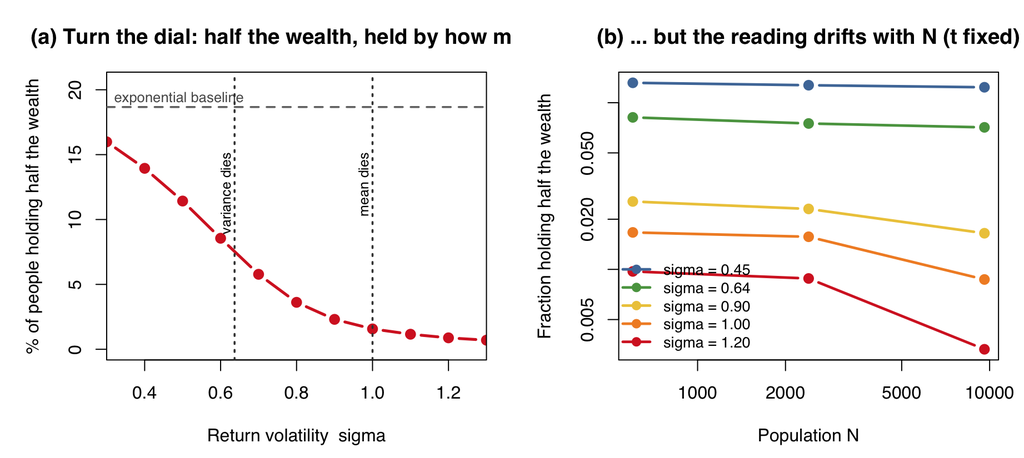

```r
## The population fraction needed to hold half the wealth. In theory: when alpha2>1 (finite mean) it converges to a positive constant;
## when alpha2<1 it tends to zero under the population-first, time-second order. The figure below is population sensitivity at fixed time, not that asymptotic limit.
p_half <- function(w){ v <- sort(w, decreasing = TRUE); which(cumsum(v) >= 0.5*sum(v))[1]/length(v) }
PH_ROUNDS <- 1000                       # time horizon of this figure; the note on definitions in the text cites it
## The exponential baseline is analytic: top-p share = p(1 - log p); set it equal to 1/2.
.ph_exp <- uniroot(function(x) x*(1-log(x)) - 0.5, c(1e-6, 0.5), tol = 1e-12)$root
reg("p_half_exp", .ph_exp, "analytic", "§5.1 p_half_scaling", "population fraction holding half the wealth under the exponential baseline")
.ph_N <- c(600, 2400, 9600); .ph_sg <- c(0.45, sigma_c_var, 0.9, sigma_c_mean, 1.2)
## 90 independent tasks (3 N x 5 sigma x 6 seeds), flattened and run in parallel in one go.
## one_w() sets its own seed, so results are bit-identical to serial; rows=sigma, columns=N as before.
.ph_grid <- expand.grid(sd = 1:6, sg = seq_along(.ph_sg), N = seq_along(.ph_N))
.ph_raw <- unlist(parallel::mclapply(seq_len(nrow(.ph_grid)), function(k)
  p_half(one_w(.ph_sg[.ph_grid$sg[k]], .ph_grid$sd[k],
               N = .ph_N[.ph_grid$N[k]], rounds = PH_ROUNDS)), mc.cores = .PAR))
.ph <- matrix(apply(matrix(.ph_raw, nrow = 6), 2, mean), nrow = length(.ph_sg))
for (k in seq_along(.ph_sg))
  reg(paste0("p_half_s", k), .ph[k, 2], "mean", "§5.1 p_half_scaling",
      sprintf("population fraction holding half the wealth at sigma=%.4f, N=2400", .ph_sg[k]))
## (a) Intuitive reading: turn only sigma, with population and rounds fixed. 11 settings x 6 seeds, one parallel batch.
.ph_sg2 <- seq(0.3, 1.3, by = 0.1)
.ph_g2  <- expand.grid(sd = 1:6, sg = seq_along(.ph_sg2))
.ph_r2  <- unlist(parallel::mclapply(seq_len(nrow(.ph_g2)), function(k)
  p_half(one_w(.ph_sg2[.ph_g2$sg[k]], .ph_g2$sd[k], N = .ph_N[2], rounds = PH_ROUNDS)),
  mc.cores = .PAR))
.ph2 <- colMeans(matrix(.ph_r2, nrow = 6))
stopifnot(.ph2[1] > .ph2[length(.ph2)],
          cor(.ph_sg2, .ph2, method = "spearman") < -0.95)

PHC <- c("#4E79A7", "#59A14F", "#EDC948", "#F28E2B", "#D62728")
par(mfrow = c(1, 2), mar = c(4.6, 5.0, 3.4, 1.2), family = "sans")
plot(.ph_sg2, 100*.ph2, type = "b", pch = 19, lwd = 2.6, col = "#D62728",
     ylim = c(0, 100*max(.ph_exp, max(.ph2))*1.1), xaxs = "i",
     xlab = "Return volatility  sigma", ylab = "% of people holding half the wealth",
     main = "(a) Turn the dial: half the wealth, held by how many?")
abline(h = 100*.ph_exp, lty = 2, lwd = 1.8, col = "gray45")
text(0.32, 100*.ph_exp, "exponential baseline", adj = c(0, -0.5), cex = 0.8, col = "gray35")
abline(v = c(sigma_c_var, 1), lty = 3, lwd = 1.8, col = "gray25")
text(sigma_c_var, 100*max(.ph2)*0.95, "variance dies", srt = 90, adj = c(1, -0.4), cex = 0.78)
text(1, 100*max(.ph2)*0.95, "mean dies", srt = 90, adj = c(1, -0.4), cex = 0.78)

## (b) The same quantity against population size—to show why it cannot locate the critical point.
matplot(.ph_N, t(.ph), type = "b", pch = 19, lty = 1, lwd = 2.4, log = "xy",
        col = PHC, xlab = "Population N", ylab = "Fraction holding half the wealth",
        main = "(b) ... but the reading drifts with N (t fixed)")
legend("bottomleft", sprintf("sigma = %.2f", .ph_sg), col = PHC,
       lwd = 2.4, pch = 19, bty = "n", cex = 0.85)
```

```r
## The two subcritical settings stay roughly flat; the supercritical one keeps sliding—this is a test of trend, not a location of the critical point.
stopifnot(.ph[1,3]/.ph[1,1] > 0.8, .ph[5,3]/.ph[5,1] < 0.5,
          .ph[1,3]/.ph[1,1] > .ph[5,3]/.ph[5,1])
```

The left panel is this chapter’s knob figure, only with the vertical axis changed to a quantity anyone can weigh. The horizontal axis is still $\sigma$; the vertical axis is “the richest few percent hold half the island’s wealth”. The dashed line is the exponential baseline: with a perfectly fair procedure and no return fluctuation, 19% of people hold half. Turn the knob right and the line falls all the way—at the variance boundary only 8% are left holding half, and at $\sigma=1$ only 2%. The two vertical lines are the two boundaries computed above.

This is the plain-language version of “how bad can it get”: every transaction still fair, only the return fluctuation turned from zero to 1, and the number holding half the wealth falls from 19 in a hundred to 2 in a hundred.

But it can only give intuition; it cannot locate the critical point—the right panel is the reason.

**What the right panel says: this quantity drifts with population, so it cannot serve as the criterion (skippable)**

The right panel changes the horizontal axis: fix $\sigma$ and the number of rounds, raise the population from 600 to 9600, and watch where the fraction goes. Two kinds of behavior: the small-$\sigma$ lines barely move, the large-$\sigma$ lines keep sliding. That sounds like a criterion—“does it shrink with population” separates the two phases.

Unfortunately, it is not. $\sigma=0.9$ belongs in theory to the side that “should converge to a constant”, yet the measurement is still sliding at the largest population run; this essay does not attribute that gap (it may be slow convergence, or fixed time may simply not be where that limit should be read). Feasible population sizes cannot separate 0.9 from 1.0.

And “the fraction shrinks without bound” should not be the behavior at fixed time anyway: at any fixed moment the infinite-population limit distribution has mean 1 and finite second moment, so by Cauchy–Schwarz $p_{1/2}\ge 1/(4EX_t^2)>0$. The real asymptotic statement has to be made in the population-first, time-second order.

So if you want to know where the critical point is, you still have to go back to the analytic $\alpha_2$. This has to be said flatly; otherwise we merely repeat the mistake just retired—using a cross-sectional reading to locate a phase transition—with a different quantity.

Last, read this chapter through the number readers know best. The table below marks the band each of the four transitions falls in—σ is the control parameter; the Gini, the top 1%, and “how many hold half” are all readings.

| Which transition | What stops existing | σ | Gini | Top 1% share | Per hundred, how many hold half |
| --- | --- | --- | --- | --- | --- |
| Baseline (knob off) | — | 0 | 0.50 (analytic) | 6% | 19 people |
| First · first half | variance | 0.64 | 0.67–0.71 | 23% | 8 people |
| First · second half + second + third | mean | 1 | 0.82–0.90 | 57% | 2 people |
| Fourth | exchange itself (does not occur in this model) | not on this axis | — | — | — |

This table is a signpost, not a criterion. The Gini column is written as a range precisely because of what was just said: at the same $\sigma$ it drifts with population, and the ends of the range are the measured span as N runs from 300 to 4800. So the table should be read as “by the time the Gini climbs to around 0.8, variance has long since gone”, not as “0.85 is the critical value”—where the critical point lies is still decided by the analytic $\alpha_2$ alone.

One more note on definitions, so the four columns are not taken for a single observation: the baseline row is an analytic value and does not drift with population or rounds; the other three rows are simulated readings, and their settings differ—the Gini takes the mean over the three populations N = 300 / 1200 / 4800, 500 rounds, and 6 seeds each (the range is the span across the three populations); the top 1% takes N = 4800, the same number of rounds, and the mean over 6 seeds; “how many hold half” comes from another figure, N = 2400, 1000 rounds, the mean over 6 seeds (the variance-boundary cell is exactly $\sigma=\sqrt{\ln 1.5}$ falling on that figure’s grid, taken directly). Each column is comparable within itself; across columns, read only the trend.

## 5.2 What This Knob Is, and How It Differs from Yard-Sale

A word on definitions first: this chapter changes the model, but the Gini is still the wealth Gini, and that does not change anywhere in the chapter.

Before changing the model, look at an example that goes all the way bad without even installing a knob, because it shows at once how little the word “fair” guarantees. The yard-sale mentioned back in Chapter 4: each round a fixed fraction $\beta\in(0,1)$ of the poorer party’s wealth is staked, a fair coin decides the winner, and total wealth is not a penny more or less. The rule is word for word the same for everyone, and every transaction has expectation zero—yet in the end only one winner is left, and each person’s probability of winning everything is exactly the wealth share he started with.

The result can be proved, and the reason fits in one sentence: as long as more than one person has money, they will eventually be paired together and have to stake a decent sum, so the state cannot settle down; and a finite fortune cannot survive endless shaking—squeezed from both ends, only one person can be left. Who it is depends purely on luck.

**Detail: making the proof rigorous—and what a martingale is, while we are here**

The tool behind that one-sentence reason is called a martingale. Yard-sale is not this chapter’s main line, so you may skip this passage; but the chapter will use martingales twice more, so it is set out once here.

A martingale is the mathematical name for “a fair bet”. A random quantity that changes over time is a martingale if, given everything known at this moment, its expected next value equals its current value. The coin is unbiased and the stakes are symmetric, so every islander’s wealth is a martingale: however much there is today, there is the same amount in expectation tomorrow—even though in fact it shakes every round. “Expectation unchanged” is not at all the same as “does not move”—that distinction is what holds up the reason given above.

Add one more condition: wealth here is also bounded—it cannot go negative, and it cannot exceed the island’s total. And probability theory has a strong theorem: a bounded martingale converges almost surely (“almost surely” meaning the exceptional cases together have probability zero). That is the rigorous version of “cannot survive endless shaking”.

So the full argument is: each person’s wealth $w_{i,t}$ is a nonnegative bounded martingale, hence converges almost surely. If two people’s limiting wealth were both positive, there would be an $\varepsilon>0$ such that from some time onward both have at least $\varepsilon$. Global random pairing makes those two meet infinitely often, and each meeting moves wealth by at least $\beta\varepsilon$, contradicting the vanishing increments that convergence requires—this is the rigorous version of “the state cannot settle down”. Hence at most one person’s limit is positive; conservation of the total guarantees at least one. Bounded convergence gives $Ew_{i,\infty}=w_{i,0}$, and the limiting wealth takes only two values, $0$ and the island’s total, so

$$P(i\text{ takes all in the
end})=\frac{w_{i,0}}{\sum_jw_{j,0}}.$$

This is a statement about a finite population over infinite time. It also shows that the negative log drift of each person cannot be read as everyone tending to zero in the end; the winner is random, but there is always one.

But yard-sale cannot help this chapter either, for the same reason as the island and in the opposite direction: its ending is hard-wired. Whatever $\beta$ is, the infinite-time outcome is always “one person takes all” (over finitely many rounds, everyone still has a little left). $\beta$ only changes how fast you get there, not where you go. A model with only one outcome likewise has no phase transition to discuss—a phase transition means that on either side of some parameter value, the system heads to two places of different character.

So a third model is needed: one that, unlike the island, does not have a single equilibrium, and unlike yard-sale does not have a single ending. The knob this chapter fits is the one most common in reality—coins earn interest, and the rate is random. Expected return is the same for everyone; only what actually arrives fluctuates, and the size of that fluctuation is the knob.

The rule is multiplicative returns plus pool and split: each round, multiply every person’s wealth by a random return, then pair everyone off at random, pool each pair’s wealth, cut it back into two parts at random, and finally divide everything by that round’s mean (this step only changes units, pinning “one per head” in place). Everyone faces the same return distribution; the only difference is which fluctuation they actually draw. Once the drift common to everyone is removed, the return can be written

$$R=e^{\sigma Z-\sigma^2/2},\qquad Z\sim
N(0,1),\qquad ER=1.$$

$\sigma$ is the knob: the larger it is, the more dispersed the actual payoff at a given expected return. The model has no exogenous wage and no additive floor pulling people back—whether concentration can be stopped rests entirely on pool and split itself.

So where exactly does “pool and split” differ from that yard-sale that necessarily ends with one winner? Both rules conserve wealth, both are identical for everyone, and they sound like the same kind of thing. There is one difference, and it decides the whole outcome:

Mean normalized to 1. Every yard-sale transaction is a fair bet, so individual wealth stays put in expectation; pool and split is not a bet—it reshuffles the pair's holdings.

| One encounter | yard-sale | This chapter: pool and split |
| --- | --- | --- |
| How much is staked | A fixed fraction β of the poorer party's wealth | Both fortunes go into one pool |
| How the winner is decided | Toss a fair coin; the winner takes the stake | The pool is cut at random; each takes a piece |
| Expected wealth after the trade | E[w′\|w] = w (untouched) | E[w′\|w] = (w + 1)/2 |
| The part above the mean | Left alone | Halved every round |
| Long-run outcome | One winner takes all | Depends on σ: two outcomes |

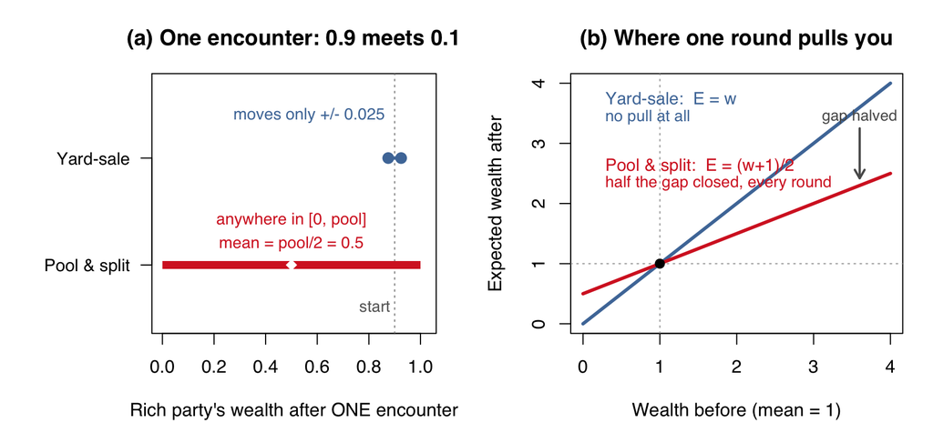

```r
ACC <- "#D62728"; BLU <- "#4E79A7"
par(mfrow = c(1,2), mar = c(4.6,7.0,3.4,1.4), family = "sans", cex.lab = 1.02)
## (a) One and the same encounter: where each rule can send the rich party.
.rc_rich <- 0.9; .rc_poor <- 0.1; .rc_beta <- 0.25
.rc_stake <- .rc_beta*min(.rc_rich, .rc_poor)
reg("rule_stake", .rc_stake, "analytic", "§5.2 rule_contrast_fig", "single yard-sale stake (β=0.25, rich 0.9 meets poor 0.1)")
reg("rule_pull", 0.5, "analytic", "§5.2 rule_contrast_fig", "fraction of the deviation retained each round under pool and split")
plot(NA, xlim = c(0,1.02), ylim = c(0.45,2.7), yaxt = "n",
     xlab = "Rich party's wealth after ONE encounter", ylab = "",
     main = "(a) One encounter: 0.9 meets 0.1")
axis(2, at = c(2,1), labels = c("Yard-sale","Pool & split"), las = 1, cex.axis = 0.95)
abline(v = .rc_rich, lty = 3, col = "gray55")
segments(.rc_rich-.rc_stake, 2, .rc_rich+.rc_stake, 2, col = BLU, lwd = 3)
points(c(.rc_rich-.rc_stake, .rc_rich+.rc_stake), c(2,2), pch = 19, col = BLU, cex = 1.3)
text(.rc_rich-.rc_stake, 2.40, sprintf("moves only +/- %.3f", .rc_stake),
     col = BLU, cex = 0.90, pos = 2, offset = 0.15)
segments(0, 1, 1, 1, col = ACC, lwd = 7, lend = 1)
points(0.5, 1, pch = 18, col = "white", cex = 1.4)
text(0.5, 1.42, "anywhere in [0, pool]", col = ACC, cex = 0.90)
text(0.5, 1.20, "mean = pool/2 = 0.5", col = ACC, cex = 0.90)
text(.rc_rich, 0.60, "start", col = "gray40", cex = 0.88, pos = 2, offset = 0.2)
## (b) Expectation after one round: yard-sale lies on the 45-degree line; pool and split halves the deviation.
par(mar = c(4.6,4.8,3.4,1.4))
.rc_w <- seq(0, 4, length.out = 200)
plot(.rc_w, .rc_w, type = "l", lwd = 3, col = BLU, xlab = "Wealth before (mean = 1)",
     ylab = "Expected wealth after", main = "(b) Where one round pulls you")
lines(.rc_w, (.rc_w+1)/2, lwd = 3, col = ACC)
abline(h = 1, v = 1, lty = 3, col = "gray65"); points(1, 1, pch = 19, cex = 1.1)
text(0.15, 3.72, "Yard-sale:  E = w", col = BLU, cex = 0.95, pos = 4)
text(0.15, 3.44, "no pull at all", col = BLU, cex = 0.88, pos = 4)
text(0.15, 2.62, "Pool & split:  E = (w+1)/2", col = ACC, cex = 0.95, pos = 4)
text(0.15, 2.34, "half the gap closed, every round", col = ACC, cex = 0.88, pos = 4)
arrows(3.6, 3.25, 3.6, 2.42, length = 0.09, lwd = 2, col = "gray35")
text(3.6, 3.45, "gap halved", col = "gray35", cex = 0.85)
```

```r
## Self-check: the two expectation lines are the two expressions in the table.
stopifnot(abs((0.5*(3+1)) - 2) < 1e-12, abs(.rc_stake - 0.025) < 1e-12)
```

Left panel: looking at a single encounter, pool and split is in fact far rougher. In yard-sale the rich party moves by only 0.025; pool and split can knock him from 0.9 all the way to near 0, or let him swallow the whole pool.

The right panel is the heart of it, and it settles at once why pool and split does not necessarily end with one winner. Every yard-sale transaction is a fair bet, so expected wealth after the trade equals wealth before it—that line is the 45-degree line, and nothing pulls a person who has drifted from the mean back toward it. Wealth therefore performs an unbiased random walk. But it does not actually hit zero in finite time—a loser keeps at least a factor $(1-\beta)$, so no one ever “hits 0”; only in the infinite-time limit does everyone except the randomly produced winner tend to zero. Pool and split is not a bet: it reshuffles the pair’s holdings, the expectation becomes $(w+1)/2$, and the part above the mean is cut in half every round. That is a real restoring force.

So the rule in this chapter is “mild” not because each transaction is gentler—quite the opposite—but because every round it flattens the gaps that have already opened.

So within a single chapter there are two opposing forces: pool and split halves the gap, and random returns let the lucky multiply faster and pull the gap open again. Which one wins depends on $\sigma$—and the “phase transition” is exactly the point where the advantage changes sides.

One point that tends to jar deserves saying outright: Chapter 3 says the equilibrium is an exponential distribution, while this chapter talks about power-law tails throughout, and the two do not conflict—they belong to two models. The latter is what the former looks like once multiplicative returns are installed. And a tidier fact will appear shortly: turn the knob to zero and this chapter’s formulas retreat exactly to the exponential distribution, so the Chapter 3 baseline sits at the starting point of this chapter’s curve.

```r
## Run each setting once; both the mean and the sd come from the same batch—previously M and S each ran their own, doubling the work for nothing
RAW <- lapply(sigs, function(sg) sapply(1:SC_K, function(sd) one(sg, sd)))
M <- sapply(RAW, function(A) rowMeans(A))
S <- sapply(RAW, function(A) apply(A, 1, sd))
reg("capital_06", M["gini", which(sigs == 0.6)], "mean", "§5.2 collapse_scan", sprintf("mean over %d seeds", SC_K))
reg("capital_12", M["gini", which(sigs == 1.2)], "mean", "§5.2 collapse_scan", sprintf("mean over %d seeds", SC_K))
```

## 5.3 The First and Third Transitions: One Curve Crossing 2 and 1

The answer said the first transition comes in two steps, and that the third coincides with the boundary for the mean. This section explains why.

Start by nailing down the division of labor between this chapter and §3.5, since both are talking about power laws. The identity in §3.5 says what a power law looks like; it does not say what fixes the tail exponent $\alpha$. The Fokker–Planck equation in §2.7 fixes one: set drift and diffusion both proportional ($A=ar$, $B=br^2$), and the tail exponent of the stationary solution is $\alpha=1+a/b$ (Ludwig and Yakovenko 2022), while $a,b>0$ means it is always greater than 1. The boundary this chapter is after lies exactly where $\alpha_2$ crosses 2 and then 1, a region that route can never reach. So this section is not a restatement of what came before: it enters a different interval, and it gets there from a conserving exchange rule, with no restoring term added.

Take a quick look at a simulation to see what actually happens when $\sigma$ is turned up. The three curves below come from the same rule with only $\sigma$ changed; the vertical axis is “the fraction of people richer than this much wealth,” on log-log axes.

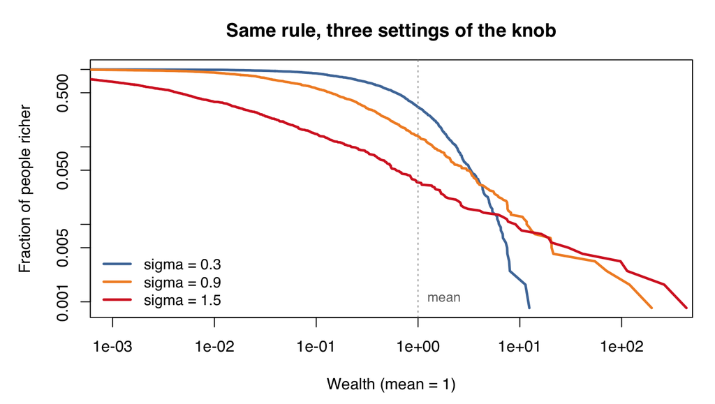

```r
## The same kernel as one() in collapse_scan, except that the final wealth vector is kept whole for plotting.
.ti_run <- function(sig, seed = 1, N = CH5_N, rounds = CH5_R)
  sort(one_w(sig, seed, N, rounds), decreasing = TRUE)
.ti_sg <- c(0.3, 0.9, 1.5); .ti_col <- c("#4E79A7", "#F28E2B", "#D62728")
.ti_w <- lapply(.ti_sg, .ti_run)
for (k in seq_along(.ti_sg))
  reg(paste0("tail_max_", k), max(.ti_w[[k]]), "point",
      "tail_intuition", sprintf("sigma=%.1f richest person in a single realization (mean=1)", .ti_sg[k]))
par(mar = c(4.6,4.8,3.2,1.2), family = "sans")
plot(NA, xlim = c(1e-3, 3e2), ylim = c(1/1200, 1), log = "xy",
     xlab = "Wealth (mean = 1)", ylab = "Fraction of people richer",
     main = "Same rule, three settings of the knob")
for (k in seq_along(.ti_sg))
  lines(.ti_w[[k]], seq_along(.ti_w[[k]])/length(.ti_w[[k]]), col = .ti_col[k], lwd = 2.6)
abline(v = 1, lty = 3, col = "gray60")
text(1, 1/900, "mean", col = "gray45", cex = 0.85, pos = 4)
legend("bottomleft", sprintf("sigma = %.1f", .ti_sg), col = .ti_col, lwd = 2.6,
       bty = "n", cex = 0.95)
```

It is plain to see: the larger $\sigma$ is, the fatter the tail. The richest person rises from 12 times the mean to 197 times and then to 433 times; on log-log paper each curve also comes closer to a straight line, which is to say closer to a power law.

But the simulation stops there. It shows that the tail gets heavier, yet cannot answer the question this chapter really asks: at which $\sigma$ the qualitative change actually happens. The eye cannot tell 0.9 from 1.0 in any essential way; and reading the exponent off a fitted line on such a plot runs into a further problem—the slope measured at finite population and finite rounds is not the same object as the asymptotic tail exponent at all (Analytic Curves Beside Finite Simulations sets out the gap between them).

Fortunately this model does not have to be estimated. Trace a person’s wealth back to its sources and you get a binary family tree; with enough people the branches almost never collide, so the whole thing becomes a standard object with theorems ready to hand—a **smoothing transform**. The tail can therefore be solved for directly. How to solve it is in the collapsible block below; first, the conclusion.

The conclusion is a curve. Write the tail exponent of the fixed point as $\alpha_2(\sigma)$, the exponent in $P(X>x)\sim Cx^{-\alpha_2}$. It is pinned down by a one-dimensional equation—note that this equation always has the solution $\alpha=1$ (the mean is nailed to one by normalization), and $\alpha_2$ is its other positive root; at $\sigma=1$ the two roots merge, and continuity assigns the value 1:

$$\boxed{\log\frac{\alpha_2+1}{2}
=\frac{\sigma^2}{2}\alpha_2(\alpha_2-1)}.$$

It is not a parameter backed out of the Gini, nor a slope from a regression on the simulated upper tail; finding its value takes only a one-dimensional root search.

The two boundaries are one curve crossing two integers. How heavy the tail is decides which moments are still alive: once $\alpha_2$ falls below 2 the variance no longer exists; below 1 even the mean does not. So no two theories are needed—a single $\alpha_2(\sigma)$ passing through 2 and then 1 is both boundaries.

The two boundaries sit at $\sigma=\sqrt{\ln(3/2)}\approx0.63676$ and $\sigma=1$ respectively. The tail exponent at the first is 2; the second is where the two roots merge. The variance loses finiteness first, and then the fixed point with mean one ceases to exist as well.

There is also a tidy closing: turn the knob back to zero and the curve starts exactly on the baseline of the first three chapters. At $\sigma=0$ the recursion degenerates to $X\overset d=U(X_1+X_2)$, and $\mathrm{Exp}(1)$ is its exact fixed point (two lines of verification just below). The exponential distribution, Gini 0.5—the baseline of Chapters 2 through 4—is picked up here by an identity. Different exchange rules can share that baseline; adding return fluctuations is what leaves it along the $\sigma$ axis.

One honest qualification at the end. The curve above is a reasonable candidate for the tail exponent: it says where the threshold of moment divergence lies, but that a tail $Cx^{-\alpha_2}$ really sits at the threshold needs a theorem, and the three parameter intervals do not even use the same theorem. The collapsible block below fills in the cells $0<\sigma<1$ and $\sigma>1$; the existence of the $\sigma=1$ cell is not supplied in this essay.

The first transition: the collapse of description. For this chapter’s nonzero fixed point, the variance is infinite when $\alpha_2\le2$ and the mean is infinite when $\alpha_2\le1$. The summary statistic loses finiteness first, which damages the descriptive tool; the sample mean in a finite simulation is always normalized, so this divergence of integrals must not be read as something the simulation directly observed.

The third transition: collective exit. On the $\sigma\ge1$ side, the population fraction needed to hold a fixed wealth share tends to zero—the tiny group holding half the wealth keeps getting smaller.

Read that sentence in its own terms: it says weak condensation, not the stronger claim that a finite number of people each hold a macroscopic share. The two are not equivalent, and this chapter claims only the first.

There is one more consequence that can be computed exactly: for $\sigma\ge1$ the Gini sequence tends to 1. Note that this is the limit of the Gini sequence, not the Gini of the limiting distribution—the latter has mean zero, and its Gini is not defined at all.

**Details: how weak and strong condensation differ, and the proof that the Gini tends to 1 (skippable)**

The third transition: collective exit. On the $\sigma\ge1$ side of this chapter’s tree limit, the typical individual $X_t\to0$ while the mean stays at one. For any threshold $a>0$, the wealth below it $E[X_t\mathbf1_{X_t\le a}]\to0$; the population fraction above it $P(X_t>a)\to0$ while holding essentially all the wealth. The population fraction needed to hold a fixed wealth share therefore tends to zero. This is weak condensation obtained in the order population first, time second.

Strong condensation asks for something else, and first needs a ruler for concentration. Let $s_i$ be person $i$’s share of total wealth, and define the inverse participation ratio $Y_2=\sum_i s_i^2$: it equals $1/N$ when everyone has equal shares (small), and 1 when one person takes everything, so whether it tends to zero is exactly what separates the two kinds of concentration. Strong condensation requires $Y_2\nrightarrow0$, meaning a finite number of individuals each hold a macroscopic share. The two are not equivalent: the richest $\sqrt N$ people each hold $1/\sqrt N$ of total wealth, so the population fraction tends to zero (weak condensation holds), while $Y_2=1/\sqrt N$ also tends to zero (strong condensation fails). This chapter does not prove strong condensation for the finite-population steady state.

There is one more consequence that can be computed exactly. For independent $X_t,\widetilde X_t$ with mean one,

$$G_t=\frac{E|X_t-\widetilde X_t|}{2}
=1-E\min(X_t,\widetilde X_t)
=1-\int_0^\infty P(X_t>x)^2\,dx.$$

For $\sigma\ge1$ the integrand tends to zero pointwise, while Markov’s inequality gives the integrable bound $P(X_t>x)^2\le\min(1,x^{-2})$. By dominated convergence,

$$\boxed{G_t\longrightarrow1\quad(\sigma\ge1).}$$

This is the limit of the Gini sequence, not the Gini of $\delta_0$; the latter has mean zero, and its Gini is undefined.

**Details: why pool-and-split does not flatten everything in one round**

Given the shares $\mathbf s$ before the split, after random pairing and splitting at a uniformly random fraction,

$$E[Y_2^{\rm after}\mid\mathbf
s]=\frac23\left[Y_2+\frac{1-Y_2}{N-1}\right].$$

Here $E[U^2+(1-U)^2]=2/3$, while the cross term from random pairing has expectation $(1-Y_2)/(N-1)$. Existing macroscopic concentration is multiplied by roughly $2/3$; it is not pressed straight down to $O(1/N)$: a fortune is split with one partner, nowhere near shared with everyone.

With the population set to 400, the calculation starts from $Y_2=0.2506$; the mean over replications after splitting is 0.1680 (standard error 0.0006), and the analytic conditional expectation is 0.1683. If each group of $k$ people pools and splits evenly, then $m_k(q)=k^{1-q}ER^q$, $m_k'(1)=\sigma^2/2-\log k$, and the boundary becomes $\sigma_c(k)=\sqrt{2\log k}$. An even split between two raises the boundary to 1.1774.

Neither boundary actually has to touch the tail; each takes one line. The variance boundary is settled by comparing a second-moment amplification factor with 1, and the mean boundary follows directly from the martingale criterion. What really needs the machinery below is the shape of the nonzero fixed point’s tail—a different question.

And with the knob turned back to zero, the machinery connects exactly to the first three chapters: at $\sigma=0$ the exponential distribution is an exact fixed point, with Gini exactly 0.5, no second root, and hence no power-law tail.

**Details: how each boundary takes one line, and the check at the σ=0 end (skippable)**

Start with the variance boundary, since it can be computed from the second moment alone without touching the tail. Write $M_{2,t}=EX_t^2$, where $X_t$ is the wealth of a randomly tagged person after the population limit has been taken (not the normalized sample second moment of a finite simulation—at $N=2$ the latter is always $4/3$, independent of $\sigma$). Starting from equality, with mean one at every step, it satisfies a one-line recursion:

$$M_{2,t+1}=\tfrac23e^{\sigma^2}\,M_{2,t}+\tfrac23.$$

The amplification factor is $\tfrac23e^{\sigma^2}$ (the constant term $2/3$ comes from the cross term of the two paths and plays no part in the amplification). If the factor is below 1, the second moment converges to $2/(3-2e^{\sigma^2})$; above 1 it diverges exponentially; exactly at 1, $M_{2,t}=1+\tfrac23t$, a linear divergence—so at the boundary itself the variance is already gone. The fate of the variance is thus decided by this single factor against 1, and solving $\tfrac23e^{\sigma^2}=1$ gives exactly $\sigma=\sqrt{\ln(3/2)}\approx0.63676$—the variance boundary on the answer figure.

The mean boundary does not need the tail either: it follows directly from the martingale criterion ($m'(1)=(\sigma^2-1)/2$ changes sign). What really needs the machinery below is the shape of the nonzero fixed point’s tail—a different question.

The $\sigma=0$ end also takes one line, and it connects exactly to the first three chapters. Turn off return fluctuations and the recursion reduces to $X\overset d=U(X_1+X_2)$. (Here $U\sim\mathrm{Unif}(0,1)$ is the split fraction of that cut, independent of the two fortunes.) Check it with the Laplace transform—compute $E[e^{-sX}]$ for each $s\ge0$; the resulting function determines the distribution of a nonnegative variable uniquely, so the same function before and after means the same distribution. If two fortunes are independent $\mathrm{Exp}(1)$, their sum is $\Gamma(2,1)$, and after one random cut

$$E\bigl[e^{-sU(X_1+X_2)}\bigr]=\int_0^1(1+su)^{-2}\,\mathrm
du=\frac1{1+s},$$

The right side is still the transform of $\mathrm{Exp}(1)$. The exponential distribution is an exact fixed point, with Gini exactly 0.5. And at $\sigma=0$ the weight function in the machinery below degenerates to $2/(q+1)$, which has only the root $q=1$ on $q>0$—no second root, and hence no power-law tail; an exponential tail is precisely the $\alpha_2=\infty$ end.

**Details: how the tail-exponent machinery is built (the model’s foundation; skippable)**

Step one: see clearly where one person’s wealth comes from. Pick anyone and ask where the wealth in their hands right now originated. In the previous round they paired with someone, the two fortunes were pooled and cut at random, and they took one part; each of those two fortunes in turn came from a pairing in the round before. Looking back $t$ rounds this way, their wealth is what you get by passing the fortunes of $2^t$ “ancestors” through returns and splits and gathering them into one person—a binary family tree.

The key simplification: when the population is large enough and the number of rounds looked back is fixed, the branches of this tree almost never collide (choosing $2^t$ ancestors out of $N$ people, the probability of a repeat is $O(4^t/N)$). If the branches do not collide, the two sides’ origins are unrelated, hence independent. This step is the foundation of the whole chapter, and the collapsible block at the end of this section will give it a dedicated account.

With independence in hand, tag a recipient at random; their wealth satisfies

$$X_{t+1}\overset
d=UR_1X_t^{(1)}+UR_2X_t^{(2)},\qquad
U\sim\mathrm{Unif}(0,1).$$

How to read it: two independent fortunes from the previous round are each multiplied by their own random return, added, and then multiplied by the split fraction $U$. The other recipient takes the $1-U$ part; since $1-U$ has the same distribution as $U$, random tagging gives the same equation. Write $A_1=UR_1$ and $A_2=UR_2$—they share the same $U$ and are therefore correlated; the independence that matters is that the coefficient vectors at different vertices of the tree are independent of one another and of descendant wealth.

A recursion of this weighted-sum-then-iterate kind is called a **smoothing transform**: it maps one wealth distribution to another, and a distribution that maps to itself is a **fixed point**—note that being a fixed point and being reachable by iterating from some initial distribution are two different things, and that distinction will be needed shortly.

Step two: replace the question of how heavy the tail is with one that is easier to compute. Tail weight is usually described by which moments are still finite: a variance exists when the second moment is finite, a mean when the first is. So instead of staring at the distribution, ask—

> Pass the $q$th power of wealth back one layer along this tree: on average, is it amplified or damped?

The one-layer answer depends only on the coefficients:

$$m(q)=E\bigl(A_1^{\,q}+A_2^{\,q}\bigr)=\frac{2}{q+1}\,e^{\sigma^2q(q-1)/2}.$$

(The $2/(q+1)$ comes from $EU^q$ and the two branches; the exponential factor comes from the $q$th moment of the lognormal return.) If $m(q)>1$ it grows a little with each layer, if $m(q)<1$ it shrinks a little, and $m(q)=1$ is exactly break-even.

Step three: say the same thing for general $q$. The break-even values of $q$ are the tail’s critical exponents. One of them is known already: the mean is nailed to 1 by normalization, so the first moment must break even, $m(1)=1$ regardless of $\sigma$—this permanent root tells us nothing. The informative one is the other root: if $m(\alpha)=1$ with $\alpha\ne1$, then the $\alpha$th moment sits exactly on the boundary between convergence and divergence, which is the signature of a Pareto tail (moments finite for $q<\alpha$, divergent for $q>\alpha$). Write it $\alpha_2(\sigma)$; rearranging gives the boxed equation in the text.

Why there are exactly these two crossings.

$$\frac{d}{dq}\log
m(q)=-\frac1{q+1}+\frac{\sigma^2}{2}(2q-1),
\qquad \frac{d^2}{dq^2}\log
m(q)=\frac1{(q+1)^2}+\sigma^2>0.$$

Strict convexity bounds the number of roots; $m(0)=2$, $m'(1)=(\sigma^2-1)/2$, and the behavior at infinity give existence.

| Parameter | Positive roots of m(q) = 1 | Second-root branch |
| --- | --- | --- |
| σ = 0 | only q = 1 | none; by plotting convention α₂(0) = ∞ |
| 0 < σ < 1 | q = 1, plus another q > 1 | α₂ > 1 |
| σ = 1 | only q = 1 (double root) | continuation α₂ = 1 |
| σ > 1 | another 0 < q < 1, plus q = 1 | 0 < α₂ < 1 |

When finding the root, factor out the permanent root algebraically and use

$$h_\sigma(q)=\frac{\log m(q)}{q-1}
=\frac{\sigma^2q}{2}-\frac{\log((q+1)/2)}{q-1},
\qquad h_\sigma(1)=\frac{\sigma^2-1}{2}$$

to track the branch. Strict convexity makes the slope of this secant strictly increasing in $q$; $h_\sigma(0)=-\log2$, while $h_\sigma(q)\to\infty$ for $\sigma>0$, so it has exactly one positive root. The divergence of the second root as $\sigma\downarrow0$ is a genuine mathematical limit; only writing $\alpha_2(0)=\infty$ at the endpoint is a plotting convention.

Moment divergence in the infinite-population chain and the sample variance of a finite sample are two different things: a nonnegative sample normalized to mean one satisfies $w_i\le N$, and R’s `var()` uses $N-1$ in the denominator, so its upper bound is $N$.

**Details: why this calculation is allowed—from finite population to the tree, and then to long time**

The previous section computed the conclusion but left two debts unpaid.

The first debt: that binary tree is the ideal picture for a large enough population. The actual simulation has only $N=$ 1200 people, and family lines must eventually collide—what licenses using the tree’s answer to speak about a finite population? The second debt: $m(q)$ describes one layer of transmission, while a fixed point is what remains after infinitely many layers. From “shrinks a little each layer” to “where it finally converges” there is still a theorem missing. The two debts must be paid in a fixed order, and the order cannot be reversed:

$$\lim_{t\to\infty}\
\lim_{N\to\infty}$$

Fix the number of rounds and let the population go to infinity first (paying the first debt), then let the rounds go to infinity (paying the second). Why the order matters: only when the population goes to infinity first is the family tree clean; reverse it and let time go to infinity first, and family lines in a finite population have long since collided, so the tree picture does not hold at all. What this chapter proves is the conclusion under this order, not under any other—a point that will come up again, because it is the largest gap in the chapter.

Step one: fix the rounds and let the population go to infinity. Two things need doing—show that the normalization step does not interfere (dividing by the current mean is a global operation that ties everyone together by construction, while the tree picture requires them to be independent), and show that the family lines of the few tagged people really do not collide. Both can be done:

The fixed-time proposition and normalization. Let $V^N_t$ be the process without normalization under the same shocks and the same pairings, with initial values all one, and with the deterministic drift common to everyone removed. Because pool-and-split is a homogeneous map, path by path

$$w^N_{i,t}=\frac{V^N_{i,t}}{\bar
V^N_t}.$$
Pool-and-split conserves the total, and $ER=1$, so $\bar V^N_t$ is a martingale with mean one, and

$$\operatorname{Var}(\bar V^N_{t+1}-\bar
V^N_t\mid V^N_t)
=\frac{e^{\sigma^2}-1}{N^2}\sum_i(V^N_{i,t})^2.$$
Write $Q_t=N^{-1}\sum_i(V^N_{i,t})^2$. From the second moment of the split fraction and $(a+b)^2\le2(a^2+b^2)$,

$$EQ_{t+1}\le\frac43e^{\sigma^2}EQ_t.$$
Hence for any fixed $t$

$$E(\bar
V^N_t-1)^2\le\frac{e^{\sigma^2}-1}{N}
\sum_{j<t}\left(\frac43e^{\sigma^2}\right)^j\longrightarrow0.$$
The probability that the backward lineages of finitely many tagged individuals collide is $O(4^t/N)$. On a tree with no collisions, the leaf initial values are fixed and the shocks and splits at the vertices are independent, so the process couples to an independent binary tree. Combined with the $L^2$ convergence of the mean, this gives propagation of chaos at fixed time and lets normalization pass through the limit. The moment bound also gives tail control for the empirical first moment at fixed time. Let $\phi_t(s)=E[e^{-sX_t}]$; the exact discrete recursion for simultaneous updating is

$$\boxed{\phi_{t+1}(s)=\int_0^1\left[E_R\phi_t(suR)\right]^2\,du},
\qquad\phi_0(s)=e^{-s}.$$
The continuous-time equation $\partial_t\phi=T\phi-\phi$ belongs to a different update timing; it shares the stationary equation but cannot replace the proof here for simultaneous updating. This proposition covers fixed time only. Let $s_i=w_i/N$ and $Y_2=\sum_i s_i^2$; the denominator of the next normalization, $D=\sum_i s_iR_i$, satisfies

$$E[D\mid
w]=1,\qquad\operatorname{Var}(D\mid w)=(e^{\sigma^2}-1)Y_2.$$

As long as a macroscopic share remains, the denominator’s fluctuations do not vanish. Cancelling the common drift path by path does not make normalization harmless over long times; the bound above grows with time, so it cannot show that a finite simulation has reached steady state, nor does it permit exchanging the limits.